# Ch. 8 Laminar Flow — fluidpy

← All chapters🎮 All explainers

← PreviousNext →

[▶ Open in Colab](https://colab.research.google.com/github/shammun/fluidpy/blob/main/notebooks/ch08_laminar_flow_colab.ipynb) ↓ Download .ipynb [View on GitHub](https://github.com/shammun/fluidpy/blob/main/notebooks/ch08_laminar_flow.ipynb)

## Interactive explainers in this chapter

🎮 1**When does fluid flow backwards in a channel?**A moving wall drags, a pressure gradient pushes: the profile is a straight line plus a parabola, and the floor layer reverses once dp/dx exceeds 2μU/h².🎮 2**Why can a thin film ignore inertia?**Scale the gap equations with two lengths and every term becomes a bar: inertia is weighed by the reduced Reynolds number, the pressure and the cross-gap friction stay, and across the gap only the pressure is left.🎮 3**How does a film thinner than a hair carry a load?**The same flux must pass a narrowing gap, so pressure rises inside: drag the taper and the sliding direction and watch the pressure hump, the gap profiles and the load respond, and see the printed pressure formula fail the pressure equation.🎮 4**Why does a honey drop spread like *t*<sup>1/5</sup>?**A thin viscous layer spreads under its own weight by a diffusion that chokes itself as it thins; every initial shape ends on one dome whose front moves as *t*<sup>1/5</sup>.🎮 5**How can profiles at all times be one curve?**A plate starts suddenly; momentum diffuses a distance of order the square root of nu t; plot against y over that length and every profile, for any time, speed and viscosity, collapses onto one complementary-error-function curve - until a stopping time or a second wall imposes a scale.🎮 6**Where do similarity exponents come from?**Guess a profile that decays like t^-n and widens like t^m: the rescaled profiles collapse only at the right n and m, fixed by matching the powers of t in the equation and one conserved quantity.🎮 7**How deep does a shaking plate reach?**A plate oscillating in its own plane drags a thin layer of fluid: each layer repeats the wall's motion, shrunk by exp(-y/delta) and delayed by y/delta radians, with delta = sqrt(2 nu/omega) - a wave-like pattern made only of diffusion.🎮 8**What does creeping flow round a sphere look like?**Stokes' flow past a sphere is fore-aft symmetric and its disturbance decays only like a/r, so it is felt tens of radii away; there inertia catches up with friction, and Oseen's correction sweeps the disturbance into a wake. Compare with ideal flow.🎮 9**Where does 6*π**μ**a**U* come from?**Sweep round a creeping sphere: the pressure and friction tractions add to one uniform push, collecting 2πμaU and 4πμaU; then change the particle size and watch the fall speed grow as a² until Re is no longer small.

# Chapter 8 — Laminar Flow

*Fluid Mechanics, 5th edition — Pijush K. Kundu, Ira M. Cohen, David R. Dowling (2012).* This notebook teaches every new idea of the chapter with plain words, step-by-step mathematics, small worked examples, tested Python from the `fluidpy` package, figures, animations and interactive explainers. It does not reproduce the book's text or figures; every equation is shown in full together with its number, so you can follow along in your copy.

**The big idea in one paragraph**

Pour honey, drag a spoon through syrup, watch a cloud droplet drift down at about a centimetre a second: when viscosity matters everywhere, the Navier–Stokes equations can often be solved exactly. The trick is always the same — a symmetry or a thin geometry kills the nonlinear term, and what is left is a balance between pressure (or wall motion) and viscous friction. This chapter solves that balance between plates, in pipes and between rotating cylinders; in the thin film under a bearing and under a spreading drop; above a plate that starts or shakes, where momentum *diffuses* a distance $\sqrt{\nu t}$ — the scale behind every boundary layer, every Ekman layer and every spin-up time of the ocean and atmosphere; and round a sphere so small that inertia vanishes, which gives Stokes' drag $D=6\pi\mu aU$ *(Eq. 8.51)* and the fall speed of cloud droplets, aerosols and silt.

**Road map** — the new ideas of this chapter, in the order they build on each other:

1. §8.1 laminar vs turbulent flow and ν as a momentum diffusivity, $\mathrm{Re}=Ud/\nu\sim2000$–$3000$ (C01)
2. §8.2 plane Couette–Poiseuille flow $u(y)=\frac Uh\,y-\frac1{2\mu}\frac{dp}{dx}\,y(h-y)$ *(8.5)* and backflow (C02); Poiseuille pipe flow, $Q\propto a^4$ (C03); circular Couette flow $u_\varphi=AR+B/R$ *(8.9)* and its two limits (C04)
3. §8.3 the lubrication approximation, weighed by $\varepsilon^2\mathrm{Re}_L$ (C05); the lubrication profile and the Reynolds equation (C06); the slider bearing (C07); the thin-film (viscous gravity current) equation (C08)
4. §8.4 Stokes' first problem $\frac uU=1-\mathrm{erf}\big(\frac{y}{2\sqrt{\nu t}}\big)$ *(8.30)* and similarity (C09); the similarity ansatz and its exponents (C10)
5. §8.5 Stokes' second problem: the oscillating plate and its layer of depth $\sqrt{2\nu/\omega}$ (C11)
6. §8.6 creeping flow: the Stokes equations $\nabla p=\mu\nabla^2\mathbf u$ *(8.43)* (C12); Stokes' flow round a sphere (C13); Stokes drag $D=6\pi\mu aU$ *(8.51)* and settling (C14); where Stokes fails and Oseen's fix (C15)
7. §8.7 final remarks: where exact solutions stop

**What you should already know** (each is recapped where it is used):

- Navier–Stokes and the no-slip condition (Ch. 4 §4.5–4.10)
- Reynolds number and scaling (Ch. 4 §4.11)
- viscosity, ν = μ/ρ, plane Couette start-up (Ch. 1 §1.5)
- dimensional analysis (Ch. 1 §1.11)
- vorticity diffusion, the ideal vortex, solid-body rotation (Ch. 5 §5.1–5.4)
- the Gaussian vortex (Ch. 3 §3.5)
- the Stokes stream function and the ideal-flow sphere (Ch. 6 §6.8)
- complex amplitudes (Ch. 7 §7.7)

## 🎮 Interactive explainers in this chapter

| # | Explainer | What it makes clear |
| --- | --- | --- |
| 1 | **When does fluid flow backwards in a channel?** | C02: a line plus a parabola — wall drag and pressure add, and backflow opens once dp/dx > 2μU/h² |
| 2 | **Why can a thin film ignore inertia?** | C05: term bars of the scaled momentum equations reorder with ε and Re_L; only ε²Re_L must be small |
| 3 | **How does a film thinner than a hair carry a load?** | C06 C07: the same flux through a narrowing gap needs a pressure hump — and it turns into suction if the pad slides backwards |
| 4 | **Why does a honey drop spread like t^(1/5)?** | C08: a nonlinear diffusion that chokes itself; every initial shape ends on one profile |
| 5 | **How can profiles at all times be one curve?** | C09: momentum diffuses √(νt) — plot against y/√(νt) and every profile collapses |
| 6 | **Where do similarity exponents come from?** | C10: guess At^(−n)F(ξ/δ); the equation and one conserved quantity fix n and δ(t) |
| 7 | **How deep does a shaking plate reach?** | C11: a 'wave' made only of diffusion — each layer lags by y/δ and shrinks as e^(−y/δ), δ = √(2ν/ω) |
| 8 | **What does creeping flow round a sphere look like?** | C13 C15: fore–aft symmetric, reaching tens of radii, until inertia returns far away: Oseen's wake |
| 9 | **Where does 6πμaU come from?** | C14: one third pressure, two thirds friction; drag ∝ U makes a droplet's fall speed grow as a² |

Each one opens right where its idea is taught and fills the window (no scrolling). Start with the **Walkthrough**, then **Explore** with the sliders and presets, read **Explain** (every number worked out with your settings, and what it means), step through the **Derivation** where there is one, read the **Equations** and the **Code**, and finish with **Check yourself**. On the web page they are full-window; in Colab and Jupyter they appear in the cell output (use ⤢ *Full screen* or *Open in new tab* for more room).

## ⚙️ Setup — run this cell first

It works in three places without changes:

- **Google Colab** — clones the public repository into `/content/fluidpy` (the `fluidpy` package, its tests and the interactive explainers) and installs the one package Colab lacks (`pint`). No GPU is needed.
- **Jupyter / VS Code on your computer** — finds the repository root (the folder with `book.yaml`) and imports from it.
- **The published web page** — already executed; nothing to run.

```python
# ── Setup: find (or fetch) the fluidpy repository, then load the house style ─────────────────────────────
import os, sys, subprocess, pathlib                     # standard library only, so this cell never fails on imports

IN_COLAB = "google.colab" in sys.modules                 # True when this notebook runs inside Google Colab
REPO_URL = "https://github.com/shammun/fluidpy.git"               # the public repository with the fluidpy package

if IN_COLAB:
    ROOT = pathlib.Path("/content/fluidpy")              # where the repository is cloned on Colab
    if not ROOT.exists():                                 # first run in this Colab session: clone it
        subprocess.run(["git", "clone", "--depth", "1", REPO_URL, str(ROOT)], check=True)
    else:                                                 # later runs: fetch the newest version
        subprocess.run(["git", "-C", str(ROOT), "pull", "--ff-only", "-q"], check=False)
    subprocess.run([sys.executable, "-m", "pip", "install", "-q", "-r", str(ROOT / "requirements-colab.txt")], check=True)
else:
    ROOT = pathlib.Path.cwd().resolve()                   # start where Jupyter was launched …
    while not (ROOT / "book.yaml").exists() and ROOT != ROOT.parent:
        ROOT = ROOT.parent                                # … and walk up until we find the repository root

os.chdir(ROOT)                                            # relative paths (outputs/, viz/) now resolve from the root
if str(ROOT) not in sys.path:
    sys.path.insert(0, str(ROOT))                         # make `import fluidpy` work

from fluidpy.core.style import setup_notebook            # matplotlib + plotly style shared with the explainers
from fluidpy.core.embed import show_viz                  # shows an interactive explainer in the notebook
from fluidpy.core.anim import show_animation             # plays a matplotlib animation inline
FAST = setup_notebook()                                   # FAST=True (env FLUIDPY_FAST=1) shrinks grids for quick runs
print(f"IN_COLAB = {IN_COLAB} | repository root: {ROOT} | FAST = {FAST}")
```

```
IN_COLAB = False | repository root: C:\Users\sislam27\Work\Climate Dynamics PHD\Fluid Dynamics | FAST = False
```

```python
import numpy as np                                       # arrays and maths (Ch. 1 primer P03)
import sympy as sp                                       # symbolic algebra (Ch. 1 primer P40)
import matplotlib.pyplot as plt                          # static figures (Ch. 1 primer P01)
from scipy import integrate, special, optimize, linalg   # quadrature, erf/erfc, root finding, banded solves
from fluidpy import ch08_laminar_flow as ch08            # the tested chapter-8 module (re-exports the three new toolkits)
from fluidpy.core import laminar as LAM, lubrication as LUB, creeping as CRP, diffusion   # the new toolkits + solvers
from fluidpy import ch01_introduction as ch01            # Ch. 1: property functions, Π groups
from fluidpy import ch03_kinematics as ch03              # Ch. 3: the developing pipe profile
from fluidpy import ch04_conservation_laws as ch04       # Ch. 4: plane Poiseuille, Stokes' first problem (earlier code)
from fluidpy import ch05_vorticity_dynamics as ch05      # Ch. 5: the rotating cylinder, the diffusing vortex sheet
from fluidpy.core import navier_stokes as NS, similarity as SIM, vortices as VX   # Ch. 4–5 tools: NS terms, Re, vortices
from fluidpy.core import potential as PF, curvilinear as CL                       # Ch. 6 potential flows, curvilinear calculus
from fluidpy.core.interact import slider_figure, animate_figure, live   # plotly sliders (P17), time players, widgets (P47)
from fluidpy.core.anim import animate, ffmpeg_path       # matplotlib animations (P16); show_animation came with setup
from fluidpy.core.style import COLORS, savefig           # the house palette and a helper that saves PNGs to outputs/ch08
from tools.convergence import observed_order             # slope of log(error) vs log(step) (P13)
sys.path.insert(0, str(ROOT / "scripts"))                # the chapter's drawing helpers live in scripts/
from ch08_drawings import channel, pad, sphere, profile_arrows   # drawing only: walls, the bearing pad, a sphere, arrows
ffmpeg_path()                                            # find ffmpeg once, for the MP4 animations
MU_W, RHO_W, NU_W = 1.0e-3, 1000.0, 1.0e-6              # water: μ [Pa s], ρ [kg/m³], ν = μ/ρ [m²/s] (our default)
plt.rcParams["contour.negative_linestyle"] = "solid"     # negative ψ levels are streamlines too: draw them solid
import logging                                           # Python's message system (matplotlib reports font fallbacks through it)
logging.getLogger("matplotlib.font_manager").setLevel(logging.ERROR)   # hide harmless "font weight not found" notes


def recolor(fig, colors, dashes=None):                   # give plotly traces the notebook's colours by trace name
    for tr in fig.data:                                  # every trace of every slider step
        if tr.name in colors:                            # a name we assigned a colour to
            tr.line.color = colors[tr.name]              # same colour meaning as in the matplotlib figures
        if dashes and tr.name in dashes:                 # optional dash pattern ("dash", "dot")
            tr.line.dash = dashes[tr.name]
    return fig                                           # the same figure, restyled


def step_titles(fig, titles):                            # give each slider position of a slider_figure its own title
    old = fig.layout.sliders[0].steps                    # the steps slider_figure made (they switch curves on and off)
    fig.layout.sliders[0].steps = [dict(method=s.method, label=s.label, args=[s.args[0], {"title.text": t}])
                                   for s, t in zip(old, titles)]   # same switch + a new title text per step
    fig.layout.title.text = titles[fig.layout.sliders[0].active]   # the title of the step shown first
    return fig                                           # the same figure, now with numbers that follow the slider


print(len([n for n in dir(ch08) if not n.startswith("_")]), "public names in fluidpy.ch08_laminar_flow")
print("ch08.channel_flow is LAM.channel_flow:", ch08.channel_flow is LAM.channel_flow)   # the re-export
```

```
119 public names in fluidpy.ch08_laminar_flow
ch08.channel_flow is LAM.channel_flow: True
```

**What does the code above do?**

1. Numerical, symbolic and plotting libraries (all primed in Ch. 1); from `scipy` we use `integrate` (`quad`, `cumulative_trapezoid`, `solve_bvp`, `solve_ivp`), `special` (`erf`, `erfc` and their inverses), `optimize` (`brentq`, `minimize_scalar`) and `linalg` (`solve_banded`) — each is reminded or primed where it is first used.
2. `ch08` is the chapter module. It **re-exports the three new toolkits** `core.laminar` (exact parallel and unsteady flows), `core.lubrication` (thin gaps and films) and `core.creeping` (low-Reynolds-number flow), plus the diffusion solvers, so `ch08.channel_flow` and `LAM.channel_flow` are the same function (the last line prints `True`). Every function cites its § and equation and is tested in `tests/test_ch08.py`.
3. Earlier chapters' modules are used in the recaps and for parity checks (the Ch. 3 pipe profile, the Ch. 4 Poiseuille and Stokes-problem functions, the Ch. 5 rotating cylinder and vortex sheet, Ch. 6's potential-flow sphere).
4. `scripts/ch08_drawings.py` only draws (channel walls, the pad, a sphere, profile arrows); it computes no physics.
5. `MU_W, RHO_W, NU_W`: water at room temperature, our default fluid (numbers ours, not the book's).
6. `recolor` only restyles plotly figures.

### ⚠️ Conventions in this chapter (read once; each is repeated where it bites)

| Symbol | Meaning here | Before (and where it bites) |
| --- | --- | --- |
| dp/dx | the book's pressure gradient: **favourable < 0** (pressure falls downstream) | Ch. 4's code used G = −dp/dx; new functions take `dpdx` (and accept `G=`) |
| y = 0, y = h | channel walls: y = 0 **fixed**, y = h moving at U | Ch. 1's Couette start-up moved the upper plate too |
| R, r | **R** = cylindrical radius (§8.2), **r** = spherical radius (§8.6) | Ch. 3–6 used r for both |
| θ | in §8.6 measured from the **downstream** axis: rear stagnation point θ = 0, front θ = π | Ch. 6's sphere also had θ from the axis; check the direction |
| ω | **vorticity** in §8.1, §8.4, §8.6 ($\omega_z$, $\omega_\varphi$) but the plate's **frequency** [rad/s] in §8.5 | as in Ch. 7 (frequency) and Ch. 5 (vorticity) |
| η | the **similarity variable** $\eta=y/\sqrt{\nu t}$ *(8.25)*; the book's figures plot $y/(2\sqrt{\nu t})=\eta/2$ | the surface elevation in Ch. 7 |
| ε | the fineness ratio h/L of a thin gap | a density ratio in Ch. 7, the dissipation rate in Ch. 4 |
| Λ | the bearing number $\mu UL/(P_ah^2)$ | new |
| δ₉₉, δ_e, δ(t) | 99 % thickness of Stokes' first problem · e-folding depth of the Stokes layer · the width in a similarity form | three different thicknesses |
| Re | pipe $Ud/\nu$ (diameter, mean speed) · lubrication $\mathrm{Re}_L=\rho UL/\mu$ (passage length) · generic $\rho UL/\mu$ · sphere $\mathrm{Re}=2aU/\nu$ (**diameter**) | the radius-based $\mathrm{Re}_a=\mathrm{Re}/2$ appears in C15 |
| D | an integration constant (C13) **and** the drag (C14) | say which |
| g | `ch08`'s settling and film functions use the SI standard g = 9.80665 m/s² (`G0`) | Ch. 4, 5, 7 used 9.81; the book prints no g-dependent number here |

We compute with the book's conventions and name the other one wherever it differs.

**Colours** (one meaning each, also in the explainers): pressure and the pressure-driven (Poiseuille) part **orange** · viscous friction and the wall-driven (Couette) part **rose** · inertia **teal** · velocity profiles **blue** · vorticity **purple** · backflow and warnings **amber** · rescaled (similarity) curves purple dashed · an analytic ghost grey dashed · numerical dots teal · a printed slip grey dotted, labelled "as printed".

**Book slips we correct in this notebook** (each is explained where it is used):

| The book prints | We use | Where |
| --- | --- | --- |
| §8.1 calls μ "the kinematic viscosity" | μ is the **dynamic** viscosity; ν = μ/ρ is the kinematic one | C01 |
| channel mean velocity written $V=\int_0^hu\,dy$ in the middle expression | $V\equiv Q/h$ (the 1/h is missing; units m²/s ≠ m/s) | C02 (N10) |
| printed (8.13b) $\frac{\partial v}{\partial t}+u\frac{\partial v}{\partial x}+v\frac{\partial v}{\partial y}=-\frac1\rho\frac{\partial p}{\partial x}+\frac\mu\rho\big(\frac{\partial^2v}{\partial x^2}+… | $\frac{\partial v}{\partial t}+u\frac{\partial v}{\partial x}+v\frac{\partial v}{\partial y}=-\frac1\rho\frac{\partial p}{\partial y}+\frac\mu\rho\big(\frac{\partial^2v}{\partial x^2}+\frac{\partial^2… | C05 (N24, D10) |
| printed (8.17a) $0\cong-\frac1\rho\frac{\partial p}{\partial x}+\frac{\partial^2u}{\partial y^2}$ | $0\cong-\frac1\rho\frac{\partial p}{\partial x}+\nu\frac{\partial^2u}{\partial y^2}$ (units) | C05 (D11) |
| "the scaled x-equation can be integrated twice" | it is the simplified lubrication balance $0\cong-\frac1\rho\frac{\partial p}{\partial x}+\nu\frac{\partial^2u}{\partial y^2}$ *(8.17a)* that is integrated | C06 (N33) |
| printed (8.19) $u\cong-\frac{h^2}{2\mu}\frac{\partial p}{\partial x}\frac yh\big(1-\frac yh\big)+U_h\frac yh+U_0$ | $u\cong-\frac{h^2}{2\mu}\frac{\partial p}{\partial x}\frac yh\big(1-\frac yh\big)+U_h\frac yh+U_0\big(1-\frac yh\big)$ (otherwise u(h) = U_h + U₀) | C06 (N34, D12) |
| Example 8.1: intermediate integrals with $(1-\alpha x/L)$; final pressure with the denominator to the **first** power | $(1+\alpha x/L)$; the denominator **squared** | C07 (D14) |
| Example 8.2's lubrication equations without ν and walls at "y = 0, h" | with ν; the gap coordinate is z | C06 (N36) |
| "the final equation of Example 8.2" (in Example 8.7) | Example 8.3 | C10 (N63) |
| $\int_0^\infty\omega\,dy=-U$ | $+U$ (u falls upward, so ω > 0) | C09 (N53) |
| Example 8.5's ±2.76 | ±2.772 (its own width 5.54 is right) | C10 (N59) |
| "substitution of the wall condition into the diffusion equation" | it is the complex trial $u(y,t)=\mathrm{Re}\{e^{i\omega t}f(y)\}$ *(8.35)* that is substituted | C11 (N68) |
| rear pressure minimum +3μU/2a | **−**3μU/2a | C14 (N88, D30) |
| "(9.63)" and "(9.68)" in §8.6 | (8.43), $\nabla p=\mu\nabla^2\mathbf u$ and (8.48), $\psi=Ur^2\sin^2\theta\Big(\frac12-\frac{3a}{4r}+\frac{a^3}{4r^3}\Big)$ | C13 (N93), C15 (N98) |
| Oseen's equation with $+\partial p/\partial x_i$ | $-\partial p/\partial x_i$ | C15 (N95) |
| power into the fluid $(2\pi R_1)\tau_{R\varphi}u_\varphi$ | $-2\pi R_1\sigma_{R\varphi}u_\varphi$ (positive) | C04 (R11) |
| the bearing number Λ "near unity" with p* = p/P_a | Λ ≈ 49 for our film (≈ 10³ for thinner, longer films); the natural scale is μUL/h² | C05 (N31) |

> 🔁 **Tools from earlier chapters used in this one** (one line each where first used; the full primers are in `knowledge/primers.md`): partial derivative (P25), first-order Taylor (P26), definite integral (P27), the linear second-order ODE (P44), separation of variables (P42), chain rule (P49/P91), exponent rules (P43), power laws and log–log plots (P13), limits and orders of smallness (P68), order-of-magnitude scaling (P130), scaled variables and the chain rule (P133), product rule (P38), fundamental theorem of calculus (P84), differentiation under the integral sign (P109), substitution in an integral (P106), erfc (P123), Euler's formula (P45), complex square roots (P159), complex amplitudes (P176), curl of a curl (P122), Schwarz's theorem (P121), surface integrals on a sphere (P163), line integrals (P35), cylindrical and spherical unit vectors (P88), polar coordinates as a moving basis (P105), boundary conditions (P20), `np.linalg.solve` (P57), sympy (P40) and `expand`/`series` (P117), `quad` (P87), `brentq` (P108), `expm1` (P107), `minimize_scalar` (P170), `meshgrid` (P76), contour and streamline plots (P78), finite differences (P21), explicit stepping (P30), the trapezoid rule (P37), `np.random.default_rng` (P10), `animate` (P16), `slider_figure` (P17), `show_viz` (P18), live widgets (P47), `assert np.allclose` (P15). New primers of this chapter: P185–P199.

## 8.1 Introduction

**What is this section about?** Where this chapter lives: flows in which viscosity acts everywhere, not just in thin layers. We meet Reynolds's experiment (smooth versus chaotic flow in a pipe), learn to read the kinematic viscosity ν as a *diffusivity* of momentum and vorticity, and restate the equations and wall conditions every solution in the chapter must satisfy.

> 🔁 **Recap — The Reynolds number as inertia over viscosity** (Ch. 4 §4.11). Scaling the Navier–Stokes equation gives inertia $\sim U^2/L$ and viscous acceleration $\sim\mu U/(\rho L^2)$; their ratio $\frac{U^2/L}{\mu U/\rho L^2}=\frac{\rho UL}{\mu}=\mathrm{Re}$ is the Reynolds number. Earlier chapters dropped viscosity where Re ≫ 1 (ideal flow, Ch. 6); in this chapter viscosity is kept everywhere.

```python
s = ch08.inertia_viscous_scales(0.1, 0.01, NU_W)         # U = 10 cm/s, L = 1 cm, water: the two accelerations [m/s²]
print({k: round(v, 6) for k, v in s.items()})            # inertia U²/L, viscous νU/L², and their ratio
print("Re =", round(SIM.reynolds_number(0.1, 0.01, nu=NU_W), 3))   # Ch. 4's Re = UL/ν — the same ratio
```

```
{'inertia': 1.0, 'viscous': 0.001, 'ratio': 1000.0}
Re = 1000.0
```

> 🔁 **Recap — Vorticity diffuses with ν** (Ch. 5 §5.4). In a plane flow the vorticity equation $\frac{D\boldsymbol\omega}{Dt}=(\boldsymbol\omega\cdot\nabla)\mathbf u+\nu\nabla^2 \boldsymbol\omega$ *(5.13)* loses its stretching term, because $\boldsymbol\omega=\omega_z\mathbf e_z$ and nothing depends on z, so $(\boldsymbol\omega\cdot\nabla)\mathbf u=\omega_z\,\partial\mathbf u/\partial z=0$; what is left is $D\omega_z/Dt=\nu\nabla^2\omega_z$ — the same form as the heat equation. A fluid with larger ν smooths out a vorticity pattern faster.

### 🧩 Laminar vs turbulent flow, and ν as a momentum diffusivity `C01`

*The question:* When does a flow stay smooth — and what does the kinematic viscosity ν actually measure?

*In one line:* $\mathrm{Re}=\frac{Ud}{\nu}\sim2000$–$3000$ separates smooth from chaotic pipe flow, and $\nu=\mu/\rho$ is the diffusivity of momentum: motion spreads a distance $\sqrt{\nu t}$ in a time t.

#### The problem in plain words

Open a tap a little and the stream is glassy; open it fully and it turns frothy. Reynolds put a thread of dye into water flowing through a glass tube and saw the same thing: at low flow the dye stayed a straight thread, at high flow it broke up and filled the tube. Every exact solution in this chapter is of the first, *laminar* kind — so we need to know when it applies, and what sets how fast viscosity spreads the motion.

#### The idea

```
laminar  (Re < 2000):   ─────────────── dye stays a thread; layers slide past each other
turbulent (Re > 3000):  ~~~≈≈≈∿∿∿≈≈~~~ dye fills the tube; eddies mix it
Re = U d / ν   (U = mean speed, d = diameter, ν = μ/ρ)
```

| quantity | water (20 °C) | air (20 °C) |
| --- | --- | --- |
| μ [Pa s] | 1.0 × 10⁻³ | 1.8 × 10⁻⁵ |
| ρ [kg/m³] | 1000 | 1.2 |
| ν = μ/ρ [m²/s] | 1.0 × 10⁻⁶ | 1.5 × 10⁻⁵ |
| time to diffuse 1 cm, L²/ν | 100 s | 6.7 s |

**ν, not μ, says how fast motion spreads** — air is 55 times less viscous than water but spreads momentum 15 times faster. (Rounded textbook values in the table; the code below computes them from Ch. 1's property functions.)

> ⚠️ **Common confusion:** μ (dynamic viscosity, Pa s) is the friction coefficient in $\tau=\mu\,du/dy$; ν = μ/ρ (kinematic viscosity, m²/s) is the diffusivity. The book's §8.1 once calls μ "the kinematic viscosity" — it means the dynamic one.

> 🔁 **Tools from earlier chapters used here** (see `knowledge/primers.md`)
- **dynamic vs kinematic viscosity μ, ν = μ/ρ** — Newton's law $\tau=\mu\,du/dy$ defines μ as the stress per unit shear rate (Ch. 1 P05, stress); dividing by ρ gives ν.

> 📎 **Primer — diffusivity and the diffusion time L²/ν.** `P185` · A diffusivity D (units m²/s) says how fast something spreads by random molecular exchange: in a time t it spreads a distance of order $\sqrt{Dt}$, so crossing a distance L takes about $L^2/D$. Heat has $\kappa=k/\rho C_p$, dye its molecular diffusivity, and momentum has ν. Double the distance and the time quadruples.

```python
L = [0.001, 0.01, 0.1]                   # distances [m]: 1 mm, 1 cm, 10 cm
nu = 1.0e-6                              # water's kinematic viscosity [m²/s]
print([l**2/nu for l in L])              # diffusion times L²/ν [s]: [1.0, 100.0, 10000.0]
```

```
[1.0, 100.00000000000001, 10000.000000000002]
```

📝 **Note.** **N01 [B] · Heat and momentum spread the same way.** The Boussinesq heat equation below, with the thermal diffusivity $\kappa\equiv k/\rho C_p$, has the same form as $\frac{D\mathbf u}{Dt}=-\frac1\rho\nabla p+\nu\nabla^2\mathbf u$ *(8.1)*; both κ and ν are in m²/s, so ν is the *momentum diffusivity*. The analogy is not complete: the pressure gradient in (8.1) also moves momentum around, so velocity is not simply diffused.

$$ \frac{DT}{Dt}=\kappa\nabla^2T \qquad \text{(4.89)} $$

#### 🧮 Derivation — Air diffuses momentum ≈ 15× faster than water: ν = μ/ρ and t ~ L²/ν `D01`

**What we want to show.** Show that the rate at which motion spreads is set by ν = μ/ρ, not μ, and that air — 55 times less viscous than water — spreads momentum about 15 times faster.

**Assumptions.** Room temperature and pressure property values (step 4).

**The plan.**

1. Identify the diffusivity in (8.1), $\frac{D\mathbf u}{Dt}=-\frac1\rho\nabla p+\nu\nabla^2\mathbf u$.
2. Turn a diffusion balance into a time scale.
3. Compare air and water with numbers.

**Tools we use** (each explained before this point): diffusivity and the diffusion time (primer P185) · order-of-magnitude scaling (P130) · ratios.

**We start from**

$$ DT/Dt=\kappa\nabla^2T\ \text{(4.89) and}\ D\mathbf u/Dt=-(1/\rho)\nabla p+\nu\nabla^2\mathbf u\ \text{(8.1)} $$

*In words:* in both, a diffusivity multiplies the Laplacian.

**Step 1 of 5 — Read the Laplacian's coefficient.**

$$ \nu\equiv\frac{\mu}{\rho}\ \ [\mathrm{m^2/s}] $$

- *Why we can do this:* (8.1), $\frac{D\mathbf u}{Dt}=-\frac1\rho\nabla p+\nu\nabla^2\mathbf u$ is the momentum equation divided by ρ; the viscous term μ∇²u becomes (μ/ρ)∇²u, with the units m²/s of a diffusivity like κ.
- *In words:* the diffusivity of momentum is ν, not μ.

**Step 2 of 5 — Balance change against diffusion.**

$$ \frac{U}{t_d}\sim\nu\frac{U}{L^2}\ \Rightarrow\ t_d\sim\frac{L^2}{\nu} $$

- *Why we can do this:* Order-of-magnitude scaling: ∂u/∂t ~ U/t and ∂²u/∂y² ~ U/L²; equating them gives the time diffusion needs to cross a distance L.
- *In words:* spreading over L takes about L²/ν.

**Step 3 of 5 — Write the ratio of the two ν.**

$$ \frac{\nu_{air}}{\nu_{w}}=\frac{\mu_{air}}{\mu_{w}}\cdot\frac{\rho_{w}}{\rho_{air}} $$

- *Why we can do this:* Divide ν = μ/ρ for air by the same for water; the ratio splits into a viscosity ratio and an inverse density ratio.
- *In words:* two effects compete: viscosity and density.

**Step 4 of 5 — Insert room-temperature values.**

$$ \frac{\nu_{air}}{\nu_w}=\frac{1.8\times10^{-5}}{10^{-3}}\cdot\frac{1000}{1.2}= 0.018\times833=15 $$

- *Why we can do this:* μ and ρ at 20 °C (Ch. 1 property functions); air's density is 833 times smaller, which beats its 55 times smaller viscosity.
- *In words:* air's ν is 15 times water's.

**Step 5 of 5 — Compare diffusion times across 1 cm.**

$$ t_w=\frac{10^{-4}}{10^{-6}}=100\ \mathrm s,\ \ t_{air}=\frac{10^{-4}}{1.5\times 10^{-5}}=6.7\ \mathrm s $$

- *Why we can do this:* Use step 2 with L = 1 cm; the ratio of times is the inverse ratio of ν.
- *In words:* momentum crosses a centimetre of air 15 times sooner.

**Result**

$$ \nu=\frac{\mu}{\rho},\qquad t_d\sim\frac{L^2}{\nu},\qquad \frac{\nu_{air}}{\nu_w}\approx15 $$

*In words:* ν sets how fast motion spreads.

**What it means.** "More viscous" and "more diffusive" are different: honey is both, air is little viscous yet quickly diffusive. Every thickness in this chapter grows like √(νt).

**Check it.** Units: (Pa s)/(kg/m³) = (kg/(m s))/(kg/m³) = m²/s ✓; t = m²/(m²/s) = s ✓. The code cell after the tiny example below computes the ratio from Ch. 1's property functions (Sutherland air, IAPWS water) at 20 °C and prints it.

> ⚠️ **Common confusion (traps in `D01`):** Comparing μ instead of ν; forgetting that the density ratio (≈ 830) is larger than the viscosity ratio (≈ 55).

#### ✏️ Tiny example: water in a 1 cm tube at 10 cm/s

1. $\mathrm{Re}=Ud/\nu=0.1\times0.01/10^{-6}=1000$ — below 2000, laminar.
2. Double the speed: Re = 2000, the bottom of the transition band.
3. Diffusion across the tube: $t=d^2/\nu=10^{-4}/10^{-6}=100$ s — much longer than the 0.1 s the water needs to travel 1 cm.
4. Same tube with air at 10 cm/s: $\mathrm{Re}=0.1\times0.01/1.5\times10^{-5}=67$, $t=6.7$ s.

> 🔁 **Tools from earlier chapters used here** (see `knowledge/primers.md`)
- **Python dictionaries (fluidpy results)** — fluidpy returns several named results at once as a dictionary: `s["ratio"]` (Ch. 1 P23).
- **f-strings** — `f"{x:.3g}"` puts a number with 3 significant figures into a sentence (Ch. 1 P04).
- **tuple unpacking** — `Re, label = ch08.pipe_flow_regime(...)` gives the two returned values their own names (Ch. 1 P14).
- **assert np.allclose** — stops the notebook if two results differ beyond a tolerance — our proof that a from-scratch version matches the library (Ch. 1 P15).

```python
for U in (0.1, 0.25, 0.5):                               # three mean speeds [m/s] in a 1 cm tube of water
    Re, label = ch08.pipe_flow_regime(U, 0.01, NU_W)     # Re = Ud/ν and the 2000–3000 band
    print(f"U = {U} m/s: Re = {Re:.0f} → {label}")
nu_air = ch08.momentum_diffusivity("air", 293.15)        # ν of air at 20 °C [m²/s] (Sutherland μ, ideal-gas ρ)
nu_water = ch08.momentum_diffusivity("water", 293.15)    # ν of water at 20 °C [m²/s] (IAPWS μ and ρ)
print(f"ν_air = {nu_air:.4g} m²/s, ν_water = {nu_water:.4g} m²/s, ratio = {nu_air/nu_water:.4g}")   # D01's ratio
print(f"time to diffuse 1 cm: water {ch08.diffusion_time(0.01, nu_water):.1f} s, air {ch08.diffusion_time(0.01, nu_air):.2f} s")
```

```
U = 0.1 m/s: Re = 1000 → laminar
U = 0.25 m/s: Re = 2500 → transitional
U = 0.5 m/s: Re = 5000 → turbulent
ν_air = 1.506e-05 m²/s, ν_water = 1.004e-06 m²/s, ratio = 15.01
time to diffuse 1 cm: water 99.6 s, air 6.64 s
```

**What does the code above do?**

1. `pipe_flow_regime` computes $\mathrm{Re}=Ud/\nu$ and applies the 2000–3000 band: 1000 laminar, 2500 transitional, 5000 turbulent.
2. `momentum_diffusivity` takes μ and ρ from Ch. 1's property functions (Sutherland's law for air, IAPWS for water) and returns ν = μ/ρ. The ratio printed here — **15.01** — is the number D01's step 4 estimated by hand as 15.
3. `diffusion_time` is $L^2/\nu$: about 100 s for a centimetre of water, 6.6 s for a centimetre of air.

**From scratch — the same regime labels and diffusion time by hand**, then a check that the library does exactly this:

```python
Us = (0.1, 0.25, 0.5)                                    # the same three speeds [m/s]
mine = [U*0.01/NU_W for U in Us]                         # Re = U d / ν with d = 1 cm
labels = ["laminar" if R < 2000 else ("turbulent" if R > 3000 else "transitional") for R in mine]   # the band
print(mine, labels)
assert np.allclose(mine, [ch08.pipe_flow_regime(U, 0.01, NU_W)[0] for U in Us], rtol=1e-12)   # same Re
assert labels == [ch08.pipe_flow_regime(U, 0.01, NU_W)[1] for U in Us]                         # same verdicts
assert np.allclose(0.01**2/nu_air, ch08.diffusion_time(0.01, nu_air), rtol=1e-12)              # L²/ν by hand
```

```
[1000.0000000000001, 2500.0, 5000.0] ['laminar', 'transitional', 'turbulent']
```

> 🔁 **Tools from earlier chapters used here** (see `knowledge/primers.md`)
- **np.random.default_rng (dye sketch)** — `rng = np.random.default_rng(1)` makes reproducible random numbers; we use it to draw a schematic chaotic dye streak (Ch. 1 P10).
- **matplotlib figures** — `fig, ax = plt.subplots()`, `ax.plot`, labels with units; every figure is followed by What you see / How to read it / What would change if (Ch. 1 P01).
- **power laws and log–log plots** — on log–log axes a power law $t\propto L^2$ is a straight line of slope 2 (Ch. 1 P13).

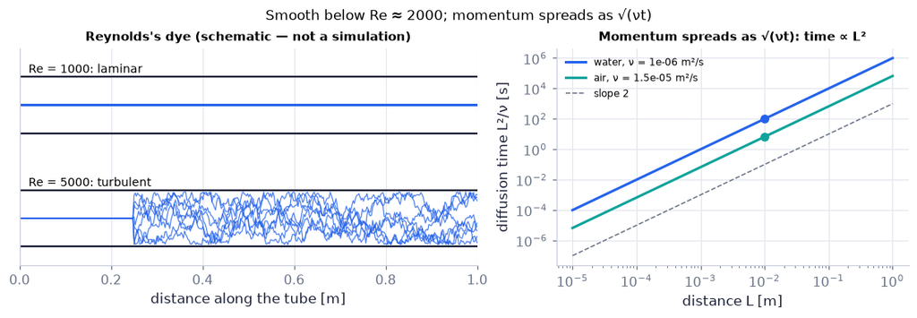

```python
fig, (a1, a2) = plt.subplots(1, 2, figsize=(10, 3.4), gridspec_kw=dict(width_ratios=[1.3, 1]))   # two panels
x = np.linspace(0, 1, 400)                               # position along the tube [m]
for yc, U, lab in ((0.6, 0.1, "laminar"), (-0.6, 0.5, "turbulent")):     # two tubes, one above the other [schematic units]
    a1.plot([0, 1], [yc + 0.3, yc + 0.3], color=COLORS["ink"], lw=1.5)   # upper tube wall
    a1.plot([0, 1], [yc - 0.3, yc - 0.3], color=COLORS["ink"], lw=1.5)   # lower tube wall
    Re, verdict = ch08.pipe_flow_regime(U, 0.01, NU_W)   # the regime from the real Re of a 1 cm water pipe
    if verdict == "laminar":                             # a straight dye thread on the axis
        a1.plot(x, yc + 0*x, color=COLORS["blue"], lw=2)
    else:                                                # eight seeded random walks that fill the tube (schematic only)
        rng = np.random.default_rng(1)                   # reproducible "chaos"
        w = 0.28                                         # half-width available to the dye [schematic units]
        for k in range(8):                               # eight dye streaks leaving the injector
            walk = np.cumsum(rng.normal(0, 0.04, x.size)) * (x > 0.25)   # each starts to wander at x = 0.25 m
            z = np.mod(walk + w, 4*w)                    # fold the walk back at the walls (a reflecting wall) …
            a1.plot(x, yc + np.where(z < 2*w, z, 4*w - z) - w, color=COLORS["blue"], lw=0.8, alpha=0.8)   # … so it fills the tube
    a1.text(0.02, yc + 0.34, f"Re = {Re:.0f}: {verdict}", fontsize=9)    # label with the computed Re
a1.set_xlim(0, 1); a1.set_ylim(-1.1, 1.2); a1.set_yticks([])            # schematic: no vertical scale
a1.set_xlabel("distance along the tube [m]"); a1.set_title("Reynolds's dye (schematic — not a simulation)", fontsize=10)
L = np.geomspace(1e-5, 1.0, 50)                          # distances from 10 µm to 1 m [m]
for nu, c, name in ((nu_water, COLORS["blue"], "water"), (nu_air, COLORS["teal"], "air")):
    a2.loglog(L, ch08.diffusion_time(L, nu), color=c, lw=2, label=f"{name}, ν = {nu:.2g} m²/s")   # t = L²/ν
    a2.plot(0.01, ch08.diffusion_time(0.01, nu), "o", color=c)           # the 1 cm point
a2.loglog(L, 1e3*L**2, color=COLORS["muted"], ls="--", lw=1, label="slope 2")   # guide line t ∝ L²
a2.set_xlabel("distance L [m]"); a2.set_ylabel("diffusion time L²/ν [s]"); a2.legend(fontsize=8)
a2.set_title("Momentum spreads as √(νt): time ∝ L²", fontsize=10)
fig.suptitle("Smooth below Re ≈ 2000; momentum spreads as √(νt)", fontsize=11)
savefig(fig, "ch08", "c01_reynolds_diffusion"); plt.show()
```

**What you see.** (a) a straight dye thread at Re = 1000 and a mixed tube at Re = 5000 — our synthetic sketch of Reynolds's apparatus `N103`, labelled schematic; (b) two parallel lines of slope 2, air's 15 times lower than water's.

**How to read it.** On (b) read the time to diffuse a distance: 1 cm takes about 100 s in water and 6.6 s in air (the dots); the slope 2 says ten times farther takes a hundred times longer.

**What would change if…** …the fluid were glycerine (ν ≈ 10⁻³ m²/s): its line drops by 1000 below water's — 1 cm in 0.1 s — and Re at 10 cm/s in the 1 cm tube is 1, deeply laminar.

📝 **Note.** **N02 [C] · Where this leads.** When viscosity matters only in thin layers next to walls, we get boundary layers (Ch. 9); whether these laminar flows survive small disturbances is Ch. 11's question; fully turbulent flow is Ch. 12; viscous layers in a rotating fluid — the Ekman layers of the ocean and atmosphere — are Ch. 13. The $\sqrt{\nu t}$ spreading of this chapter reappears in all four.

> 🔁 **Recap — The Navier–Stokes equation for constant ρ and μ** (Ch. 4 §4.6). Every solution below satisfies continuity $\nabla\cdot\mathbf u=0$ *(4.10)* and $\frac{D\mathbf u}{Dt}=-\frac1\rho\nabla p+\nu\nabla^2\mathbf u$ *(8.1)*, which is Ch. 4's $\rho\frac{D\mathbf u}{Dt}=-\nabla p'+\mu\nabla^2\mathbf u$ *(4.85)* divided by ρ (gravity absorbed into p, R06). We check each one with Ch. 4's term calculator: plug the velocity and pressure in and the residual must vanish.

> 🔁 **Tools from earlier chapters used here** (see `knowledge/primers.md`)
- **functions as arguments and lambda** — `lambda x, t=0.0: …` is a one-line function; Ch. 4's calculator takes the velocity and pressure *as functions* and differentiates them numerically (Ch. 1 P29).
- **component-first array layout (x[0], x[1])** — a point is an array whose first index is the component: `x[0]` is x, `x[1]` is y, `x[2]` is z (Ch. 2 P76, the project grid layout).

```python
u_fn = lambda x, t=0.0: np.stack([ch08.channel_flow(x[1], 0.01, U=0.1, dpdx=-4.0), 0*x[0], 0*x[0]])   # C02's channel flow u(y)
p_fn = lambda x, t=0.0: -4.0 * x[0]                      # a linear pressure p = −4x [Pa]: dp/dx = −4 Pa/m
terms = NS.ns_incompressible_terms(u_fn, p_fn, np.array([0.3, 0.004, 0.0]), mu=MU_W, g=(0.0, 0.0, 0.0))   # at one point
print("advective ", terms.advective)                    # u·∇u [m/s²]: exactly zero (C02 explains why)
print("pressure  ", terms.pressure)                     # −(1/ρ)∂p/∂x = +4 × 10⁻³ m/s²
print("viscous   ", terms.viscous)                      # ν ∂²u/∂y² = −4 × 10⁻³ m/s²
print(f"residual   max |sum| = {np.max(np.abs(terms.residual)):.1e} m/s²")   # their sum: ≈ 0 (round-off)
```

```
advective  [0. 0. 0.]
pressure   [ 0.004 -0.    -0.   ]
viscous    [-0.004  0.     0.   ]
residual   max |sum| = 1.1e-15 m/s²
```

**What does the code above do?**

1. `u_fn` is the channel flow of C02 written as a function of position (component-first: `x[1]` is y); `p_fn` is a pressure falling 4 Pa per metre.
2. `ns_incompressible_terms` (Ch. 4) evaluates every term of (8.1), $\frac{D\mathbf u}{Dt}=-\frac1\rho\nabla p+\nu\nabla^2\mathbf u$ at the point (0.3, 0.004, 0) m by finite differences.
3. The pressure term $+4\times10^{-3}$ m/s² and the viscous term $-4\times10^{-3}$ m/s² cancel; the advective term is exactly zero; the residual is at round-off (10⁻¹⁵). C02 derives this profile; here we only see that it passes the test.

> 🔁 **Recap — No flow through a wall** (Ch. 4 §4.10). At a solid surface moving with velocity $\mathbf U_s$ the normal velocities agree: $\mathbf n\cdot\mathbf U_s=(\mathbf n\cdot\mathbf u)_{\text{on the surface}}$ *(8.2)*, with **n** the unit normal (length 1, perpendicular to the surface).

> 🔁 **Tools from earlier chapters used here** (see `knowledge/primers.md`)
- **unit normal and tangent vectors** — a unit vector has length 1; the normal **n** points out of the wall, a tangent **t** lies along it, and $\mathbf n\cdot\mathbf u$ picks the component of **u** along **n** (Ch. 2 P65, projection).

> 🔁 **Recap — No slip** (Ch. 4 §4.10). The tangential velocities agree too: $\mathbf t\cdot\mathbf U_s=(\mathbf t\cdot\mathbf u)_{\text{on the surface}}$ *(8.3)* — viscous fluid sticks to walls. Every constant of integration in this chapter is fixed by (8.2), $\mathbf n\cdot\mathbf U_s=(\mathbf n\cdot\mathbf u)_{\text{on the surface}}$ and (8.3).

```python
n = np.array([0.0, 1.0, 0.0])                            # unit normal of a floor y = 0 (pointing into the fluid)
wall = np.array([0.1, 0.0, 0.0])                         # the floor slides at 0.1 m/s along x
print(ch08.wall_bc_residuals(np.array([0.1, 0, 0]), wall, n))      # fluid moves with the wall: (normal, tangential) = (0, 0)
print(ch08.wall_bc_residuals(np.array([0.08, 0.01, 0]), wall, n))  # a leaky, slipping wall: both residuals non-zero [m/s]
```

```
(0.0, 0.0)
(0.01, 0.020000000000000004)
```

**What does the code above do?**

`wall_bc_residuals(u_wall, U_s, n)` returns how much (8.2), $\mathbf n\cdot\mathbf U_s=(\mathbf n\cdot\mathbf u)_{\text{on the surface}}$ and (8.3), $\mathbf t\cdot\mathbf U_s=(\mathbf t\cdot\mathbf u)_{\text{on the surface}}$ are violated: the normal mismatch $\mathbf n\cdot(\mathbf u-\mathbf U_s)$ and the size of the tangential mismatch. The first call obeys both; the second has fluid leaking through (0.01 m/s) and slipping (0.02 m/s).

> 🔁 **Recap — Standing assumptions** (Ch. 4 §4.9). Constant density, an inertial frame, and gravity absorbed into the pressure ($p\to p+\rho gz$) whenever there is no free surface — only the spreading film (C08) and the settling sphere (C14) bring g back.

## 8.2 Exact Solutions for Steady Incompressible Viscous Flow

**What is this section about?** Three flows where symmetry removes the nonlinear term $\mathbf u\cdot\nabla\mathbf u$ exactly, so the Navier–Stokes equation becomes a linear ODE that we can integrate by hand: flow between parallel plates driven by a moving wall and a pressure gradient, flow in a round pipe, and flow between two rotating cylinders. The same short argument — continuity kills one velocity, "a function of x equals a function of y" makes the pressure gradient constant — solves all three.

> 🔁 **Recap — Plane Couette flow** (Ch. 1 §1.5). A fluid between a fixed plate and a plate sliding at U, with no pressure gradient, moves with the straight profile $u=Uy/h$ and a uniform shear stress $\tau=\mu\,du/dy=\mu U/h$ (Ch. 1). C02 shows it is one half of a two-part formula.

> 🔁 **Recap — Plane Poiseuille flow** (Ch. 4 §4.6). With both plates at rest and a pressure gradient, the profile is the parabola $u(y)=-\frac1{2\mu}\frac{dp}{dx}y(h-y)$, the stress $\tau=\mu\frac{du}{dy}=-\big(\frac h2-y\big)\frac{dp}{dx}$ is linear and its magnitude at both walls is $\frac h2\lvert dp/dx\rvert$. Ch. 4's `plane_poiseuille` takes $G=-dp/dx$.

```python
y = np.linspace(0, 0.01, 5)                              # five heights across a 1 cm channel [m]
print(ch04.plane_poiseuille(y, G=2.0, h=0.01))           # Ch. 4: G = −dp/dx = +2 Pa/m  → u [m/s]
print(ch08.channel_flow(y, 0.01, U=0.0, dpdx=-2.0))      # Ch. 8: the book's dp/dx = −2 Pa/m, fixed walls → the same u
```

```
[0.     0.0187 0.025  0.0188 0.    ]
[0.     0.0187 0.025  0.0188 0.    ]
```

> ⚠️ **Common confusion:** the book's $dp/dx=-2$ Pa/m (pressure falling downstream, a *favourable* gradient) is Ch. 4's $G=+2$ Pa/m. Same flow, opposite sign of the argument — the two identical rows above pin it.

### 🧩 Plane Couette–Poiseuille flow `C02`

*The question:* What profile results from a moving wall plus a pressure gradient — and when does fluid near the fixed wall flow backwards?

*In one line:* $u(y)=\frac Uh\,y-\frac1{2\mu}\frac{dp}{dx}\,y(h-y)$ *(8.5)*

#### The problem in plain words

A belt drags oil along a channel while a pump pushes back. Near the belt the oil is carried forward; near the fixed floor the pump may win and push it backwards. Journal bearings, extrusion dies, the wind-driven surface layer of a lake with a return current underneath — all are this flow. We want the exact profile and the condition for the reversed current.

#### The idea

```
y=h ═══════════► U        y=h ═════════        y=h ═══════════► U
     ─────────►                 ──►                    ─────────►
     ──────►        +           ────►        =         ──────►
     ───►                       ──►                    ─►      (backflow if the parabola
y=0 ═════════             y=0 ═════════        y=0 ═══◄══       is pushed the other way)
  Couette: line            Poiseuille: parabola          sum (8.5)
```

*The numbered equations in the sketch:* $u(y)=\frac Uh\,y-\frac1{2\mu}\frac{dp}{dx}\,y(h-y)$ *(8.5)*

Because the equation turns out linear, the two causes simply **add**.

📝 **Note.** **N03 [B] · Fully developed flow.** Near the channel inlet, boundary layers grow on both walls and the profile changes with x — inside this *entrance length* $\partial u/\partial x\ne0$, so continuity $\partial u/\partial x+\partial v/\partial y=0$ forces $v\ne0$ and the flow is not parallel. Downstream the layers merge and the profile stops changing: u = u(y) alone. The figure below draws the wall-layer edge with the diffusion estimate $\delta_{99}\sim3.64\sqrt{\nu t}$ *(8.31)* and t = x/U — **our estimate** (C09 derives the 3.64), not the book's; Ch. 9 treats entry flow properly.

> 🔁 **Tools from earlier chapters used here** (see `knowledge/primers.md`)
- **scipy.optimize.brentq** — `optimize.brentq(f, a, b)` finds the root of f between a and b where f changes sign (Ch. 3 P108); here: where the wall layer reaches mid-gap.
- **error function erf (a first look)** — `special.erf(z)` rises smoothly from 0 at z = 0 to 1 for large z; its complement erfc = 1 − erf is Ch. 4's P123. Here it only shapes a schematic wall layer; C09 (primer P195) explains where it comes from.
- **trapezoid rule (from scratch)** — `np.trapezoid(f, x)` adds up trapezoids under the sampled curve (Ch. 1 P37) — here to scale the schematic profiles to one mean speed.

```
layers meet at x_e = 0.0188 m (about 1.9 gap widths)
```

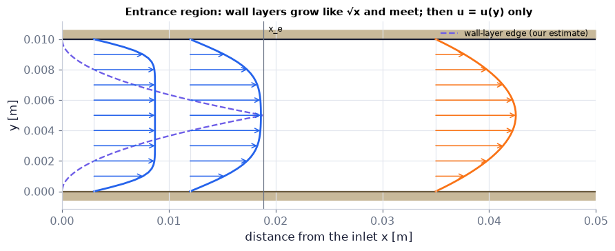

```python
h, Uin = 0.01, 0.01                                       # gap 1 cm, inflow speed 1 cm/s [m, m/s]
edge = lambda x: ch08.diffusion_thickness(x/Uin, NU_W)    # wall-layer edge δ(x) = 3.643√(ν x/U) [m] (our estimate)
x_e = optimize.brentq(lambda x: edge(x) - h/2, 1e-6, 1.0)  # where the two layers meet at mid-gap [m]
print(f"layers meet at x_e = {x_e:.4f} m (about {x_e/h:.1f} gap widths)")
x = np.linspace(1e-5, 0.05, 400)                          # distance from the inlet [m]
fig, ax = plt.subplots(figsize=(8, 3.2))
channel(ax, h, U=0.0, L=0.05)                             # two fixed walls (drawing only)
xl = x[x <= x_e]                                          # the edges exist only until they meet
ax.plot(xl, edge(xl), color=COLORS["accent"], ls="--", lw=1.5, label="wall-layer edge (our estimate)")   # lower wall's layer
ax.plot(xl, h - edge(xl), color=COLORS["accent"], ls="--", lw=1.5)                                     # the upper wall's layer
ax.axvline(x_e, color=COLORS["muted"], lw=0.8); ax.text(x_e + 5e-4, 0.0105, "x_e", fontsize=8)
yy = np.linspace(0, h, 41)                                # heights for the three profiles [m]
V = Uin                                                   # the mean speed is conserved along the channel [m/s]
for x0 in (0.003, 0.012):                                 # two developing stations: plug core, erf-shaped wall layers
    d = np.sqrt(NU_W*x0/Uin)                              # diffusion length √(ν x/U) there [m]
    shape = special.erf(yy/(2*d)) * special.erf((h - yy)/(2*d))   # schematic developing profile (0 at both walls)
    prof = V * shape / np.trapezoid(shape, yy) * h        # scaled to the same mean speed V
    profile_arrows(ax, yy, prof, x0=x0, scale=0.5, every=4, color=COLORS["blue"])
u_dev = ch08.channel_flow(yy, h, U=0.0, dpdx=-12*MU_W*V/h**2)   # fully developed: Poiseuille with mean V ((8.5), U = 0)
profile_arrows(ax, yy, u_dev, x0=0.035, scale=0.5, every=4, color=COLORS["orange"])
ax.set_xlim(0, 0.05); ax.set_xlabel("distance from the inlet x [m]"); ax.set_ylabel("y [m]")
ax.legend(loc="upper right", fontsize=8)
ax.set_title("Entrance region: wall layers grow like √x and meet; then u = u(y) only", fontsize=10)
savefig(fig, "ch08", "c02_entrance"); plt.show()
```

**What you see.** Two dashed edges growing like √x from the walls and meeting at $x_e$ (printed above, about 1.9 cm — about twice the gap); blue profiles still developing (flat core, thin wall layers), then the orange parabola of the fully developed flow.

**How to read it.** Left of $x_e$ the core still moves as a plug; right of it the profile no longer changes with x — it is the parabola of (8.5), $u(y)=\frac Uh\,y-\frac1{2\mu}\frac{dp}{dx}\,y(h-y)$ with U = 0 — and every result of this section applies.

**What would change if…** …the inflow were 10 times faster: the edge $\delta\propto\sqrt{\nu x/U}$ grows √10 times more slowly, so the entrance length grows tenfold ($x_e\propto Uh^2/\nu$).

> 🔁 **Tools from earlier chapters used here** (see `knowledge/primers.md`)
- **partial derivative** — ∂u/∂x is the rate of change of u with x while y, z, t are held fixed (Ch. 1 P25).

📝 **Note.** **N04 [B] · Continuity kills v.** With $\partial u/\partial x=0$, continuity gives $\partial v/\partial y=0$; v is then the same at every height and equals its wall value 0: $\mathbf u=(u(y),0,0)$. This is steps 1–3 of the derivation below.

📝 **Note.** **N05 [B], N06 [B] · The reduced equations.** What is left of the momentum equations is (8.4a) and (8.4b) below: no acceleration at all — the advective term vanishes *exactly*, which is why the problem is linear.

$$ 0=-\frac1\rho\frac{\partial p}{\partial x}+\nu\frac{d^2u}{dy^2},\qquad 0=-\frac1\rho\frac{\partial p}{\partial y} \qquad \text{(8.4a, 8.4b)} $$

#### 🧮 Derivation — v ≡ 0 and the reduced equations $0=-\frac1\rho\frac{\partial p}{\partial x}+\nu\frac{d^2u}{dy^2}$, $0=-\frac1\rho\frac{\partial p}{\partial y}$ `D02` (Eq. 8.4a: $0=-\frac1\rho\frac{\partial p}{\partial x}+\nu\frac{d^2u}{dy^2}$)

**What we want to show.** Show that in steady, fully developed flow between plates the vertical velocity vanishes and Navier–Stokes shrinks to two short linear equations.

**Assumptions.** Steady (step 5); fully developed ∂u/∂x = 0 (step 1); 2-D, w = 0, ∂/∂z = 0 (step 1); impermeable walls (step 3).

**The plan.**

1. Use "fully developed" in continuity.
2. Fix v with the walls.
3. Drop every term that vanishes.

**Tools we use** (each explained before this point): partial derivative (P25) · continuity (R03) · no through-flow (8.2), $\mathbf n\cdot\mathbf U_s=(\mathbf n\cdot\mathbf u)_{\text{on the surface}}$ (R04).

**We start from**

$$ \frac{\partial u}{\partial x}+\frac{\partial v}{\partial y}=0\ \text{((4.10) in 2-D)},\qquad \frac{D\mathbf u}{Dt}=-\frac1\rho\nabla p+\nu\nabla^2\mathbf u\ \text{(8.1)} $$

*In words:* mass and momentum for the fluid between the plates.

**Step 1 of 7 — Use the fully developed condition.**

$$ \frac{\partial u}{\partial x}=0\ \Rightarrow\ u=u(y) $$

- *Why we can do this:* Far past the entrance the profile no longer changes along the channel; with w = 0 and ∂/∂z = 0 the flow is 2-D.
- *In words:* u depends on height only.

**Step 2 of 7 — Put it into continuity.**

$$ \frac{\partial v}{\partial y}=0 $$

- *Why we can do this:* (4.10), $\nabla\cdot\mathbf u=0$ with ∂u/∂x = 0 leaves only the v-term; we want to learn what this says about v.
- *In words:* v does not change with height.

**Step 3 of 7 — Use the impermeable walls.**

$$ v(x,0)=0\ \Rightarrow\ v\equiv0 $$

- *Why we can do this:* A function of y with zero y-derivative is the same at every height, and (8.2), $\mathbf n\cdot\mathbf U_s=(\mathbf n\cdot\mathbf u)_{\text{on the surface}}$ makes it zero at the wall — so it is zero everywhere.
- *In words:* the flow is parallel to the walls: u = (u(y), 0, 0).

**Step 4 of 7 — Evaluate the advective acceleration.**

$$ u\frac{\partial u}{\partial x}+v\frac{\partial u}{\partial y}=u\cdot0+0\cdot \frac{du}{dy}=0 $$

- *Why we can do this:* Both factors vanish by steps 1 and 3 — exactly, not approximately; this is why the problem becomes linear.
- *In words:* no fluid particle accelerates.

**Step 5 of 7 — Write the steady x-momentum.**

$$ 0=-\frac1\rho\frac{\partial p}{\partial x}+\nu\Big(\frac{\partial^2u}{\partial x^2}+ \frac{\partial^2u}{\partial y^2}\Big) $$

- *Why we can do this:* The x-component of (8.1), $\frac{D\mathbf u}{Dt}=-\frac1\rho\nabla p+\nu\nabla^2\mathbf u$ with ∂u/∂t = 0 (steady) and step 4.
- *In words:* pressure and friction balance.

**Step 6 of 7 — Drop the x-curvature.**

$$ 0=-\frac1\rho\frac{\partial p}{\partial x}+\nu\frac{d^2u}{dy^2}\ \text{(8.4a)} $$

- *Why we can do this:* u depends on y only, so ∂²u/∂x² = 0 and the partial y-derivative is an ordinary one.
- *In words:* (8.4a), $0=-\frac1\rho\frac{\partial p}{\partial x}+\nu\frac{d^2u}{dy^2}$: the pressure gradient is balanced by cross-channel friction.

**Step 7 of 7 — Write the y-momentum.**

$$ 0=-\frac1\rho\frac{\partial p}{\partial y}\ \text{(8.4b)} $$

- *Why we can do this:* Every v-term in the y-component of (8.1), $\frac{D\mathbf u}{Dt}=-\frac1\rho\nabla p+\nu\nabla^2\mathbf u$ is zero because v ≡ 0; only the pressure term survives.
- *In words:* (8.4b), $0=-\frac1\rho\frac{\partial p}{\partial y}$: pressure does not change across the channel.

**Result**

$$ 0=-\frac1\rho\frac{\partial p}{\partial x}+\nu\frac{d^2u}{dy^2}\ \text{(8.4a)},\qquad 0=-\frac1\rho\frac{\partial p}{\partial y}\ \text{(8.4b)} $$

*In words:* a steady parallel flow is a pure pressure–friction balance.

**What it means.** Because the nonlinear term vanishes identically, the solution will be exact, not approximate. In the entrance region (∂u/∂x ≠ 0) this fails: v ≠ 0 (N03).

**Check it.** Units of (8.4a), $0=-\frac1\rho\frac{\partial p}{\partial x}+\nu\frac{d^2u}{dy^2}$: (1/ρ)∂p/∂x in (m³/kg)(Pa/m) = m/s², ν d²u/dy² in (m²/s)(1/(m s)) = m/s² ✓. The same steps applied in `ch08.parallel_flow_sympy("channel")` (the code cell after the tiny example of C02) return these two equations.

> ⚠️ **Common confusion (traps in `D02`):** ∂v/∂y = 0 alone only says v is constant across the gap — the wall value fixes it to zero; the advective term is zero exactly, not "small".

📝 **Note.** **N07 [B] · Separation of variables in one line.** From $0=-\frac1\rho\frac{\partial p}{\partial y}$ *(8.4b)* p depends on x only; then the balance below says "a function of x = a function of y", so both equal one constant: the pressure falls **linearly** along the channel. The same argument returns in the pipe (C03), the rotating cylinders (C04) and the lubrication gap (C06).

$$ \frac{1}{\mu}\frac{dp}{dx}=\frac{d^2u}{dy^2}=\text{const} $$

> 🔁 **Tools from earlier chapters used here** (see `knowledge/primers.md`)
- **separation of variables** — if f(x) = g(y) for all x and y, both sides must equal the same constant (Ch. 1 P42).

#### 🧮 Derivation — The pressure gradient is constant: $\frac1\mu\frac{dp}{dx}=\frac{d^2u}{dy^2}=\text{const}$ `D03` (Eq. 8.4a: $0=-\frac1\rho\frac{\partial p}{\partial x}+\nu\frac{d^2u}{dy^2}$)

**What we want to show.** Show that in fully developed channel flow the pressure falls linearly along the channel.

**Assumptions.** Steady (p does not depend on t).

**The plan.**

1. Learn from (8.4b), $0=-\frac1\rho\frac{\partial p}{\partial y}$ what p depends on.
2. Separate (8.4a), $0=-\frac1\rho\frac{\partial p}{\partial x}+\nu\frac{d^2u}{dy^2}$ into an x-side and a y-side.
3. Differentiate each side by the other variable.

**Tools we use** (each explained before this point): partial derivative (P25) · separation of variables (P42).

**We start from**

$$ 0=-\frac1\rho\frac{\partial p}{\partial x}+\nu\frac{d^2u}{dy^2}\ \text{(8.4a) and}\ 0=-\frac1\rho\frac{\partial p}{\partial y}\ \text{(8.4b)} $$

*In words:* the reduced equations of D02.

**Step 1 of 5 — Read (8.4b).**

$$ p=p(x)\ \Rightarrow\ \frac{\partial p}{\partial x}=\frac{dp}{dx}(x) $$

- *Why we can do this:* ∂p/∂y = 0 means p is the same at every height, so its x-derivative depends on x only.
- *In words:* the pressure gradient can vary only along the channel.

**Step 2 of 5 — Multiply (8.4a) by ρ and rearrange.**

$$ \frac{dp}{dx}(x)=\mu\frac{d^2u}{dy^2}(y) $$

- *Why we can do this:* ρν = μ; we isolate the pressure side, a function of x alone, and the velocity side, a function of y alone.
- *In words:* an x-function equals a y-function at every point.

**Step 3 of 5 — Differentiate both sides by x.**

$$ \frac{d^2p}{dx^2}=0 $$

- *Why we can do this:* The right side does not contain x, so its x-derivative is zero; hence so is the left side's.
- *In words:* the pressure gradient does not change along x.

**Step 4 of 5 — Differentiate both sides by y.**

$$ \mu\frac{d^3u}{dy^3}=0 $$

- *Why we can do this:* The left side does not contain y; so the y-derivative of the right side vanishes too — it is also a constant.
- *In words:* the curvature of the profile is the same at every height.

**Step 5 of 5 — Name the common constant.**

$$ \frac1\mu\frac{dp}{dx}=\frac{d^2u}{dy^2}=\text{const},\ \ p=p_0+\frac{dp}{dx}x $$

- *Why we can do this:* Both sides are constants and equal each other; integrating d²p/dx² = 0 once more gives a linear pressure.
- *In words:* pressure falls (or rises) linearly, the profile has constant curvature.

**Result**

$$ \frac1\mu\frac{dp}{dx}=\frac{d^2u}{dy^2}=\text{const} $$

*In words:* one constant sets both the pressure slope and the profile's curvature.

**What it means.** The same "x-function = y-function" argument will fix the pressure gradient in the pipe (D06), between rotating cylinders (no pressure in the φ-equation, D08) and across the lubrication gap (D12).

**Check it.** A pressure p = x² would make the left side 2x/μ, which cannot equal a function of y at every x — `parallel_flow_sympy` confirms no solution exists for non-constant dp/dx.

> ⚠️ **Common confusion (traps in `D03`):** Differentiate each side by the *other* variable; the constant can have either sign (favourable or adverse).

> 🔁 **Tools from earlier chapters used here** (see `knowledge/primers.md`)
- **integrating an ODE twice and fixing two constants** — a second-order linear ODE has a two-parameter family of solutions; two conditions pick one (Ch. 1 P44, linear second-order ODE).
- **fundamental theorem of calculus** — integrating a derivative gives back the function plus a constant: $\int u''\,dy=u'+c_1$ (Ch. 2 P84).
- **sympy and sympy.dsolve** — `sp.dsolve(sp.Eq(lhs, rhs))` solves an ODE symbolically; `C1`, `C2` in its answer are the free constants (Ch. 1 P40).
- **two linear equations in two unknowns, np.linalg.solve** — `np.linalg.solve(M, b)` returns x with M x = b (Ch. 2 P57); we use it for two wall conditions.

*Integrating an ODE twice.* Integrating $u''=c$ twice brings two constants, $u=cy^2/2+c_1y+c_2$; two wall conditions fix them (a 2 × 2 linear system). sympy's `dsolve` does it in one line:

```python
y_, c_ = sp.symbols("y c")                               # height and the constant curvature (symbols)
u_ = sp.Function("u")                                    # the unknown profile u(y)
print(sp.dsolve(sp.Eq(u_(y_).diff(y_, 2), c_)))          # u'' = c  →  u = C1 + C2·y + c·y²/2
```

```
Eq(u(y), C1 + C2*y + c*y**2/2)
```

📝 **Note.** **N08 [B] · The book's constants.** The book integrates to the line below with B = 0 and $A=\frac h2\frac{dp}{dx}-\frac{\mu U}{h}$; its A and B are minus our $c_1$ and $c_2$ (D04 step 3).

$$ 0=-\frac{y^2}{2}\frac{dp}{dx}+\mu u+Ay+B $$

#### 🧮 Derivation — Couette–Poiseuille profile $u(y)=\frac Uhy-\frac1{2\mu}\frac{dp}{dx}y(h-y)$ `D04` (Eq. 8.5: $u(y)=\frac Uh\,y-\frac1{2\mu}\frac{dp}{dx}\,y(h-y)$)

**What we want to show.** Find the velocity at every height between a fixed floor and a top plate moving at U, with a constant pressure gradient.

**Assumptions.** dp/dx constant (D03); no slip at both plates (steps 4–5).

**The plan.**

1. Integrate twice.
2. Apply the two no-slip conditions.
3. Regroup into the book's form.

**Tools we use** (each explained before this point): integrating an ODE twice (gloss in C02) · 2 × 2 linear system (P57) · no slip (8.3), $\mathbf t\cdot\mathbf U_s=(\mathbf t\cdot\mathbf u)_{\text{on the surface}}$ (R05).

**We start from**

$$ \mu\frac{d^2u}{dy^2}=\frac{dp}{dx}=\text{const (D03)},\qquad u(0)=0,\ \ u(h)=U $$

*In words:* a constant curvature and two wall speeds.

**Step 1 of 9 — Integrate once in y.**

$$ \mu\frac{du}{dy}=\frac{dp}{dx}y+c_1 $$

- *Why we can do this:* Fundamental theorem of calculus; dp/dx is a constant (D03), so its antiderivative is (dp/dx)y plus a constant c₁.
- *In words:* the shear stress changes linearly with height.

**Step 2 of 9 — Integrate again.**

$$ \mu u=\frac{dp}{dx}\frac{y^2}{2}+c_1y+c_2 $$

- *Why we can do this:* Integrate each term once more; a second constant c₂ appears.
- *In words:* the profile is a parabola plus a straight line.

**Step 3 of 9 — Compare with the book's constants.**

$$ 0=-\frac{y^2}{2}\frac{dp}{dx}+\mu u+Ay+B,\ \ A=-c_1,\ B=-c_2 $$

- *Why we can do this:* Moving everything to one side gives the book's line; its A and B are minus our constants — worth saying to avoid sign confusion.
- *In words:* same equation, constants named differently.

**Step 4 of 9 — Apply no slip at the floor.**

$$ u(0)=0\ \Rightarrow\ c_2=0 $$

- *Why we can do this:* (8.3), $\mathbf t\cdot\mathbf U_s=(\mathbf t\cdot\mathbf u)_{\text{on the surface}}$ on the fixed plate; at y = 0 the first two terms vanish, leaving c₂ = 0.
- *In words:* the fluid at the floor is at rest.

**Step 5 of 9 — Apply no slip at the top.**

$$ \mu U=\frac{dp}{dx}\frac{h^2}{2}+c_1h $$

- *Why we can do this:* (8.3), $\mathbf t\cdot\mathbf U_s=(\mathbf t\cdot\mathbf u)_{\text{on the surface}}$ on the moving plate: at y = h the fluid moves at U.
- *In words:* one equation for c₁.

**Step 6 of 9 — Solve for c₁.**

$$ c_1=\frac{\mu U}{h}-\frac h2\frac{dp}{dx} $$

- *Why we can do this:* Divide step 5 by h and subtract; the book's A = −c₁ = (h/2)dp/dx − μU/h matches the page.
- *In words:* the wall stress constant mixes drag and pressure.

**Step 7 of 9 — Substitute the constants.**

$$ \mu u=\frac{dp}{dx}\frac{y^2}{2}+\Big(\frac{\mu U}{h}-\frac h2\frac{dp}{dx}\Big)y $$

- *Why we can do this:* Insert c₁ and c₂ = 0 into step 2 to get the profile.
- *In words:* the profile with both constants fixed.

**Step 8 of 9 — Divide by μ and group.**

$$ u=\frac Uhy+\frac{1}{2\mu}\frac{dp}{dx}(y^2-hy) $$

- *Why we can do this:* Collect the two dp/dx terms: y²/2 − hy/2 = (y² − hy)/2.
- *In words:* a line plus a parabola.

**Step 9 of 9 — Rewrite the parabola.**

$$ u(y)=\frac Uhy-\frac1{2\mu}\frac{dp}{dx}y(h-y)\ \text{(8.5)} $$

- *Why we can do this:* y² − hy = −y(h − y); this form makes the parabola positive inside the gap when dp/dx < 0.
- *In words:* (8.5), $u(y)=\frac Uh\,y-\frac1{2\mu}\frac{dp}{dx}\,y(h-y)$.

**Result**

$$ u(y)=\frac Uhy-\frac1{2\mu}\frac{dp}{dx}y(h-y) $$

*In words:* wall drag (a line) plus pressure push (a parabola).

**What it means.** Because the equation is linear, causes simply add; the book's Fig. 8.4 is four cases of one formula.

**Check it.** u(0) = 0 ✓, u(h) = U ✓; units of (1/μ)(dp/dx)y² : (1/(Pa s))(Pa/m)m² = m/s ✓; dp/dx = 0 gives Couette, U = 0 gives Poiseuille (D05). Numbers: h = 1 cm, U = 0.1 m/s, dp/dx = 4 Pa/m at y = h/4: 0.025 − 0.0375 = −0.0125 m/s.

> ⚠️ **Common confusion (traps in `D04`):** The book's A, B have the opposite sign to c₁, c₂; dp/dx < 0 (favourable) gives a *forward* parabola because of the minus sign; check both walls at the end.

#### ✏️ Tiny example: a 1 cm channel, belt at 10 cm/s, adverse gradient 4 Pa/m

Take h = 0.01 m, U = 0.1 m/s, μ = 10⁻³ Pa s, dp/dx = +4 Pa/m (pressure rising downstream), at the quarter height y = h/4 = 0.0025 m.

1. Couette part: $Uy/h=0.1\times0.25=0.025$ m/s.
2. Poiseuille part: $-\frac{1}{2\mu}\frac{dp}{dx}y(h-y)=-\frac{4}{2\times10^{-3}}\times0.0025\times0.0075=-0.0375$ m/s.
3. Sum: u = −0.0125 m/s — the fluid moves **backwards** at the quarter height.
4. Threshold: $2\mu U/h^2=2\times10^{-3}\times0.1/10^{-4}=2$ Pa/m; we are at twice it.
5. Flow rate $Q=\frac{Uh}2-\frac{h^3}{12\mu}\frac{dp}{dx}=5\times10^{-4}-3.33\times10^{-4}=1.67\times10^{-4}$ m²/s: still forward overall.

```python
h, U = 0.01, 0.1                                         # gap [m] and wall speed [m/s] of the tiny example
y = np.linspace(0, h, 9)                                 # nine heights, y = 0, h/8, …, h [m]
u = ch08.channel_flow(y, h, U=U, dpdx=4.0)               # (8.5) with an adverse gradient dp/dx = +4 Pa/m
print("u(y) =", np.round(u, 4), "m/s   (u at y = h/4 is the third entry)")
Q, V = ch08.channel_flow_rate(h, U=U, dpdx=4.0)          # flow rate per unit width [m²/s] and mean speed Q/h [m/s]
print(f"Q = {Q:.4g} m²/s, V = {V:.4g} m/s, threshold 2μU/h² = {ch08.channel_backflow_threshold(U, h):.3g} Pa/m")
s = ch08.couette_poiseuille_state(h, U, 4.0)             # everything the explainer shows, in one dictionary
print({k: (round(s[k], 6) if not isinstance(s[k], bool) else s[k]) for k in
       ("Q_couette", "Q_poiseuille", "tau_bottom", "tau_top", "backflow", "y_reversal", "zero_flow_dpdx", "u_max", "y_umax", "u_min", "y_umin")})
s2 = ch08.couette_poiseuille_state(0.01, 0.01, -0.5)     # D05's extremum example: h = 1 cm, U = 1 cm/s, dp/dx = −0.5 Pa/m
y_star = 0.01/2 - MU_W*0.01/(0.01*(-0.5))                # y* = h/2 − μU/(h dp/dx) (D05 step 9) [m]
print(f"extremum: y* = {1e3*y_star:.2f} mm by hand, library y_umax = {1e3*s2['y_umax']:.2f} mm, u_max = {100*s2['u_max']:.3f} cm/s")
ps = ch08.parallel_flow_sympy("channel")                 # D02–D04 done symbolically
print("sympy profile:", ps["profile"], "   (G here is the symbol for dp/dx)")
print("reduced x-momentum (8.4a):", ps["momentum_x"])   # with p = p(x): the y-equation (8.4b) is satisfied identically
```

```
u(y) = [ 0.     -0.0094 -0.0125 -0.0094  0.      0.0156  0.0375  0.0656  0.1   ] m/s   (u at y = h/4 is the third entry)
Q = 0.0001667 m²/s, V = 0.01667 m/s, threshold 2μU/h² = 2 Pa/m
{'Q_couette': 0.0005, 'Q_poiseuille': -0.000333, 'tau_bottom': -0.01, 'tau_top': 0.03, 'backflow': True, 'y_reversal': 0.005, 'zero_flow_dpdx': 6.0, 'u_max': 0.1, 'y_umax': 0.01, 'u_min': -0.0125, 'y_umin': 0.0025}
extremum: y* = 7.00 mm by hand, library y_umax = 7.00 mm, u_max = 1.225 cm/s
```

```
sympy profile: y*(-G*h**2 + G*h*y + 2*U*mu)/(2*h*mu)    (G here is the symbol for dp/dx)
reduced x-momentum (8.4a): Eq(0, mu*Derivative(u(y), (y, 2))/rho - Derivative(p(x), x)/rho)
```

**What does the code above do?**

1. `channel_flow` evaluates (8.5), $u(y)=\frac Uh\,y-\frac1{2\mu}\frac{dp}{dx}\,y(h-y)$; at y = h/4 it gives −0.0125 m/s, the tiny example's number.
2. `channel_flow_rate` integrates (8.5) exactly: Q = 1.667 × 10⁻⁴ m²/s and V = Q/h.
3. `couette_poiseuille_state` bundles the flow rate split into its two parts ($Uh/2$ and $-h^3(dp/dx)/12\mu$), the signed wall stresses (−0.01 Pa at the floor, +0.03 Pa at the top), the verdict `backflow = True`, where u changes sign — y = 5 mm, the reversed layer fills the lower half — and the gradient that stops the net flow, $6\mu U/h^2$ = 6 Pa/m.
4. `parallel_flow_sympy("channel")` repeats D02–D04 symbolically: its profile, written with the symbol G for dp/dx, is $\frac{Uy}{h}+\frac{G}{2\mu}(y^2-hy)$ — exactly (8.5).

> 🔁 **Tools from earlier chapters used here** (see `knowledge/primers.md`)
- **finite differences (tridiagonal solve from scratch)** — $u''\approx(u_{i+1}-2u_i+u_{i-1})/\Delta y^2$ turns the ODE into one linear equation per grid point (Ch. 1 P21).

*Two numpy helpers.* `np.diag(v, k)` builds a matrix with the vector v on its k-th diagonal (k = 0 main, ±1 just above or below); `np.r_[a, b, c]` glues numbers and arrays end to end into one array.

```python
N = 101; yy = np.linspace(0, h, N); dy = yy[1] - yy[0]   # 101 grid points across the gap [m]
Amat = (np.diag(-2*np.ones(N-2)) + np.diag(np.ones(N-3), 1) + np.diag(np.ones(N-3), -1)) / dy**2   # u'' on interior points
rhs = np.full(N-2, 4.0/MU_W)                             # μ u'' = dp/dx  →  u'' = (dp/dx)/μ at every interior point
rhs[-1] -= U/dy**2                                       # the known top-wall value u(h) = U moves to the right side
u_in = np.linalg.solve(Amat, rhs)                        # interior velocities [m/s]
u_fd = np.r_[0.0, u_in, U]                               # add the wall values u(0) = 0, u(h) = U
print("max |FD − (8.5)| =", np.max(np.abs(u_fd - ch08.channel_flow(yy, h, U=U, dpdx=4.0))), "m/s")
assert np.allclose(u_fd, ch08.channel_flow(yy, h, U=U, dpdx=4.0), rtol=1e-10, atol=1e-12)   # same profile
```

```
max |FD − (8.5)| = 2.220446049250313e-16 m/s
```

Central differences are exact for a parabola, so the hand-built solver reproduces $u(y)=\frac Uh\,y-\frac1{2\mu}\frac{dp}{dx}\,y(h-y)$ *(8.5)* to round-off.

📝 **Note.** **N09 [B] · Favourable, adverse, backflow (Fig. 8.4).** $dp/dx<0$ pushes with the wall: a fuller profile. $dp/dx>0$ pushes against it; the fluid next to the fixed wall reverses as soon as the slope du/dy at y = 0 turns negative, i.e. when the inequality below holds (ours — the book only draws it). Ch. 9 meets the same fight between wall shear and an adverse gradient: that is how boundary layers separate.

$$ \frac{dp}{dx}>\frac{2\mu U}{h^{2}} $$

> 🔁 **Tools from earlier chapters used here** (see `knowledge/primers.md`)
- **shear stress τ = μ du/dy, signed** — τ is the force per area that the fluid above a level exerts on the fluid below, in the x-direction (Ch. 1 P05); here we keep its sign.
- **derivative as a slope** — du/dy at the floor is the slope of the profile there; its sign says which way the fluid next to the wall moves (Ch. 1 P19).
- **inequalities under division by a positive number** — multiplying or dividing both sides by a positive number keeps the direction of an inequality; a negative one flips it (Ch. 1 P48).
- **first-order Taylor expansion** — near a point, $u(y)\approx u(0)+u'(0)\,y$ (Ch. 1 P26).

#### 🧮 Derivation — Limits, stress, and the backflow threshold $\frac{dp}{dx}>\frac{2\mu U}{h^2}$ `D05` (Eq. 8.5: $u(y)=\frac Uh\,y-\frac1{2\mu}\frac{dp}{dx}\,y(h-y)$)

**What we want to show.** Read the two classic special cases and the shear stress off (8.5), $u(y)=\frac Uh\,y-\frac1{2\mu}\frac{dp}{dx}\,y(h-y)$, and find exactly when the fluid near the fixed floor flows backwards (the book only draws it).

**Assumptions.** U > 0 in step 7 (for U < 0 the inequality flips).

**The plan.**

1. Switch off one cause at a time.
2. Differentiate for the stress.
3. Ask when the floor slope turns negative.

**Tools we use** (each explained before this point): derivative as a slope (P19) · first-order Taylor (P26) · inequalities (P48).

**We start from**

$$ u(y)=\frac Uhy-\frac1{2\mu}\frac{dp}{dx}y(h-y)\ \text{(8.5).} $$

**Step 1 of 9 — Switch off the pressure gradient.**

$$ \frac{dp}{dx}=0\ \Rightarrow\ u=\frac{Uy}{h} $$

- *Why we can do this:* The parabola term is proportional to dp/dx; what is left is plane Couette flow (R07).
- *In words:* pure wall drag gives a straight line.

**Step 2 of 9 — Switch off the wall.**

$$ U=0\ \Rightarrow\ u=-\frac1{2\mu}\frac{dp}{dx}y(h-y),\ u_{max}=-\frac{h^2}{8\mu}\frac{dp}{dx} $$

- *Why we can do this:* Plane Poiseuille flow (R08); the parabola peaks at mid-gap y = h/2 where y(h − y) = h²/4.
- *In words:* pure pressure gives a symmetric parabola.

**Step 3 of 9 — Differentiate for the shear stress.**

$$ \tau=\mu\frac{du}{dy}=\frac{\mu U}{h}-\Big(\frac h2-y\Big)\frac{dp}{dx} $$

- *Why we can do this:* τ = μ du/dy (Newton's law); d/dy[y(h − y)] = h − 2y, times −(1/2μ)dp/dx·μ.
- *In words:* the stress is linear in y.

**Step 4 of 9 — Evaluate at the walls (U = 0).**

$$ \tau(0)=-\frac h2\frac{dp}{dx},\ \ \tau(h)=+\frac h2\frac{dp}{dx} $$

- *Why we can do this:* Put y = 0 and y = h in step 3; for Poiseuille flow the two wall stresses are equal in size (h/2)∣dp/dx∣.
- *In words:* both walls feel the same drag.

**Step 5 of 9 — State the backflow criterion.**

$$ u(y)\approx\frac{du}{dy}\Big\rvert_0\,y\ \ (y\to0) $$

- *Why we can do this:* First-order Taylor with u(0) = 0: near the floor the sign of u is the sign of the floor slope. We want when it turns negative.
- *In words:* backflow starts when the floor slope reverses.

**Step 6 of 9 — Evaluate the floor slope.**

$$ \frac{du}{dy}\Big\rvert_0=\frac Uh-\frac{h}{2\mu}\frac{dp}{dx} $$

- *Why we can do this:* Step 3 at y = 0, divided by μ.
- *In words:* wall drag pushes forward, an adverse gradient pushes back.

**Step 7 of 9 — Solve slope < 0 for dp/dx.**

$$ \frac Uh-\frac{h}{2\mu}\frac{dp}{dx}<0\iff\frac{dp}{dx}>\frac{2\mu U}{h^2} $$

- *Why we can do this:* Add (h/2μ)dp/dx and multiply by 2μ/h > 0, which keeps the inequality's direction.
- *In words:* an adverse gradient beyond 2μU/h² reverses the floor layer.

**Step 8 of 9 — Set the slope to zero for the extremum.**

$$ \frac{du}{dy}=\frac Uh-\frac1{2\mu}\frac{dp}{dx}(h-2y^*)=0 $$

- *Why we can do this:* The velocity is largest (or smallest) inside the gap where its y-derivative vanishes; step 3 divided by μ gives the slope at any height.
- *In words:* the fastest (or slowest) layer is where the profile stands vertical.

**Step 9 of 9 — Solve for the extremum's height.**

$$ y^*=\frac h2-\frac{\mu U}{h\,dp/dx} $$

- *Why we can do this:* Multiply by 2μ/(dp/dx) and rearrange for y*; it is an interior extremum only when 0 < y* < h (with U = 0 it is mid-gap, h/2).
- *In words:* the extremum leaves mid-gap: for dp/dx < 0 it is a maximum, pulled toward the moving wall; for dp/dx > 0 it is a minimum, pushed toward the fixed wall.

**Result**

$$ \begin{array}{l}\text{Couette: }u=\frac{Uy}{h},\qquad \text{Poiseuille: }u_{max}=-\frac{h^2}{8\mu}\frac{dp}{dx} \\ \tau=\frac{\mu U}{h}-\Big(\frac h2-y\Big)\frac{dp}{dx},\qquad \text{backflow}\iff\frac{dp}{dx}>\frac{2\mu U}{h^2} \\ \text{extremum at }y^*=\frac h2-\frac{\mu U}{h\,dp/dx}\ (0<y^*<h)\end{array} $$

*In words:* the floor reverses when the pressure's pull there beats the wall's.

**What it means.** This is the channel version of boundary-layer separation: an adverse pressure gradient wins near a wall where the fluid is slow (Ch. 9).

**Check it.** Units 2μU/h²: (Pa s)(m/s)/m² = Pa/m ✓. Numbers: h = 1 cm, U = 0.1 m/s → 2 Pa/m; at 4 Pa/m the reversed layer reaches y = h − 2μU/(h dp/dx) = 5 mm. Poiseuille u_max = 1.5V (V = −(h²/12μ)dp/dx). Extremum: h = 1 cm, U = 1 cm/s, dp/dx = −0.5 Pa/m give y* = 5 mm + 2 mm = 7 mm (the code cell after the tiny example of C02 prints it from `couette_poiseuille_state`).

> ⚠️ **Common confusion (traps in `D05`):** Backflow starts when u′(0) < 0, not when the velocity maximum moves; τ is signed (the book draws ∣τ∣).

> 🔁 **Tools from earlier chapters used here** (see `knowledge/primers.md`)
- **definite integral, scipy.integrate.quad** — `integrate.quad(f, a, b)` returns $\int_a^bf\,dy$ and an error estimate (Ch. 3 P87).

📝 **Note.** **N10 [B] · Flow rate and mean velocity.** Two polynomial integrals of (8.5), $u(y)=\frac Uh\,y-\frac1{2\mu}\frac{dp}{dx}\,y(h-y)$ give Q and V below — a favourable gradient raises Q, an adverse one lowers it, and Q = 0 at $dp/dx=6\mu U/h^2$ (6 Pa/m for the tiny example). ⚠️ The book writes the middle expression of V as $V=\int_0^hu\,dy$ without the 1/h; the units give it away (m²/s is not m/s).

$$ Q=\int_0^hu\,dy=\frac{Uh}{2}\Big[1-\frac{h^2}{6\mu U}\frac{dp}{dx}\Big],\qquad V\equiv\frac Qh=\frac U2\Big[1-\frac{h^2}{6\mu U}\frac{dp}{dx}\Big] $$

```python
Q_num = integrate.quad(lambda yy: ch08.channel_flow(yy, h, U=U, dpdx=4.0), 0, h)[0]   # ∫₀ʰ u dy numerically [m²/s]
print(f"quad: {Q_num:.6g} m²/s   formula: {ch08.channel_flow_rate(h, U=U, dpdx=4.0)[0]:.6g} m²/s")   # the same
```

```
quad: 0.000166667 m²/s   formula: 0.000166667 m²/s
```

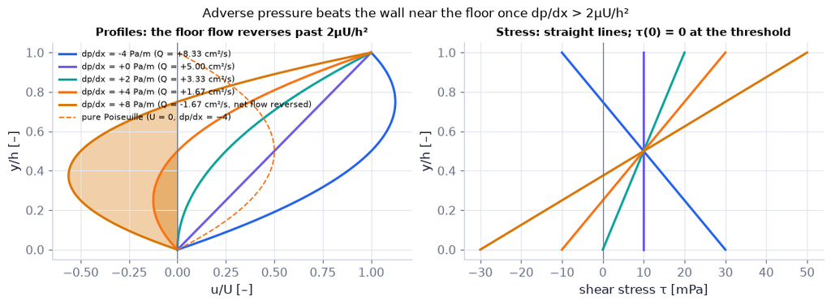

```python
h, U = 0.01, 0.1                                          # the tiny example's channel [m, m/s]
yy = np.linspace(0, h, 201)                               # heights [m]
cases = [-4.0, 0.0, 2.0, 4.0, 8.0]                        # dp/dx [Pa/m]: favourable, none, threshold, 2×, 4×
cols = [COLORS["blue"], COLORS["accent"], COLORS["teal"], COLORS["orange"], COLORS["amber"]]   # blue → amber
fig, (a1, a2) = plt.subplots(1, 2, figsize=(10, 3.6))    # the figure and its panels
for G_, c in zip(cases, cols):                           # one profile per pressure gradient
    u = ch08.channel_flow(yy, h, U=U, dpdx=G_)            # (8.5)
    Q_ = ch08.channel_flow_rate(h, U=U, dpdx=G_)[0]       # net flow rate [m²/s]: its sign matters beyond 6μU/h²
    tag = ", net flow reversed" if Q_ < 0 else ""        # past 6μU/h² the net flow itself runs backwards
    a1.plot(u/U, yy/h, color=c, lw=2, label=f"dp/dx = {G_:+g} Pa/m (Q = {1e4*Q_:+.2f} cm²/s{tag})")   # a curve (its label says which)
    if G_ > ch08.channel_backflow_threshold(U, h):       # shade the reversed layer (backflow) amber
        a1.fill_betweenx(yy/h, 0, u/U, where=u < 0, color=COLORS["amber"], alpha=0.35)   # backflow region shaded amber
    a2.plot(1e3*ch08.channel_shear_stress(yy, h, U=U, dpdx=G_), yy/h, color=c, lw=2)   # signed τ(y) [mPa]
a1.plot(ch08.channel_flow(yy, h, U=0.0, dpdx=-4.0)/U, yy/h, color=COLORS["orange"], ls="--", lw=1.2,   # a curve (its label says which)
        label="pure Poiseuille (U = 0, dp/dx = −4)")      # the parabola alone, for comparison
a1.axvline(0, color=COLORS["muted"], lw=0.8)             # reference line
a1.set_xlabel("u/U [–]"); a1.set_ylabel("y/h [–]"); a1.legend(fontsize=7, loc="upper left")   # labels with units
a1.set_title("Profiles: the floor flow reverses past 2μU/h²", fontsize=10)   # each panel says its message
a2.axvline(0, color=COLORS["muted"], lw=0.8)             # reference line
a2.set_xlabel("shear stress τ [mPa]"); a2.set_ylabel("y/h [–]"); a2.set_title("Stress: straight lines; τ(0) = 0 at the threshold", fontsize=10)   # labels with units
fig.suptitle("Adverse pressure beats the wall near the floor once dp/dx > 2μU/h²", fontsize=11)   # the figure's message
savefig(fig, "ch08", "c02_couette_poiseuille"); plt.show()   # save the PNG to outputs/ch08, then draw
```

**What you see.** Five profiles through (0, 0) and (1, 1); the two most adverse ones dip below zero near the floor (amber). At 4 Pa/m the net flow is still forward (Q > 0 in the legend); at 8 Pa/m, beyond the zero-flow gradient $6\mu U/h^2$ (6 Pa/m here), the net flow itself has reversed (Q < 0). The stresses are straight lines, and the dashed orange parabola is pure Poiseuille flow — our remake of Fig. 8.4.

**How to read it.** The slope of a profile at y = 0 is proportional to the floor stress; it crosses zero exactly at the 2 Pa/m curve (vertical at the floor), matching panel (b), where τ(0) = 0 for that case.

**What would change if…** …the gap were halved to 5 mm: the threshold $2\mu U/h^2$ quadruples to 8 Pa/m, so the 4 Pa/m case no longer reverses.

> 🔁 **Tools from earlier chapters used here** (see `knowledge/primers.md`)
- **slider_figure** — `slider_figure(fn, name, values, …)` precomputes one set of curves per slider position, so the plotly figure works on the web page without Python (Ch. 1 P17).

```python
h, U = 0.01, 0.1                                          # channel [m], wall speed [m/s]
yy = np.linspace(0, h, 81)                                # heights [m]


def frame(G_):                                            # the curves for one slider value dp/dx = G_ [Pa/m]
    u = ch08.channel_flow(yy, h, U=U, dpdx=G_)            # (8.5)
    return {"sum u(y)": (u, yy/h),                                                      # the profile
            "Couette part Uy/h": (U*yy/h, yy/h),                                        # the line
            "Poiseuille part": (ch08.channel_flow(yy, h, U=0.0, dpdx=G_), yy/h),        # the parabola
            "reversed layer (u < 0)": (np.where(u < 0, u, np.nan), yy/h)}               # backflow, if any


Gs = np.linspace(-8, 12, 21 if not FAST else 11)          # slider values dp/dx [Pa/m]
fig = slider_figure(frame, "dp/dx", Gs, unit="Pa/m", xlabel="u [m/s]", ylabel="y/h [–]", title="")
titles = []                                               # one title per slider value, with the verdict
for G_ in Gs:
    s = ch08.couette_poiseuille_state(h, U, G_)           # Q, backflow flag, threshold
    verdict = f"backflow below y = {1e3*s['y_reversal']:.1f} mm" if s["backflow"] else "all forward"
    titles.append(f"A line plus a parabola: Q = {1e4*s['Q']:.2f} cm²/s, {verdict}")
step_titles(fig, titles)                                 # numbers that follow the slider
colors = {"sum u(y)": COLORS["blue"], "Couette part Uy/h": COLORS["rose"], "Poiseuille part": COLORS["orange"],
          "reversed layer (u < 0)": COLORS["amber"]}     # colours by meaning
recolor(fig, colors, {"Couette part Uy/h": "dash", "Poiseuille part": "dash"})
fig.show()                                               # draw the interactive figure
```

[interactive chart not shown]

**What does the code above do?**

The slider re-evaluates (8.5), $u(y)=\frac Uh\,y-\frac1{2\mu}\frac{dp}{dx}\,y(h-y)$ for 21 pressure gradients (11 in FAST mode). Watch the blue sum cross u = 0 at the floor as dp/dx passes 2 Pa/m: the amber reversed layer appears and the title switches from "all forward" to "backflow".

> 🔁 **Tools from earlier chapters used here** (see `knowledge/primers.md`)
- **show_viz and the explainer tabs** — `show_viz("ch08", slug)` embeds an interactive explainer; its tabs are Walkthrough, Explore, Explain, Derivation, Equations, Code and Check (Ch. 1 P18).

#### 🎮 Interactive: When does fluid flow backwards in a channel?

**Why interactive rather than a static figure:** Drag the pressure gradient through zero and past $2\mu U/h^2$: the straight Couette part and the parabolic Poiseuille part add up in front of you, the reversed layer opens at the floor and the flow rate splits into its two contributions — a family of curves that a static figure can only sample.

**What to try:**

- Start at pure Couette (dp/dx = 0) and slowly raise dp/dx — watch the floor-slope readout reach 0 at 2 Pa/m.
- Press the 'zero net flow' preset: the Couette and Poiseuille bars cancel exactly at $dp/dx=6\mu U/h^2$.
- Click at mid-height in the profile view and read the arithmetic of u from its two parts.
- Halve the gap h and predict the new threshold before you look.

```python
show_viz("ch08", "couette_poiseuille_backflow")   # full-width explainer; ⤢ Full screen for more room
```

🎮 Interactive 1/9 When does fluid flow backwards in a channel? Open alone ↗

[interactive chart not shown]

📝 **Note.** **N11 [C] · Linear stress everywhere.** A constant pressure gradient and a *linear* stress τ(y) are general for any fully developed channel flow — they survive in turbulent flow for the time-averaged stress (Ch. 12 uses exactly this).

**What would change if…** …the channel were a round pipe? The same three moves (continuity, "function of x = function of R", integrate twice) work, but the Laplacian brings a 1/R — and a new rule: the solution must stay finite on the axis (C03).

> 🔁 **Recap — Shear stress in cylindrical coordinates** (Ch. 4 §4.5). In cylindrical coordinates (R, φ, z) the shear stress on a surface of constant R in the z-direction is $\tau_{zR}=\mu\big(\frac{\partial u_R}{\partial z}+\frac{\partial u_z}{\partial R}\big)$ (Ch. 4's `strain_rate(..., "cylindrical")` gives the same rate of strain).

### 🧩 Poiseuille pipe flow and Hagen–Poiseuille `C03`

*The question:* How much flows through a pipe for a given pressure drop — and why does halving the radius cut the flow sixteen-fold?

*In one line:* $u_z(R)=\frac{R^2-a^2}{4\mu}\frac{dp}{dz}$ *(8.6)*

#### The problem in plain words

Blood squeezing through a capillary, water in a garden hose, oil in a pipeline, air in the lungs' smallest airways: a pressure difference pushes fluid through a tube and viscosity at the wall holds it back. Doctors care because a slightly narrowed artery needs a much larger pressure; engineers because pumping costs follow the same law.

#### The idea

```
R=a  ───────────────  u=0,  |τ| max = τ₀
       ─────────►
         ──────────────►    u_max = 2V on the axis
       ─────────►
R=a  ───────────────
```

A paraboloid of velocity, fastest on the axis, zero at the wall; the stress grows linearly from the axis to the wall.

> 🔁 **Tools from earlier chapters used here** (see `knowledge/primers.md`)
- **cylindrical coordinates (R, φ, z) and unit vectors** — R is the distance from the axis, φ the angle round it, z along it; the unit vectors $\mathbf e_R$, $\mathbf e_\varphi$ turn with φ (Ch. 3 P88).

📝 **Note.** **N12 [B] · Set-up in (R, φ, z).** Take $\mathbf u=(0,0,u_z(R))$: continuity is automatic, the R- and φ-equations give $0=\partial p/\partial\varphi$ and $0=\partial p/\partial R$, so p = p(z). The z-equation is the balance below.

$$ 0=-\frac{dp}{dz}+\frac\mu R\frac{d}{dR}\Big(R\frac{du_z}{dR}\Big) $$

> 📎 **Primer — Laplacian in cylindrical coordinates.** `P186` · For a function of R only, $\nabla^2u=\frac1R\frac{d}{dR}\big(R\frac{du}{dR}\big)$ — the R inside the bracket comes from the circle's circumference growing with R. For an azimuthal velocity $u_\varphi(R)$ the φ-component of the *vector* Laplacian is $\frac{d}{dR}\big[\frac1R\frac{d(Ru_\varphi)}{dR}\big]$ (it contains an extra $-u_\varphi/R^2$ because the unit vector $\mathbf e_\varphi$ turns). Both come from `core.curvilinear`.

```python
import sympy as sp                                       # symbolic maths
R = sp.symbols('R', positive=True)                       # the radius as a positive symbol
u = R**2                                                 # a test profile
print(sp.simplify(sp.diff(R*sp.diff(u, R), R)/R))        # (1/R)(R u')' = 4 for u = R²
```

```
4
```

> 🔁 **Tools from earlier chapters used here** (see `knowledge/primers.md`)
- **natural logarithm and ln R → −∞** — ln R is the antiderivative of 1/R, and ln R → −∞ as R → 0 (Ch. 1 P36).
- **area element 2πR dR of a disc** — a thin ring of radius R and width dR has area 2πR dR, so a flow rate is $\int u\,2\pi R\,dR$ (Ch. 2 P83).

*Regularity at the axis.* A solution containing A ln R is infinite on the axis; a physical velocity is finite there, so A = 0.

#### 🧮 Derivation — Poiseuille pipe profile $u_z(R)=\frac{R^2-a^2}{4\mu}\frac{dp}{dz}$ `D06` (Eq. 8.6: $u_z(R)=\frac{R^2-a^2}{4\mu}\frac{dp}{dz}$)

**What we want to show.** Find the velocity across a round pipe driven by a constant pressure gradient.

**Assumptions.** Steady, fully developed (∂/∂z of u = 0), axisymmetric (∂/∂φ = 0) — step 1; no slip at R = a (step 9).

**The plan.**

1. Show continuity and advection are trivial.
2. Separate the z-equation.
3. Integrate twice; the axis and the wall fix the constants.

**Tools we use** (each explained before this point): Laplacian in cylindrical coordinates (primer P186) · regularity at the axis (gloss) · integrating twice (gloss).

**We start from**

$$ \mathbf u=(u_R,u_\varphi,u_z)=(0,\,0,\,u_z(R)),\qquad \frac{D\mathbf u}{Dt}=-\frac1\rho\nabla p+\nu\nabla^2\mathbf u\ \text{(8.1) in cylindrical form} $$

*In words:* steady, fully developed, axisymmetric flow along a round pipe

**Step 1 of 10 — Check continuity.**

$$ \nabla\cdot\mathbf u=\frac{\partial u_z}{\partial z}=0 $$

- *Why we can do this:* With u_R = u_φ = 0 only the z-term of the cylindrical divergence is left, and u_z does not depend on z (fully developed).
- *In words:* mass is conserved automatically.

**Step 2 of 10 — Evaluate the advective term.**

$$ (\mathbf u\cdot\nabla)u_z=u_z\frac{\partial u_z}{\partial z}=0 $$

- *Why we can do this:* Only the z-velocity is non-zero and nothing changes along z.
- *In words:* no acceleration: the equation is linear.

**Step 3 of 10 — Read the R- and φ-equations.**

$$ 0=\frac{\partial p}{\partial R},\ \ 0=\frac{\partial p}{\partial\varphi}\ \Rightarrow\ p=p(z) $$

- *Why we can do this:* All velocity terms in those components vanish, leaving only pressure.
- *In words:* pressure is uniform over each cross-section.

**Step 4 of 10 — Write the z-equation.**

$$ 0=-\frac{dp}{dz}+\frac\mu R\frac{d}{dR}\Big(R\frac{du_z}{dR}\Big) $$

- *Why we can do this:* The viscous term is μ times the axisymmetric Laplacian (1/R)d/dR(R du/dR) (P186).
- *In words:* pressure push balances friction across the pipe.

**Step 5 of 10 — Separate the variables.**

$$ \frac{dp}{dz}=\frac\mu R\frac{d}{dR}\Big(R\frac{du_z}{dR}\Big)=\text{const} $$

- *Why we can do this:* The left side depends on z only, the right on R only — the D03 argument makes both one constant.
- *In words:* the pressure falls linearly along the pipe.

**Step 6 of 10 — Multiply by R/μ and integrate.**

$$ R\frac{du_z}{dR}=\frac{R^2}{2\mu}\frac{dp}{dz}+A $$

- *Why we can do this:* d/dR(R u′) = (R/μ)dp/dz; its antiderivative is (R²/2μ)dp/dz plus a constant A. Keep the R in front of u′.
- *In words:* first integral.

**Step 7 of 10 — Divide by R and integrate again.**

$$ u_z(R)=\frac{R^2}{4\mu}\frac{dp}{dz}+A\ln R+B $$

- *Why we can do this:* u′ = (R/2μ)dp/dz + A/R; the antiderivative of A/R is A ln R.
- *In words:* the general solution has a parabola, a logarithm and a constant.

**Step 8 of 10 — Keep the velocity finite on the axis.**

$$ A=0 $$

- *Why we can do this:* ln R → −∞ as R → 0, but the velocity at the centre is finite; equivalently from step 6, R u′ → A must be 0 by symmetry.
- *In words:* the logarithm is removed.

**Step 9 of 10 — Apply no slip at the wall.**

$$ 0=\frac{a^2}{4\mu}\frac{dp}{dz}+B\ \Rightarrow\ B=-\frac{a^2}{4\mu}\frac{dp}{dz} $$

- *Why we can do this:* (8.3), $\mathbf t\cdot\mathbf U_s=(\mathbf t\cdot\mathbf u)_{\text{on the surface}}$: the fluid at R = a is at rest.
- *In words:* one condition fixes B.

**Step 10 of 10 — Combine.**

$$ u_z(R)=\frac{R^2-a^2}{4\mu}\frac{dp}{dz}\ \text{(8.6)} $$

- *Why we can do this:* Insert A = 0 and B into step 7 and factor 1/(4μ).
- *In words:* (8.6), $u_z(R)=\frac{R^2-a^2}{4\mu}\frac{dp}{dz}$, a paraboloid; positive when dp/dz < 0.

**Result**

$$ u_z(R)=\frac{R^2-a^2}{4\mu}\frac{dp}{dz}\ \text{(8.6)} $$

*In words:* the axial velocity is a paraboloid, fastest on the axis, zero at the wall.

**What it means.** The pipe profile is the channel's parabola rotated about the axis, but the factor is 1/(4μ), not 1/(2μ), because a disc's circumference grows with R.

**Check it.** u_z(a) = 0 ✓; units (m²)/(Pa s)(Pa/m) = m/s ✓; a = 1 mm, dp/dz = −1000 Pa/m → u(0) = 0.25 m/s; parity with Ch. 3's `pipe_profile` far downstream and Ch. 4's `exact_solution("pipe_poiseuille")` (the code cell after the tiny example of C03).

> ⚠️ **Common confusion (traps in `D06`):** Forgetting the R in R du/dR before the second integration; keeping A ln R; writing 1/(2μ).

📝 **Note.** **N13 [B] · Two constants, two conditions.** The general solution $u_z(R)=\frac{R^2}{4\mu}\frac{dp}{dz}+A\ln R+B$ keeps two constants; the axis removes A, the wall fixes $B=-\frac{a^2}{4\mu}\frac{dp}{dz}$ (steps 7–9 above).

📝 **Note.** **N14 [B], N15 [B], N16 [B] · Stress, wall stress, Hagen–Poiseuille.** Differentiating (8.6), $u_z(R)=\frac{R^2-a^2}{4\mu}\frac{dp}{dz}$ gives the linear stress (8.7) — zero on the axis, largest at the wall. The **wall stress** (8.8) is negative for forward flow (dp/dz < 0): the wall pulls the fluid back. A force balance on a slug of fluid gives the same line without the profile, which is why (8.8) also holds for averaged turbulent pipe flow (D07 steps 4–5; Ch. 12 builds the friction velocity on it). **Hagen–Poiseuille:** $Q=\int_0^au\,2\pi R\,dR=-\frac{\pi a^4}{8\mu}\frac{dp}{dz}$, $V=\frac{Q}{\pi a^2}=-\frac{a^2}{8\mu}\frac{dp}{dz}$, $u_{max}=2V$, and the Darcy friction factor f = 64/Re (ours).

$$ \tau=\mu\frac{\partial u_z}{\partial R}=\frac R2\frac{dp}{dz}\ \ \text{(8.7)},\qquad \tau_0=\frac a2\frac{dp}{dz} \qquad \text{(8.8)} $$

#### 🧮 Derivation — Stress $\tau=\frac R2\frac{dp}{dz}$, wall stress $\tau_0=\frac a2\frac{dp}{dz}$ as a force balance, Hagen–Poiseuille and f = 64/Re `D07` (Eq. 8.8: $\tau_0=\frac a2\frac{dp}{dz}$)

**What we want to show.** Get the shear stress, the wall stress (also from a force balance that holds for turbulent flow), the flow rate, the mean and maximum speeds and the friction factor.

**Assumptions.** Fully developed (momentum flux in = out, step 4); Darcy definition of f (step 9).

**The plan.**

1. Differentiate for τ.
2. Confirm τ₀ by a force balance on a slug.
3. Integrate over the cross-section.
4. Write the friction factor.

**Tools we use** (each explained before this point): cylindrical shear stress (R09) · control-volume force balance (Ch. 4 §4.4) · area element 2πR dR (gloss).

**We start from**

$$ u_z(R)=\frac{R^2-a^2}{4\mu}\frac{dp}{dz}\ \text{(8.6).} $$

**Step 1 of 10 — Write the shear stress.**

$$ \tau=\tau_{zR}=\mu\frac{du_z}{dR} $$

- *Why we can do this:* $\tau_{zR}=\mu(\frac{\partial u_R}{\partial z} +\frac{\partial u_z}{\partial R})$ (R09) with u_R = 0.
- *In words:* only the radial slope of u_z matters.

**Step 2 of 10 — Differentiate (8.6).**

$$ \tau=\frac{R}{2}\frac{dp}{dz}\ \text{(8.7)} $$

- *Why we can do this:* d/dR(R² − a²) = 2R; 2R/(4μ) × μ = R/2.
- *In words:* (8.7), $\tau=\mu\frac{\partial u_z}{\partial R}=\frac R2\frac{dp}{dz}$: stress grows linearly from zero on the axis.

**Step 3 of 10 — Evaluate at the wall.**

$$ \tau_0=\frac a2\frac{dp}{dz}\ \text{(8.8)} $$

- *Why we can do this:* Put R = a; it is negative for forward flow (dp/dz < 0): the wall holds the fluid back.
- *In words:* (8.8), $\tau_0=\frac a2\frac{dp}{dz}$, the largest stress in magnitude.

**Step 4 of 10 — Balance forces on a fluid slug.**

$$ \pi a^2[p(0)-p(L)]+2\pi aL\,\tau_0=0 $$

- *Why we can do this:* Steady and fully developed, so the momentum flux in equals out (Ch. 4 CV momentum): pressure force on the ends plus wall shear on the side sum to zero.
- *In words:* the pressure drop is spent on wall friction.

**Step 5 of 10 — Solve for the wall stress.**

$$ \tau_0=\frac{a}{2}\frac{p(L)-p(0)}{L}=\frac a2\frac{dp}{dz} $$

- *Why we can do this:* Divide by 2πaL; the profile was never used, so (8.8), $\tau_0=\frac a2\frac{dp}{dz}$ holds for averaged turbulent pipe flow too.
- *In words:* same result, more general.

**Step 6 of 10 — Set up the flow rate.**

$$ Q=\int_0^au_z\,2\pi R\,dR $$

- *Why we can do this:* A thin ring of radius R and width dR has area 2πR dR; summing velocity × area gives the volume per second.
- *In words:* add up rings.

**Step 7 of 10 — Evaluate the integral.**

$$ \int_0^a(R^2-a^2)R\,dR=\frac{a^4}4-\frac{a^4}2=-\frac{a^4}{4}\ \Rightarrow\ Q=-\frac{\pi a^4}{8\mu}\frac{dp}{dz} $$

- *Why we can do this:* Polynomial antiderivatives; then multiply by 2π/(4μ) and dp/dz.
- *In words:* Q ∝ a⁴ (Hagen–Poiseuille).

**Step 8 of 10 — Mean and maximum speeds.**

$$ V=\frac{Q}{\pi a^2}=-\frac{a^2}{8\mu}\frac{dp}{dz},\ \ u_{max}=u_z(0)=-\frac{a^2}{4\mu} \frac{dp}{dz}=2V $$

- *Why we can do this:* Divide by the area; evaluate (8.6), $u_z(R)=\frac{R^2-a^2}{4\mu}\frac{dp}{dz}$ on the axis.
- *In words:* the centre moves twice the average.

**Step 9 of 10 — Express the wall stress through V.**

$$ \lvert\tau_0\rvert=-\frac a2\frac{dp}{dz}=\frac{4\mu V}{a} $$

- *Why we can do this:* From step 8, dp/dz = −8μV/a²; insert in (8.8), $\tau_0=\frac a2\frac{dp}{dz}$. We want the Darcy factor f ≡ 8∣τ₀∣/(ρV²).
- *In words:* wall friction ∝ V.

**Step 10 of 10 — Form the friction factor.**

$$ f=\frac{8\lvert\tau_0\rvert}{\rho V^2}=\frac{32\mu}{\rho Va}=\frac{64}{\mathrm{Re}},\ \ \mathrm{Re}=\frac{V\,2a}{\nu} $$

- *Why we can do this:* Substitute step 9 and write 2a = d, the diameter the pipe Re uses.
- *In words:* the laminar line of the Moody chart.

**Result**

$$ \begin{array}{l}\tau=\mu\frac{\partial u_z}{\partial R}=\frac R2\frac{dp}{dz}\ \text{(8.7)},\qquad \tau_0=\frac a2\frac{dp}{dz}\ \text{(8.8)} \\ Q=-\frac{\pi a^4}{8\mu}\frac{dp}{dz},\quad V=-\frac{a^2}{8\mu}\frac{dp}{dz},\quad u_{max}=2V,\quad f=\frac{64}{\mathrm{Re}}\end{array} $$

*In words:* the pipe's resistance grows as 1/a⁴.

**What it means.** Halving a pipe's radius at fixed pressure drop cuts the flow 16-fold — why narrowed arteries matter. f = 64/Re is where Ch. 12's turbulent friction curves start.

**Check it.** Units: Q in m⁴/(Pa s) × Pa/m = m³/s ✓. Numbers a = 1 mm, dp/dz = −1000 Pa/m: V = 0.125 m/s, Q = 3.93 × 10⁻⁷ m³/s, τ₀ = −0.5 Pa, Re = 250, f = 0.256.

> ⚠️ **Common confusion (traps in `D07`):** τ₀ is negative for forward flow; ∫(R² − a²)R dR = −a⁴/4 (sign); Re uses the diameter and the mean velocity.

#### ✏️ Tiny example: a 2 mm tube at dp/dz = −1000 Pa/m

a = 1 mm, μ = 10⁻³ Pa s, water.

1. $V=-\frac{a^2}{8\mu}\frac{dp}{dz}=\frac{10^{-6}}{8\times10^{-3}}\times1000=0.125$ m/s.
2. $u_{max}=2V=0.25$ m/s.
3. $Q=\pi a^2V=\pi\times10^{-6}\times0.125=3.93\times10^{-7}$ m³/s (0.39 mL/s).
4. $\tau_0=\frac a2\frac{dp}{dz}=-0.5$ Pa.
5. $\mathrm{Re}=V\cdot2a/\nu=0.125\times0.002/10^{-6}=250$: laminar ✓.
6. f = 64/250 = 0.256, and the definition $8\lvert\tau_0\rvert/(\rho V^2)=8\times0.5/(1000\times0.0156)=0.256$ ✓.
7. Halve a: V falls 4×, the area 4×, so Q falls 16×.

```python
a, G = 1e-3, -1000.0                                     # radius [m], dp/dz [Pa/m] (favourable: pressure falls along z)
Q, V, umax = ch08.pipe_flow_rate(a, G)                   # Hagen–Poiseuille: Q [m³/s], mean V and axis speed [m/s]
print(f"Q = {Q:.4g} m³/s, V = {V:.4g} m/s, u_max = {umax:.4g} m/s")
print("τ₀ =", ch08.pipe_wall_stress(a, G), "Pa;  τ(R = a/2) =", ch08.pipe_shear_stress(0.5e-3, G), "Pa")   # (8.8), (8.7)
Re = V*2*a/NU_W                                          # pipe Reynolds number (diameter, mean speed)
print(f"Re = {Re:.0f}, f = {ch08.pipe_friction_factor(Re):.4g}")   # f = 64/Re
R = np.linspace(0, a, 5)                                 # five radii from the axis to the wall [m]
print("(8.6):         ", ch08.pipe_poiseuille(R, a, G))  # u_z(R) [m/s]
print("Ch. 3 far down:", ch03.pipe_profile(R, z=1e3, U_mean=V, R=a))   # Ch. 3's developing profile, 1 km downstream
print("Ch. 4 on axis: ", NS.exact_solution("pipe_poiseuille", np.array([0.0, 0.0, 0.0]), G=-G, R=a)[0][2])   # Ch. 4 (G = −dp/dz)
pp = ch08.parallel_flow_sympy("pipe")                    # D06 symbolically
print("sympy:", pp["profile"], "  unbounded term:", pp["unbounded_term"], "  (G here is the symbol for dp/dz)")
```

```
Q = 3.927e-07 m³/s, V = 0.125 m/s, u_max = 0.25 m/s
τ₀ = -0.5 Pa;  τ(R = a/2) = -0.25 Pa
Re = 250, f = 0.256
(8.6):          [ 0.25    0.2344  0.1875  0.1094 -0.    ]
Ch. 3 far down: [0.25   0.2344 0.1875 0.1094 0.    ]
Ch. 4 on axis:  0.25
```

```
sympy: G*(R**2 - a**2)/(4*mu)   unbounded term: C1*log(R)   (G here is the symbol for dp/dz)
```

**What does the code above do?**

1. `pipe_flow_rate` returns Q, V and u_max = 2V: 3.93 × 10⁻⁷ m³/s, 0.125 m/s, 0.25 m/s (the tiny example).
2. `pipe_wall_stress` and `pipe_shear_stress` are (8.8), $\tau_0=\frac a2\frac{dp}{dz}$ and (8.7), $\tau=\mu\frac{\partial u_z}{\partial R}=\frac R2\frac{dp}{dz}$: −0.5 Pa at the wall, half of it at mid-radius.
3. Three independent earlier implementations agree with (8.6), $u_z(R)=\frac{R^2-a^2}{4\mu}\frac{dp}{dz}$: this chapter's formula, Ch. 3's developing profile evaluated far downstream, and Ch. 4's exact-solution preset on the axis (0.25 m/s).
4. `parallel_flow_sympy("pipe")` returns the profile and the term $C_1\ln R$ it discarded because it is unbounded on the axis.

*(`np.trapezoid`, reminded in C02, integrates the sampled profile below.)*

```python
RR = np.linspace(0, a, 2001)                             # 2001 radii [m]
Q_trap = np.trapezoid(ch08.pipe_poiseuille(RR, a, G) * 2*np.pi*RR, RR)   # Q = ∫ u 2πR dR by trapezoids [m³/s]
print(f"trapezoid Q = {Q_trap:.6g}, formula Q = {Q:.6g} m³/s")
assert np.allclose(Q_trap, Q, rtol=1e-6)                 # same flow rate
F_pressure = -np.pi*a**2*G*1.0                           # pressure force on a 1 m slug: πa²[p(0) − p(L)] [N]
F_wall = -2*np.pi*a*1.0*ch08.pipe_wall_stress(a, G)      # wall friction force on its side: −2πaL τ₀ [N]
assert np.isclose(F_pressure, F_wall)                    # D07 step 4: the pressure push equals the wall drag
print(f"force balance on a 1 m slug: pressure {F_pressure:.4g} N = wall friction {F_wall:.4g} N")
```

```
trapezoid Q = 3.92699e-07, formula Q = 3.92699e-07 m³/s
force balance on a 1 m slug: pressure 0.003142 N = wall friction 0.003142 N
```

```
Re = V·2a/ν reaches 2000 at a = 2.00 mm
```

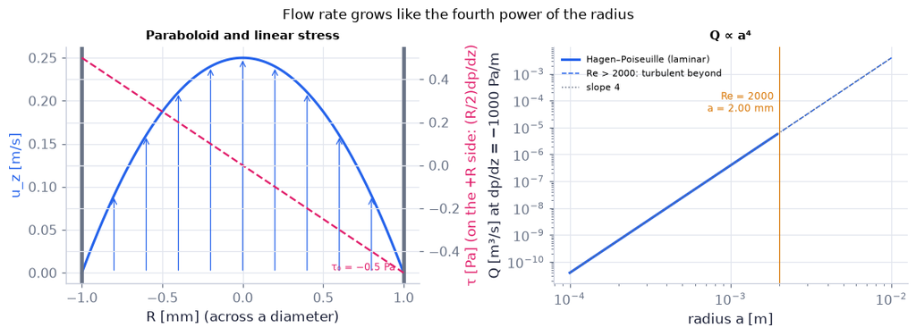

```python
a, G = 1e-3, -1000.0                                      # the tiny example's tube
fig, (a1, a2) = plt.subplots(1, 2, figsize=(10, 3.6))    # the figure and its panels
R = np.linspace(-a, a, 201)                               # a diameter, from wall to wall [m]
u = ch08.pipe_poiseuille(np.abs(R), a, G)                 # (8.6) along the diameter [m/s]
a1.plot(1e3*R, u, color=COLORS["blue"], lw=2, label="u_z(R), (8.6)")   # a curve (its label says which)
for Rk in np.linspace(-0.8*a, 0.8*a, 9):                  # nine velocity arrows (blue)
    a1.annotate("", xy=(1e3*Rk, ch08.pipe_poiseuille(abs(Rk), a, G)), xytext=(1e3*Rk, 0),   # an arrow
                arrowprops=dict(arrowstyle="->", color=COLORS["blue"], lw=0.8))   # its style
a1.axvline(-1, color=COLORS["muted"], lw=3); a1.axvline(1, color=COLORS["muted"], lw=3)   # the pipe walls
a1.set_xlabel("R [mm] (across a diameter)"); a1.set_ylabel("u_z [m/s]", color=COLORS["blue"])   # labels with units
b1 = a1.twinx()                                           # second axis for the stress (rose)
b1.plot(1e3*R, np.sign(R)*ch08.pipe_shear_stress(np.abs(R), G), color=COLORS["rose"], lw=1.5, ls="--")   # τ = (R/2) dp/dz
b1.set_ylabel("τ [Pa] (on the +R side: (R/2)dp/dz)", color=COLORS["rose"]); b1.axhline(0, color=COLORS["grid"], lw=0.8)   # labels with units
b1.text(0.55, ch08.pipe_wall_stress(a, G), "τ₀ = −0.5 Pa", color=COLORS["rose"], fontsize=8, va="bottom")   # a label on the plot
a1.set_title("Paraboloid and linear stress", fontsize=10)   # each panel says its message
aa = np.geomspace(1e-4, 1e-2, 60)                         # radii from 0.1 mm to 1 cm [m]
QV = np.array([ch08.pipe_flow_rate(a_, G)[:2] for a_ in aa])   # (Q, V) for each radius (the function takes one a)
Qs, Res = QV[:, 0], QV[:, 1]*2*aa/NU_W                    # Q(a) [m³/s] and Re(a) = V·2a/ν with the mean speed
lam = Res < 2000                                          # where the laminar law is trustworthy
a2.loglog(aa[lam], Qs[lam], color=COLORS["blue"], lw=2, label="Hagen–Poiseuille (laminar)")   # a curve (its label says which)
a2.loglog(aa[~lam], Qs[~lam], color=COLORS["blue"], lw=1, ls="--", label="Re > 2000: turbulent beyond")   # a curve (its label says which)
a2.loglog(aa, Qs[0]*(aa/aa[0])**4, color=COLORS["muted"], lw=1, ls=":", label="slope 4")   # a curve (its label says which)
a_cross = optimize.brentq(lambda a_: ch08.pipe_flow_rate(a_, G)[1]*2*a_/NU_W - 2000, 1e-4, 1e-2)   # Re(a) = 2000 exactly [m]
print(f"Re = V·2a/ν reaches 2000 at a = {1e3*a_cross:.2f} mm")   # a³ = 4μν·2000/|dp/dz| = 8 × 10⁻⁹ m³
a2.axvline(a_cross, color=COLORS["amber"], lw=0.8); a2.text(a_cross*0.93, Qs[0]*1e6, f"Re = 2000\na = {1e3*a_cross:.2f} mm", fontsize=8, color=COLORS["amber"], ha="right")   # reference line
a2.set_xlabel("radius a [m]"); a2.set_ylabel("Q [m³/s] at dp/dz = −1000 Pa/m"); a2.legend(fontsize=7, loc="upper left")   # labels with units
a2.set_title("Q ∝ a⁴", fontsize=10)                      # each panel says its message
fig.suptitle("Flow rate grows like the fourth power of the radius", fontsize=11)   # the figure's message
savefig(fig, "ch08", "c03_pipe"); plt.show()             # save the PNG to outputs/ch08, then draw
```

**What you see.** (a) a parabola across the diameter with the stress line (rose dashed) growing from zero on the axis to −0.5 Pa at the wall — our remake of the book's pipe sketch `N104`; (b) a straight log–log line of slope 4.

**How to read it.** Each decade of radius gives four decades of flow; past Re = 2000 (the amber line, a = 2.00 mm, printed above) the laminar line is no longer trustworthy, so it is dashed.

**What would change if…** …the artery narrowed by 20 %: $0.8^4=0.41$ — the same pressure pushes 59 % less blood, so the heart must raise the pressure 2.4× to keep Q.

```python
G = -1000.0                                               # dp/dz [Pa/m]
s_ = np.linspace(0, 1, 60)                                # R/a from the axis to the wall [–]


def frame(a_):                                            # curves for one radius a_ [m]
    return {"u_z(R), (8.6)": (s_, ch08.pipe_poiseuille(s_*a_, a_, G))}   # the paraboloid across the radius


radii = np.geomspace(2e-4, 2e-3, 13 if not FAST else 7)   # slider values a [m]
fig = slider_figure(frame, "a", radii, unit="m", xlabel="R/a [–]", ylabel="u_z [m/s]", title="")
titles = []                                               # Q and Re for each radius, in the title
for a_ in radii:
    Q_, V_, _ = ch08.pipe_flow_rate(a_, G)                # Hagen–Poiseuille flow rate and mean speed
    titles.append(f"a = {1e3*a_:.2f} mm: Q = {1e6*Q_:.3g} mL/s, Re = {V_*2*a_/NU_W:.0f} — Q ∝ a⁴")
step_titles(fig, titles)                                 # numbers that follow the slider
recolor(fig, {"u_z(R), (8.6)": COLORS["blue"]})           # velocity profiles in blue
fig.show()                                               # draw the interactive figure
```

[interactive chart not shown]

**What does the code above do?**

Each slider step is one radius between 0.2 and 2 mm at the same dp/dz; the title prints Q and Re. Doubling a multiplies the centre speed by 4 and Q by 16 (compare the steps near a = 0.5 mm and 1 mm); past a = 2.00 mm (computed with the figure above) Re would exceed 2000.

**What would change if…** …the walls moved instead of a pressure pushing — sideways, round the axis? Then the velocity is azimuthal, $u_\varphi(R)$, and the same reduction gives circular Couette flow (C04).

> 🔁 **Recap — A viscous flow with no net viscous force** (Ch. 5 §5.1). Outside a spinning cylinder the ideal-vortex velocity $u_\varphi=\Gamma/2\pi R$ has shear stress $\sigma_{R\varphi}=\mu R\frac{d}{dR}\big(\frac{u_\varphi}R\big)=-\frac{2\mu\Omega_1R_1^2}{R^2}$ but no net viscous force on any fluid element, because $\mu\nabla^2\mathbf u=-\mu\nabla\times\boldsymbol\omega=0$ when $\boldsymbol\omega=0$ (Ch. 5).

> 🔁 **Recap — Power in = dissipation** (Ch. 5 §5.1). The torque that keeps the cylinder spinning does work at the rate $-2\pi R_1\sigma_{R\varphi}u_\varphi$ per unit length (positive: $\sigma_{R\varphi}<0$), and all of it is dissipated in the fluid: $4\pi\mu\Omega_1^2R_1^2$ (Ch. 5's `dissipation_outside_cylinder`; Exercise 8.12). The book writes the power as $(2\pi R_1)\tau_{R\varphi}u_\varphi$, which is negative with its own sign of σ_Rφ — the power delivered *to* the fluid carries a minus sign.

> 🔁 **Recap — Solid-body rotation** (Ch. 5 §5.1). A tank of fluid spun long enough rotates like a solid: $u_\theta=\omega r/2$ *(5.1)* with the vorticity ω = 2Ω everywhere, i.e. $u_\varphi=\Omega R$ — no shear at all.

> 🔁 **Tools from earlier chapters used here** (see `knowledge/primers.md`)
- **curl of a curl identity (∇²u = −∇×ω)** — $\nabla\times(\nabla\times\mathbf u)=\nabla(\nabla\cdot\mathbf u)-\nabla^2\mathbf u$, so for ∇·u = 0 the viscous term is $\mu\nabla^2\mathbf u=-\mu\nabla\times\boldsymbol\omega$ (Ch. 4 P122).

### 🧩 Circular Couette flow and its two limits `C04`

*The question:* What swirl is set up between two rotating cylinders, and what happens when one of them is taken away?

*In one line:* $u_\varphi=\frac{1}{R_2^2-R_1^2}\Big\{\big[\Omega_2R_2^2-\Omega_1R_1^2\big]R-\big[\Omega_2-\Omega_1\big]\frac{R_1^2R_2^2}{R}\Big\}$ *(8.10)*

#### The problem in plain words

Stir tea between a spoon handle and the cup wall; spin the inner cylinder of a lab rig (a Taylor–Couette cell, the classic apparatus of Ch. 11) or a viscometer. The fluid between two concentric rotating walls settles into a steady swirl. We want that swirl, the pressure that holds it in its circle, and what it becomes when the outer wall is at infinity or the inner one vanishes — the two vortices of Ch. 5.

#### The idea

| piece | u_φ | vorticity | shear | appears alone when |
| --- | --- | --- | --- | --- |
| solid-body rotation | AR | 2A | none | no inner cylinder (R₁ → 0) |
| free (line) vortex | B/R | 0 | yes, but no net force | outer wall at infinity (R₂ → ∞, Ω₂ = 0) |

Only two swirls satisfy the viscous balance, and the walls choose the mix.

> 🔁 **Tools from earlier chapters used here** (see `knowledge/primers.md`)
- **centripetal acceleration in cylindrical coordinates** — a particle going round a circle of radius R at speed u_φ accelerates toward the axis at $u_\varphi^2/R$ even at constant speed, because $\mathbf e_\varphi$ turns (Ch. 3 P105).

📝 **Note.** **N17 [B] · Two equations left.** With $\mathbf u=(0,u_\varphi(R),0)$: the R-equation (first below) says pressure rises outward to supply the centripetal acceleration; the φ-equation (second) is a pure viscous balance (no pressure, no advection).

$$ -\frac{u_\varphi^2}{R}=-\frac1\rho\frac{dp}{dR},\qquad 0=\mu\frac{d}{dR}\Big[\frac1R\frac{d}{dR}(Ru_\varphi)\Big] $$

> 📎 **Primer — Euler–Cauchy (equidimensional) ODE.** `P187` · An ODE in which every term has the form $R^k\,d^ku/dR^k$ (each derivative comes with the same power of R) is solved by trying $u=R^\lambda$: every term becomes a constant times $R^\lambda$, so λ must solve a polynomial. For $R^2u''+Ru'-u=0$ the polynomial is $\lambda^2-1=0$, so $u=AR+B/R$.

```python
import sympy as sp                                       # symbolic maths
R, lam = sp.symbols('R lambda')                          # radius and the trial exponent λ
u = R**lam                                               # trial power
print(sp.factor(sp.simplify((R**2*sp.diff(u, R, 2) + R*sp.diff(u, R) - u)/u)))   # (lambda - 1)*(lambda + 1)
```

```
(lambda - 1)*(lambda + 1)
```

#### 🧮 Derivation — Circular Couette flow $u_\varphi=AR+B/R$ `D08` (Eq. 8.10: $u_\varphi=\frac{1}{R_2^2-R_1^2}\Big\{\big[\Omega_2R_2^2-\Omega_1R_1^2\big]R-\big[\Omega_2-\Omega_1\big]\frac{R_1^2R_2^2}{R}\Big\}$)

**What we want to show.** Find the swirl between an inner cylinder (R₁, Ω₁) and an outer cylinder (R₂, Ω₂).

**Assumptions.** Steady, axisymmetric (∂/∂φ = 0), no axial flow, infinitely long (steps 1–4); no slip (step 8).

**The plan.**

1. Reduce the momentum equations.
2. Integrate the φ-equation twice.
3. Fix A and B at the walls.

**Tools we use** (each explained before this point): φ-component of the cylindrical vector Laplacian (primer P186) · Euler–Cauchy ODE (primer P187) · 2 × 2 system (P57).

**We start from**

$$ \mathbf u=(u_R,u_\varphi,u_z)=(0,\,u_\varphi(R),\,0) $$

*In words:* steady swirl between two infinitely long concentric cylinders

**Step 1 of 10 — Check continuity.**

$$ \nabla\cdot\mathbf u=\frac1R\frac{\partial u_\varphi}{\partial\varphi}=0 $$

- *Why we can do this:* Only the φ-term of the divergence could survive and nothing depends on φ.
- *In words:* mass is conserved automatically.

**Step 2 of 10 — Evaluate the advective acceleration.**

$$ (\mathbf u\cdot\nabla)\mathbf u=-\frac{u_\varphi^2}{R}\mathbf e_R $$

- *Why we can do this:* For a purely azimuthal flow the moving basis leaves only the centripetal part (P105, Ch. 4 §4.7).
- *In words:* the fluid accelerates toward the axis.

**Step 3 of 10 — Write the R-momentum.**

$$ -\frac{u_\varphi^2}{R}=-\frac1\rho\frac{dp}{dR} $$

- *Why we can do this:* The R-component of the viscous term, −(2/R²)∂u_φ/∂φ, vanishes; pressure supplies the centripetal force.
- *In words:* pressure rises outward.

**Step 4 of 10 — Write the φ-momentum.**

$$ 0=\mu\frac{d}{dR}\Big[\frac1R\frac{d}{dR}(Ru_\varphi)\Big] $$

- *Why we can do this:* ∂p/∂φ = 0 by symmetry and the advective term has no φ-part; the viscous term is the φ-component of the vector Laplacian (P186).
- *In words:* a pure friction balance.

**Step 5 of 10 — Integrate once.**

$$ \frac1R\frac{d}{dR}(Ru_\varphi)=2A $$

- *Why we can do this:* Fundamental theorem of calculus; naming the constant 2A keeps the final form clean.
- *In words:* first integral.

**Step 6 of 10 — Multiply by R and integrate.**

$$ Ru_\varphi=AR^2+B $$

- *Why we can do this:* d(Ru_φ)/dR = 2AR has antiderivative AR² plus a new constant B.
- *In words:* the angular momentum per mass is a quadratic in R.

**Step 7 of 10 — Divide by R.**

$$ u_\varphi(R)=AR+\frac BR\ \text{(8.9)} $$

- *Why we can do this:* Solves the Euler–Cauchy ODE R²u″ + Ru′ − u = 0 (trial R^λ gives λ = ±1, P187).
- *In words:* (8.9), $u_\varphi(R)=AR+\frac BR$: solid-body rotation plus a free vortex.

**Step 8 of 10 — Apply no slip on both cylinders.**

$$ \Omega_1R_1^2=AR_1^2+B,\ \ \Omega_2R_2^2=AR_2^2+B $$

- *Why we can do this:* The wall speed is ΩR (not Ω); we multiplied each condition by its radius so B stands alone.
- *In words:* two equations for A, B.

**Step 9 of 10 — Subtract to find A.**

$$ A=\frac{\Omega_2R_2^2-\Omega_1R_1^2}{R_2^2-R_1^2} $$

- *Why we can do this:* Subtracting eliminates B; divide by R₂² − R₁².
- *In words:* A is set by the difference of the walls' angular momenta.

**Step 10 of 10 — Back-substitute for B and insert.**

$$ B=-\frac{(\Omega_2-\Omega_1)R_1^2R_2^2}{R_2^2-R_1^2},\ \ u_\varphi=\frac{[\Omega_2 R_2^2-\Omega_1R_1^2]R-[\Omega_2-\Omega_1]R_1^2R_2^2/R}{R_2^2-R_1^2}\ \text{(8.10)} $$

- *Why we can do this:* B = Ω₁R₁² − AR₁²; over a common denominator the Ω₂R₂²R₁² terms combine; then put A, B into (8.9), $u_\varphi(R)=AR+\frac BR$.
- *In words:* (8.10), $u_\varphi=\frac{1}{R_2^2-R_1^2}\Big\{\big[\Omega_2R_2^2-\Omega_1R_1^2\big]R-\big[\Omega_2-\Omega_1\big]\frac{R_1^2R_2^2}{R}\Big\}$.

**Result**

$$ \begin{array}{l}u_\varphi=\frac{1}{R_2^2-R_1^2}\Big\{\big[\Omega_2R_2^2-\Omega_1R_1^2\big]R-\big[\Omega_2-\Omega_1\big]\frac{R_1^2R_2^2}{R}\Big\}\ \text{(8.10)} \\ A=\frac{\Omega_2R_2^2-\Omega_1R_1^2}{R_2^2-R_1^2},\quad B=-\frac{(\Omega_2-\Omega_1)R_1^2R_2^2}{R_2^2-R_1^2}\end{array} $$

*In words:* the walls choose how much rigid rotation and how much free vortex.

**What it means.** Vorticity is 2A everywhere (the B/R part is irrotational); Ch. 11's Rayleigh criterion for Taylor vortices is written in A and B.

**Check it.** u_φ(R₁) = Ω₁R₁ and u_φ(R₂) = Ω₂R₂ ✓; Ω₁ = Ω₂ = Ω gives A = Ω, B = 0 (rigid rotation) ✓; numbers R₁ = 1 cm, R₂ = 2 cm, Ω₁ = 1 rad/s, Ω₂ = 0: A = −1/3 s⁻¹, B = 1.33 × 10⁻⁴ m²/s, u_φ(1.5 cm) = 3.9 mm/s.

> ⚠️ **Common confusion (traps in `D08`):** The φ-equation contains no pressure and no advection; the first integral is (1/R)(Ru_φ)′ = 2A; the wall speed is ΩR.

📝 **Note.** **N18 [B], N19 [B] · The general swirl and its constants.** The general solution (8.9) is solid-body rotation plus a line vortex; the walls give $A=\frac{\Omega_2R_2^2-\Omega_1R_1^2}{R_2^2-R_1^2}$ and $B=-\frac{(\Omega_2-\Omega_1)R_1^2R_2^2}{R_2^2-R_1^2}$ (D08 steps 8–10).

$$ u_\varphi(R)=AR+\frac BR \qquad \text{(8.9)} $$

> 🔁 **Tools from earlier chapters used here** (see `knowledge/primers.md`)
- **limits and orders of smallness** — as R₂ → ∞ a ratio like R₁²/R₂² → 0; dividing top and bottom by the growing quantity first makes the limit visible (Ch. 2 P68).

#### 🧮 Derivation — The limits $u_\varphi=\Omega_1R_1^2/R$ and $u_\varphi=\Omega_2R$ `D09` (Eq. 8.11: $u_\varphi(R)=\frac{\Omega_1R_1^2}{R}$)

**What we want to show.** Show that circular Couette flow contains the ideal vortex and solid-body rotation as limits.

**Assumptions.** Ω₂ = 0 in the first limit (step 2); Ω₁ = 0 in the second (step 5).

**The plan.**

1. Send the outer wall to infinity at rest.
2. Remove the inner cylinder.

**Tools we use** (each explained before this point): limits (P68) · circulation (Ch. 5 §5.1).

**We start from**

$$ u_\varphi(R)=AR+\frac BR\ \text{(8.9)},\qquad A=\frac{\Omega_2R_2^2-\Omega_1R_1^2}{R_2^2-R_1^2},\ \ B=-\frac{(\Omega_2-\Omega_1)R_1^2R_2^2}{R_2^2-R_1^2} $$

*In words:* the general swirl and its constants from D08

**Step 1 of 6 — Divide through by R₂².**

$$ A=\frac{\Omega_2-\Omega_1R_1^2/R_2^2}{1-R_1^2/R_2^2},\ \ B=-\frac{(\Omega_2-\Omega_1)R_1^2} {1-R_1^2/R_2^2} $$

- *Why we can do this:* Dividing numerator and denominator by R₂² makes the limit R₂ → ∞ visible: every R₁²/R₂² → 0.
- *In words:* the same constants, ready for the limit.

**Step 2 of 6 — Let R₂ → ∞ with Ω₂ = 0.**

$$ A\to0,\ \ B\to\Omega_1R_1^2 $$

- *Why we can do this:* R₁²/R₂² → 0; with Ω₂ = 0 the numerator of A vanishes (with Ω₂ ≠ 0, A → Ω₂ instead).
- *In words:* only the vortex part survives.

**Step 3 of 6 — Insert into (8.9).**

$$ u_\varphi(R)=\frac{\Omega_1R_1^2}{R}\ \text{(8.11)} $$

- *Why we can do this:* u_φ = AR + B/R with A = 0.
- *In words:* (8.11), $u_\varphi(R)=\frac{\Omega_1R_1^2}{R}$: speed falls as 1/R.

**Step 4 of 6 — Compute the circulation.**

$$ \Gamma=\oint\mathbf u\cdot d\mathbf l=2\pi Ru_\varphi=2\pi\Omega_1R_1^2 $$

- *Why we can do this:* Around a circle u is tangent and constant in size; the result does not depend on R — the signature of the ideal vortex (5.2) u = Γ/(2πR).
- *In words:* a viscous flow identical to the ideal vortex.

**Step 5 of 6 — Let R₁ → 0 with Ω₁ = 0.**

$$ A=\frac{\Omega_2R_2^2}{R_2^2}=\Omega_2,\ \ B=-\frac{\Omega_2R_1^2R_2^2}{R_2^2-R_1^2}\to0 $$

- *Why we can do this:* Put Ω₁ = 0 and R₁ = 0 in D08's A and B.
- *In words:* only rigid rotation survives.

**Step 6 of 6 — Insert into (8.9).**

$$ u_\varphi(R)=\Omega_2R\ \text{(8.12)} $$

- *Why we can do this:* u_φ = AR with B = 0.
- *In words:* (8.12), $u_\varphi(R)=\Omega_2R$: the tank's fluid turns like a solid (5.1), $u_\theta=\omega r/2\ (=\Omega r\ \text{with vorticity}\ \omega=2\Omega)$.

**Result**

$$ u_\varphi(R)=\frac{\Omega_1R_1^2}{R}\ \text{(8.11)},\qquad u_\varphi(R)=\Omega_2R\ \text{(8.12)} $$

*In words:* remove one wall and you get one of the two basic vortices of Ch. 5.

**What it means.** The flow outside a spinning rod is viscous but irrotational: shear exists (R10), no net viscous force acts, and all the power put in is dissipated (R11).

**Check it.** (8.11), $u_\varphi(R)=\frac{\Omega_1R_1^2}{R}$ at R = R₁ gives Ω₁R₁ ✓; the R₂ = 10⁶R₁ value of (8.10), $u_\varphi=\frac{1}{R_2^2-R_1^2}\Big\{\big[\Omega_2R_2^2-\Omega_1R_1^2\big]R-\big[\Omega_2-\Omega_1\big]\frac{R_1^2R_2^2}{R}\Big\}$ agrees with (8.11) to 1e-10; Ch. 5's `rotating_cylinder_flow(r, a, omega=2Ω₁)` gives the same.

> ⚠️ **Common confusion (traps in `D09`):** Divide by R₂² before the limit; Ω₂ = 0 is needed or A → Ω₂; Ch. 5's function takes ω = 2Ω₁.

📝 **Note.** **N21 [B] · A viscous flow that is irrotational.** With R₂ → ∞ and Ω₂ = 0, (8.11), $u_\varphi(R)=\frac{\Omega_1R_1^2}{R}$ is the ideal vortex $u_\theta=\frac{\Gamma}{2\pi r}$ *(5.2)* with $\Gamma=2\pi\Omega_1R_1^2$ — shear stress everywhere, yet zero net viscous force (R10): the only completely irrotational viscous solution in the book. If gravity acts along the axis, the free surface dips toward the cylinder (Fig. 8.7, remade below). ⚠️ Ch. 5's `rotating_cylinder_flow(r, a, omega)` takes the cylinder's *vorticity* ω = 2Ω₁. The other limit is R12's solid-body rotation, $u_\varphi=\Omega_2R$ *(8.12)*.

#### ✏️ Tiny example: a 1 cm cylinder spinning at 1 rad/s inside a fixed 2 cm cup

R₁ = 0.01 m, R₂ = 0.02 m, Ω₁ = 1 rad/s, Ω₂ = 0.

1. $A=\frac{0-1\times10^{-4}}{4\times10^{-4}-10^{-4}}=-\frac13$ s⁻¹.
2. $B=-\frac{(0-1)\times10^{-4}\times4\times10^{-4}}{3\times10^{-4}}=1.333\times10^{-4}$ m²/s.
3. At mid-gap R = 0.015 m: $u_\varphi=-\frac13\times0.015+\frac{1.333\times10^{-4}}{0.015}=-0.0050+0.0089=0.0039$ m/s.
4. Checks: at R₁, −0.00333 + 0.01333 = 0.0100 = Ω₁R₁ ✓; at R₂, −0.00667 + 0.00667 = 0 ✓.

```python
R1, R2 = 0.01, 0.02                                      # cylinder radii [m]
u, A, B = ch08.circular_couette(0.015, R1, R2, 1.0, 0.0, return_coeffs=True)   # (8.10) at mid-gap, and A, B of (8.9)
print(f"u_φ(1.5 cm) = {u:.4g} m/s, A = {A:.4g} 1/s, B = {B:.4g} m²/s")   # show the numbers
print("R₂ = ∞ (free vortex):", ch08.circular_couette(0.05, R1, np.inf, 1.0, 0.0),   # show the numbers
      "  Ch. 5 with ω = 2Ω₁:", ch05.rotating_cylinder_flow(0.05, R1, 2*1.0)[0])   # (8.11) vs Ch. 5 at R = 5 cm
print("R₁ = 0 (solid body): ", ch08.circular_couette(0.01, 0.0, R2, 0.0, 3.0),   # show the numbers
      "  Ch. 5 solid body:", VX.solid_body_rotation(0.01, 3.0))               # (8.12) vs Ch. 5 at R = 1 cm, Ω₂ = 3 rad/s
print(f"pressure rise across the gap: {ch08.circular_couette_pressure(R2, R1, R2, 1.0, 0.0):.4g} Pa")   # show the numbers
pw = ch08.circular_couette_power(R1, R2, 1.0, 0.0, mu=MU_W)   # torques, power and dissipation per metre of length
print({k: f"{pw[k]:.4g}" for k in ("torque_inner", "torque_outer", "power_in", "power_out", "dissipation")})   # show the numbers
print("sympy profile:", ch08.parallel_flow_sympy("circular_couette")["profile"])   # D08 symbolically
```

```
u_φ(1.5 cm) = 0.003889 m/s, A = -0.3333 1/s, B = 0.0001333 m²/s
R₂ = ∞ (free vortex): 0.002   Ch. 5 with ω = 2Ω₁: 0.002
R₁ = 0 (solid body):  0.03   Ch. 5 solid body: 0.03
pressure rise across the gap: 0.02172 Pa
{'torque_inner': '1.676e-06', 'torque_outer': '-1.676e-06', 'power_in': '1.676e-06', 'power_out': '-0', 'dissipation': '1.676e-06'}
```

```
sympy profile: (R**2*(Omega_1*R_1**2 - Omega_2*R_2**2) + R_1**2*R_2**2*(-Omega_1 + Omega_2))/(R*(R_1**2 - R_2**2))
```

**What does the code above do?**

1. `circular_couette` evaluates (8.10), $u_\varphi=\frac{1}{R_2^2-R_1^2}\Big\{\big[\Omega_2R_2^2-\Omega_1R_1^2\big]R-\big[\Omega_2-\Omega_1\big]\frac{R_1^2R_2^2}{R}\Big\}$; with `return_coeffs=True` it also returns A = −1/3 s⁻¹ and B = 1.333 × 10⁻⁴ m²/s, the tiny example's numbers.
2. The exact limit branches (R₂ = ∞, R₁ = 0) agree with Ch. 5's vortex (called with ω = 2Ω₁) and solid-body functions.
3. The pressure rises by 0.0217 Pa from the inner to the outer wall (N20 below).
4. The torque is the same in size at both walls (opposite signs: the inner wall drives, the outer wall holds) — a steady angular-momentum balance; and every watt the inner cylinder puts in is dissipated (`power_in` = `dissipation`, 1.676 × 10⁻⁶ W per metre), since the outer wall is at rest (`power_out` = 0).
5. The sympy profile is (8.10) over a common denominator.

```python
M = np.array([[R1, 1/R1], [R2, 1/R2]])                   # no slip: A R + B/R = Ω R at each wall
rhs = np.array([1.0*R1, 0.0*R2])                         # wall speeds Ω₁R₁, Ω₂R₂ [m/s]
A_, B_ = np.linalg.solve(M, rhs)                         # the 2 × 2 system of D08 step 8
print(A_, B_)
assert np.allclose([A_, B_], [A, B], rtol=1e-12)         # same constants as the library
```

```
-0.33333333333333337 0.00013333333333333334
```

📝 **Note.** **N20 [B] · The pressure that holds the swirl (ours; the book says only that it 'can be determined').** Integrating the R-balance $dp/dR=\rho u_\varphi^2/R$ with $u_\varphi=AR+B/R$ gives the pressure below. In the atmosphere this centripetal balance is the *cyclostrophic* balance of tornadoes and dust devils (Ch. 13).

$$ p(R)=p_1+\rho\Big[\frac{A^2}{2}(R^2-R_1^2)+2AB\ln\frac{R}{R_1}-\frac{B^2}{2}\Big(\frac{1}{R^2}-\frac{1}{R_1^2}\Big)\Big] $$

> 🔁 **Tools from earlier chapters used here** (see `knowledge/primers.md`)
- **np.gradient** — `np.gradient(f, x)` returns df/dx by central differences on the samples (Ch. 1 P22).

```python
Rg = np.linspace(R1, R2, 2001)                           # radii across the gap [m]
pg = ch08.circular_couette_pressure(Rg, R1, R2, 1.0, 0.0)   # N20's pressure [Pa]
ug = ch08.circular_couette(Rg, R1, R2, 1.0, 0.0)         # (8.10) [m/s]
dpdR, cent = np.gradient(pg, Rg)[5:-5], (1000*ug**2/Rg)[5:-5]   # finite-difference dp/dR and ρu²/R [Pa/m], away from the ends
print(f"max |dp/dR − ρu²/R| = {np.max(np.abs(dpdR - cent)):.1e} Pa/m (the largest value of ρu²/R is {cent.max():.2f} Pa/m)")
assert np.allclose(dpdR, cent, rtol=1e-5, atol=1e-5)     # they agree to the finite-difference error
```

```
max |dp/dR − ρu²/R| = 8.0e-06 Pa/m (the largest value of ρu²/R is 9.89 Pa/m)
```

📝 **Note.** **N22 [B] · Why these three flows are solvable.** All three are confined between walls, and symmetry kills the advective acceleration: $\mathbf u\cdot\nabla\mathbf u=0$ in the channel and the pipe, while in circular Couette flow only the centripetal part $-(u_\varphi^2/R)\mathbf e_R$ survives, balanced by the pressure. Other exact solutions exist (§8.4 and the exercises); Ch. 10 uses such exact solutions to test flow solvers.

```python
for case in ("channel", "pipe", "circular_couette"):     # u·∇u computed symbolically with core.curvilinear
    print(case, "→ (u·∇)u =", ch08.advective_acceleration_check(case)["advective"])   # v(R) is the symbol for u_φ(R)
```

```
channel → (u·∇)u = [0, 0, 0]
pipe → (u·∇)u = [0, 0, 0]
circular_couette → (u·∇)u = [-v(R)**2/R, 0, 0]
```

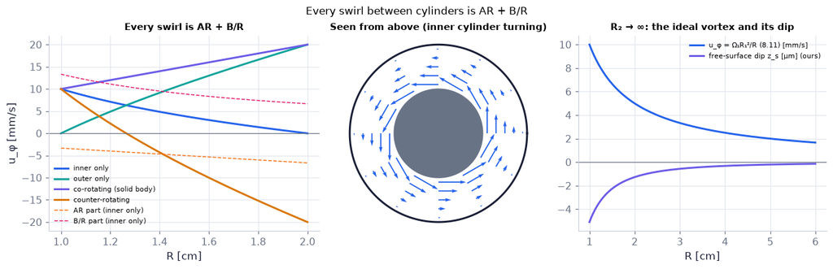

```python
R1, R2 = 0.01, 0.02                                       # the annulus of the tiny example [m] (R₁/R₂ = 0.5)
Rr = np.linspace(R1, R2, 200)                             # radii across the gap [m]
fig, (a1, a2, a3) = plt.subplots(1, 3, figsize=(12, 3.8), gridspec_kw=dict(width_ratios=[1.2, 1, 1.1]))   # the figure and its panels
cases = [((1, 0), "inner only", COLORS["blue"]), ((0, 1), "outer only", COLORS["teal"]),   # four wall combinations
         ((1, 1), "co-rotating (solid body)", COLORS["accent"]), ((1, -1), "counter-rotating", COLORS["amber"])]   # (Ω₁, Ω₂) pairs [rad/s], name, colour
for (O1, O2), lab, c in cases:                            # four (Ω₁, Ω₂) pairs [rad/s]
    a1.plot(1e2*Rr, 1e3*ch08.circular_couette(Rr, R1, R2, O1, O2), color=c, lw=2, label=lab)   # (8.10) [mm/s]
_, A, B = ch08.circular_couette(Rr, R1, R2, 1, 0, return_coeffs=True)   # the two parts of the inner-only case
a1.plot(1e2*Rr, 1e3*A*Rr, color=COLORS["orange"], ls="--", lw=1, label="AR part (inner only)")   # a curve (its label says which)
a1.plot(1e2*Rr, 1e3*B/Rr, color=COLORS["rose"], ls="--", lw=1, label="B/R part (inner only)")   # a curve (its label says which)
a1.axhline(0, color=COLORS["muted"], lw=0.8)             # reference line
a1.set_xlabel("R [cm]"); a1.set_ylabel("u_φ [mm/s]"); a1.legend(fontsize=7); a1.set_title("Every swirl is AR + B/R", fontsize=10)   # labels with units
ph = np.linspace(0, 2*np.pi, 13)[:-1]                     # 12 angles
for Rk in np.linspace(R1*1.1, R2*0.95, 5):                # 5 radii: arrows ∝ u_φ, tangent to circles (inner-only case)
    uk = ch08.circular_couette(Rk, R1, R2, 1, 0)         # u_φ at this radius (inner cylinder turning) [m/s]
    a2.quiver(Rk*np.cos(ph), Rk*np.sin(ph), -uk*np.sin(ph), uk*np.cos(ph), color=COLORS["blue"], scale=0.06, width=0.006)   # velocity arrows
t_ = np.linspace(0, 2*np.pi, 200)                        # angles for drawing the two circles
a2.fill(R1*np.cos(t_), R1*np.sin(t_), color=COLORS["muted"]); a2.plot(R2*np.cos(t_), R2*np.sin(t_), color=COLORS["ink"], lw=2)   # a filled shape
a2.set_aspect("equal"); a2.axis("off"); a2.set_title("Seen from above (inner cylinder turning)", fontsize=10)   # each panel says its message
Rf = np.linspace(R1, 6*R1, 200)                           # outside a lone cylinder (R₂ = ∞) [m]
uf = ch08.circular_couette(Rf, R1, np.inf, 1.0, 0.0)      # (8.11): Ω₁R₁²/R
Gam = 2*np.pi*1.0*R1**2                                   # circulation Γ = 2πΩ₁R₁² [m²/s]
zs = -Gam**2/(8*np.pi**2*9.81*Rf**2)                      # free-surface height relative to far away (ours, Ch. 5's funnel) [m]
a3.plot(1e2*Rf, 1e3*uf, color=COLORS["blue"], lw=2, label="u_φ = Ω₁R₁²/R (8.11) [mm/s]")   # a curve (its label says which)
a3.plot(1e2*Rf, 1e6*zs, color=COLORS["accent"], lw=2, label="free-surface dip z_s [µm] (ours)")   # a curve (its label says which)
a3.axhline(0, color=COLORS["muted"], lw=0.8)             # reference line
a3.set_xlabel("R [cm]"); a3.legend(fontsize=7); a3.set_title("R₂ → ∞: the ideal vortex and its dip", fontsize=10)   # labels with units
fig.suptitle("Every swirl between cylinders is AR + B/R", fontsize=11)   # the figure's message
savefig(fig, "ch08", "c04_circular_couette"); plt.show() # save the PNG to outputs/ch08, then draw
```

**What you see.** (a) four curves joining the two wall speeds; the co-rotating one is a straight line; the counter-rotating one crosses zero inside the gap; (b) the annulus from above with arrows growing toward the inner cylinder (our remake of Fig. 8.6 `N104`); (c) the free vortex outside a lone cylinder and the free surface dipping toward it (our Fig. 8.7).

**How to read it.** A straight line is pure AR (B = 0, rigid rotation); a curve bending like 1/R carries a vortex part (dashed rose); where $u_\varphi$ changes sign the fluid turns the other way. In (c) the dip is tiny here (micrometres) because Ω₁ is only 1 rad/s.

**What would change if…** …the outer cylinder turned faster than the inner in the same sense: $(Ru_\varphi)^2$ grows outward and the flow is stable (Rayleigh's criterion, Ch. 11); spin only the inner one and it becomes unstable above a critical speed — the Taylor vortices.

```python
R1, R2 = 0.01, 0.02                                       # annulus [m]
Rr = np.linspace(R1, R2, 80)                              # radii [m]


def frame(r_):                                            # r_ = Ω₂/Ω₁ with Ω₁ = 1 rad/s
    return {"u_φ(R), (8.10)": (1e2*Rr, 1e3*ch08.circular_couette(Rr, R1, R2, 1.0, r_)),   # the swirl [mm/s]
            "solid body Ω₂R": (1e2*Rr, 1e3*r_*Rr),                                          # rigid rotation reference
            "free vortex Ω₁R₁²/R": (1e2*Rr, 1e3*R1**2/Rr)}                                  # ideal-vortex reference


ratios = np.linspace(-2, 2, 21 if not FAST else 11)       # slider values Ω₂/Ω₁ [–]
fig = slider_figure(frame, "Ω₂/Ω₁", ratios, unit="", xlabel="R [cm]", ylabel="u_φ [mm/s]", title="")   # precompute every slider/time position
titles = []                                               # A, B and the Rayleigh verdict for each ratio
for r_ in ratios:                                        # each slider value
    st = ch08.circular_couette_state(R1, R2, 1.0, r_)     # constants of (8.9) and (Ru_φ)² increasing outward?
    tag = "Rayleigh-stable" if st["rayleigh_stable"] else "can become unstable (Ch. 11)"   # Rayleigh's verdict
    titles.append(f"A = {st['A']:.2f} 1/s, B = {1e4*st['B']:.2f} cm²/s — {tag}")   # the title for this step
step_titles(fig, titles)                                 # numbers that follow the slider
recolor(fig, {"u_φ(R), (8.10)": COLORS["blue"], "solid body Ω₂R": COLORS["orange"], "free vortex Ω₁R₁²/R": COLORS["rose"]},   # colours by meaning (as in the static figures)
        {"solid body Ω₂R": "dash", "free vortex Ω₁R₁²/R": "dash"})   # (continued)
fig.show()                                               # draw the interactive figure
```

[interactive chart not shown]

**What does the code above do?**

The slider sets the outer wall's rotation relative to the inner one (Ω₁ = 1 rad/s). The title prints A, B and whether Rayleigh's criterion (angular momentum growing outward) holds; the dashed references are the two pure limits.

**What would change if…** …the walls were not exactly parallel — a thin gap that narrows slowly, as under a bearing pad? The flow is then *nearly* parallel, the nonlinear term is small instead of zero, and we need a way to decide what may be dropped: the lubrication approximation (C05).

## 8.3 Elementary Lubrication Theory

**What is this section about?** Real walls are rarely exactly parallel, but in a thin gap they are *nearly* parallel. We learn how to decide, by scaling with two different lengths, which terms of the Navier–Stokes equations can be dropped; the result is a local Couette-plus-Poiseuille profile and one equation for the pressure (the Reynolds equation). It explains why an oil film under a bearing pad carries tonnes, why viscous flow between glass plates draws the streamlines of ideal flow, and how a honey drop spreads under its own weight. The same scaling argument becomes the boundary-layer approximation in Ch. 9.

> 🔁 **Recap — The field equations in the gap** (Ch. 4 §4.6). In two dimensions: continuity $\frac{\partial u}{\partial x}+\frac{\partial v}{\partial y}=0$ *(6.2)* and the x-component of (8.1), $\frac{D\mathbf u}{Dt}=-\frac1\rho\nabla p+\nu\nabla^2\mathbf u$, written out: $\frac{\partial u}{\partial t}+u\frac{\partial u}{\partial x}+v\frac{\partial u}{\partial y}=-\frac1\rho \frac{\partial p}{\partial x}+\frac\mu\rho\big(\frac{\partial^2u}{\partial x^2}+\frac{\partial^2u}{\partial y^2}\big)$ *(8.13a)* — nothing new, just written out.

### 🧩 The lubrication approximation `C05`

*The question:* Why can we throw away inertia in a thin film even when UL/ν is in the thousands?

*In one line:* $0\cong-\frac1\rho\frac{\partial p}{\partial x}+\nu\frac{\partial^2u}{\partial y^2}$ *(8.17a)*

#### The problem in plain words

Under a sliding bearing pad the oil film is 50 µm thick and 5 cm long — a thousand times longer than thick. The oil moves at metres per second and UL/ν ≈ 4000, which in a pipe would be turbulent. Yet lubrication engineers treat the film as purely viscous. We want the argument that makes this legitimate — and the number that must be small instead of 1/Re.

📝 **Note.** **N23 [B] · The lubrication idea.** In a narrow passage of gap h and length L ≫ h (Fig. 8.8) the flow is nearly parallel; pressure and viscous forces dominate, and a gentle curvature of the passage does not matter as long as its radius is much larger than h. Exactly the same reasoning, with the gap replaced by a thin layer next to a wall, gives the boundary-layer approximation (Ch. 9 §9.1).

#### The idea

```
↑ y ~ h = εL (small)          ∂/∂x ~ 1/L   (slow along the gap)
│  ═══════════════════        ∂/∂y ~ 1/h   (fast across it)
│  ──► ──► ──► u ~ U          continuity: U/L ~ v/h  ⇒  v ~ εU
└──────────────────────► x ~ L
```

Two length scales, and continuity fixes the size of v.

📝 **Note.** **N24 [B] · The y-momentum equation.** The y-equation is written below in its correct form. ⚠️ The book prints $-\frac1\rho\frac{\partial p}{\partial x}$ here; the y-equation needs ∂p/∂**y** — the scaled (8.16b), $\varepsilon^4\mathrm{Re}_L\Big(\frac{\partial v^*}{\partial t^*}+u^*\frac{\partial v^*}{\partial x^*}+v^*\frac{\partial v^*}{\partial y^*}\Big)=-\frac1\Lambda\frac{\partial p^*}{\partial y^*}+\varepsilon^4\frac{\partial^2v^*}{\partial x^{*2}}+\varepsilon^2\frac{\partial^2v^*}{\partial y^{*2}}$ confirms it, and `ch08.lubrication_nondim_sympy()` shows that the printed form gives a coefficient set that does not match (8.16b) (D10 step 12, check cell below).

$$ \frac{\partial v}{\partial t}+u\frac{\partial v}{\partial x}+v\frac{\partial v}{\partial y}=-\frac1\rho\frac{\partial p}{\partial y}+\frac\mu\rho\Big(\frac{\partial^2v}{\partial x^2}+\frac{\partial^2v}{\partial y^2}\Big) \qquad \text{(8.13b)} $$

> 📎 **Primer — anisotropic scaling with two length scales.** `P188` · When a flow is long and thin, measure x in units of the length L and y in units of the thickness h = εL; derivatives then carry different sizes, $\partial/\partial x=(1/L)\partial/\partial x^*$ but $\partial/\partial y=(1/\varepsilon L)\partial/ \partial y^*$. The velocity across the layer gets its own scale from continuity: U/L must balance v/h, so v ~ εU. Written this way every starred quantity is of order one and the size of each term sits in its coefficient.

```python
L, eps, U = 0.05, 1e-3, 5.0              # length [m], fineness h/L, speed [m/s]
h = eps*L                                # the gap [m]
print(U/L, (eps*U)/h)                    # both 100 1/s: the two continuity terms balance
```

```
100.0 100.0
```

> 🔁 **Tools from earlier chapters used here** (see `knowledge/primers.md`)
- **scaled variables and the chain rule** — if $x=Lx^*$ then $\partial/\partial x=(1/L)\,\partial/\partial x^*$ (Ch. 4 P133).
- **bookkeeping of a small parameter ε** — multiply the whole equation by the factor that gives the term you expect to dominate the coefficient 1; every other coefficient is then a power of ε times a group, and you read off which terms are small (Ch. 2 P68, orders of smallness).
- **order-of-magnitude scaling** — replace each derivative by (change)/(distance over which it happens), e.g. ∂u/∂y ~ U/h (Ch. 4 P130).
- **sympy symbols and simplify in check cells** — `sp.symbols(..., positive=True)` makes symbols; `sp.simplify(expr) == 0` tests an identity (Ch. 4 P117).

📝 **Note.** **N26 [B] · The scalings (8.14),** with the fineness ratio ε = h/L and the atmospheric pressure $P_a$ as the book's pressure scale.

$$ x^*=\frac xL,\ y^*=\frac yh=\frac{y}{\varepsilon L},\ t^*=\frac{Ut}{L},\ u^*=\frac uU,\ v^*=\frac{v}{\varepsilon U},\ p^*=\frac{p}{P_a} \qquad \text{(8.14)} $$

#### 🧮 Derivation — The scaled gap equations: continuity and the two momentum equations `D10` (Eq. 8.16a: $\varepsilon^2\mathrm{Re}_L\Big(\frac{\partial u^*}{\partial t^*}+u^*\frac{\partial u^*}{\partial x^*}+v^*\frac{\partial u^*}{\partial y^*}\Big)=-\frac1\Lambda\frac{\partial p^*}{\partial x^*}+\varepsilon^2\frac{\partial^2u^*}{\partial x^{*2}}+\frac{\partial^2u^*}{\partial y^{*2}}$)

**What we want to show.** Rewrite the gap equations in variables of order one, so that the size of every term sits in its coefficient.

**Assumptions.** One length along (L), one across (h = εL); pressure scaled by the atmospheric P_a (as the book does).

**The plan.**

1. Turn the scalings into substitutions and derivative rules.
2. Scale continuity.
3. Scale x-momentum and divide by the cross-gap friction's coefficient.
4. Scale y-momentum and choose the factor that keeps the same 1/Λ.

**Tools we use** (each explained before this point): anisotropic scaling (primer P188) · scaled variables and the chain rule (P133) · bookkeeping of ε (gloss).

**We start from**

$$ \begin{array}{l}\frac{\partial u}{\partial x}+\frac{\partial v}{\partial y}=0\ \text{(6.2),} \\ \frac{\partial u}{\partial t}+u\frac{\partial u}{\partial x}+ v\frac{\partial u}{\partial y}=-\frac1\rho\frac{\partial p}{\partial x}+\frac\mu\rho\big(\frac{\partial^2u}{\partial x^2}+\frac{\partial^2u} {\partial y^2}\big) \\ \text{(8.13a), its v-twin (8.13b) with ∂p/∂y, and the scalings} \\ x^*=\frac xL,\ y^*=\frac y{\varepsilon L},\ t^*=\frac {Ut}L,\ u^*=\frac uU,\ v^*=\frac v{\varepsilon U},\ p^*=\frac p{P_a}\ \text{(8.14).}\end{array} $$

**Step 1 of 14 — Invert the scalings.**

$$ x=Lx^*,\ y=\varepsilon Ly^*,\ t=\tfrac LU t^*,\ u=Uu^*,\ v=\varepsilon Uv^*,\ p=P_ap^* $$

- *Why we can do this:* We will substitute these into the equations; each starred variable is of order one by design.
- *In words:* dimensional quantities = scale × order-one variable.

**Step 2 of 14 — Write the derivative rules.**

$$ \frac{\partial}{\partial x}=\frac1L\frac{\partial}{\partial x^*},\ \frac{\partial} {\partial y}=\frac{1}{\varepsilon L}\frac{\partial}{\partial y^*},\ \frac{\partial}{\partial t}=\frac UL\frac{\partial}{\partial t^*} $$

- *Why we can do this:* Chain rule for scaled variables (P133): ∂x*/∂x = 1/L, and so on.
- *In words:* derivatives across the gap are 1/ε times larger.

**Step 3 of 14 — Scale continuity.**

$$ \frac UL\frac{\partial u^*}{\partial x^*}+\frac{\varepsilon U}{\varepsilon L}\frac{\partial v^*} {\partial y^*}=0 $$

- *Why we can do this:* Substitute u = Uu*, v = εUv* and the rules of step 2 into (6.2), $\frac{\partial u}{\partial x}+\frac{\partial v}{\partial y}=0$.
- *In words:* both terms carry U/L.

**Step 4 of 14 — Divide by U/L.**

$$ \frac{\partial u^*}{\partial x^*}+\frac{\partial v^*}{\partial y^*}=0\ \text{(8.15)} $$

- *Why we can do this:* The ε cancels because v was scaled with εU — chosen exactly so that continuity balances (if v ~ U the u-term would drop).
- *In words:* (8.15), $\frac{\partial u^*}{\partial x^*}+\frac{\partial v^*}{\partial y^*}=0$: mass is conserved with no approximation.

**Step 5 of 14 — Scale the x-inertia terms.**

$$ \frac{\partial u}{\partial t}+u\frac{\partial u}{\partial x}+v\frac{\partial u}{\partial y}= \frac{U^2}{L}\Big(\frac{\partial u^*}{\partial t^*}+u^*\frac{\partial u^*}{\partial x^*}+v^*\frac{\partial u^*}{\partial y^*}\Big) $$

- *Why we can do this:* Each term: (U/L)U, U(U/L), (εU)(U/εL) — all U²/L.
- *In words:* inertia is of size U²/L.

**Step 6 of 14 — Scale the x-pressure term.**

$$ -\frac1\rho\frac{\partial p}{\partial x}=-\frac{P_a}{\rho L}\frac{\partial p^*}{\partial x^*} $$

- *Why we can do this:* p = P_a p* and ∂/∂x = (1/L)∂/∂x*.
- *In words:* pressure term of size P_a/(ρL).

**Step 7 of 14 — Scale the two x-viscous terms.**

$$ \frac\mu\rho\frac{\partial^2u}{\partial x^2}=\frac{\mu U}{\rho L^2}\frac{\partial^2u^*} {\partial x^{*2}},\ \ \frac\mu\rho\frac{\partial^2u}{\partial y^2}=\frac{\mu U}{\rho\varepsilon^2L^2}\frac{\partial^2u^*}{\partial y^{*2}} $$

- *Why we can do this:* Two derivatives along the gap bring 1/L², two across bring 1/(εL)².
- *In words:* friction across the gap is 1/ε² larger.

**Step 8 of 14 — Multiply by ρε²L²/(μU).**

$$ \times\frac{\rho\varepsilon^2L^2}{\mu U} $$

- *Why we can do this:* This makes the cross-gap friction — the term we expect to dominate — have coefficient 1, so every other coefficient reads directly as a relative size.
- *In words:* measure everything against cross-gap friction.

**Step 9 of 14 — Read the inertia coefficient.**

$$ \frac{U^2}{L}\cdot\frac{\rho\varepsilon^2L^2}{\mu U}=\varepsilon^2\frac{\rho UL}{\mu}= \varepsilon^2\mathrm{Re}_L $$

- *Why we can do this:* Simplify the product; Re_L = ρUL/μ uses the passage length.
- *In words:* inertia is weighed by ε²Re_L.

**Step 10 of 14 — Read the other x-coefficients.**

$$ \varepsilon^2\mathrm{Re}_L(\ldots)=-\frac1\Lambda\frac{\partial p^*}{\partial x^*}+ \varepsilon^2\frac{\partial^2u^*}{\partial x^{*2}}+\frac{\partial^2u^*}{\partial y^{*2}}\ \text{(8.16a)} $$

- *Why we can do this:* Pressure: (P_a/ρL)(ρε²L²/μU) = P_a h²/(μUL) = 1/Λ; along-gap friction: ε²; across: 1.
- *In words:* (8.16a), $\varepsilon^2\mathrm{Re}_L\Big(\frac{\partial u^*}{\partial t^*}+u^*\frac{\partial u^*}{\partial x^*}+v^*\frac{\partial u^*}{\partial y^*}\Big)=-\frac1\Lambda\frac{\partial p^*}{\partial x^*}+\varepsilon^2\frac{\partial^2u^*}{\partial x^{*2}}+\frac{\partial^2u^*}{\partial y^{*2}}$.

**Step 11 of 14 — Scale the y-inertia terms.**

$$ \frac{\partial v}{\partial t}+u\frac{\partial v}{\partial x}+v\frac{\partial v}{\partial y}= \frac{\varepsilon U^2}{L}(\ldots)^* $$

- *Why we can do this:* Each term now carries one factor εU from v: (U/L)εU, U(εU/L), (εU)(εU/εL).
- *In words:* vertical inertia is ε times smaller.

**Step 12 of 14 — Scale the y-pressure and friction.**

$$ -\frac{P_a}{\rho\varepsilon L}\frac{\partial p^*}{\partial y^*},\ \ \frac{\mu\varepsilon U}{\rho L^2}\frac{\partial^2v^*}{\partial x^{*2}},\ \ \frac{\mu U}{\rho\varepsilon L^2}\frac{\partial^2v^*}{\partial y^{*2}} $$

- *Why we can do this:* Use ∂/∂y = (1/εL)∂/∂y* on the pressure — the corrected (8.13b), $\frac{\partial v}{\partial t}+u\frac{\partial v}{\partial x}+v\frac{\partial v}{\partial y}=-\frac1\rho\frac{\partial p}{\partial y}+\frac\mu\rho\Big(\frac{\partial^2v}{\partial x^2}+\frac{\partial^2v}{\partial y^2}\Big)$ has ∂p/∂y; the book prints ∂p/∂x, which would give a different set.
- *In words:* pressure across the gap is large.

**Step 13 of 14 — Multiply by ρε³L²/(μU).**

$$ \times\frac{\rho\varepsilon^3L^2}{\mu U} $$

- *Why we can do this:* We choose the factor that gives the pressure term the same coefficient 1/Λ as in (8.16a), $\varepsilon^2\mathrm{Re}_L\Big(\frac{\partial u^*}{\partial t^*}+u^*\frac{\partial u^*}{\partial x^*}+v^*\frac{\partial u^*}{\partial y^*}\Big)=-\frac1\Lambda\frac{\partial p^*}{\partial x^*}+\varepsilon^2\frac{\partial^2u^*}{\partial x^{*2}}+\frac{\partial^2u^*}{\partial y^{*2}}$: (P_a/ρεL)(ρε³L²/μU) = ε²LP_a/(μU) = 1/Λ.
- *In words:* compare against the same pressure yardstick.

**Step 14 of 14 — Read the y-coefficients.**

$$ \varepsilon^4\mathrm{Re}_L(\ldots)=-\frac1\Lambda\frac{\partial p^*}{\partial y^*}+ \varepsilon^4\frac{\partial^2v^*}{\partial x^{*2}}+\varepsilon^2\frac{\partial^2v^*}{\partial y^{*2}}\ \text{(8.16b)} $$

- *Why we can do this:* Inertia (εU²/L)(ρε³L²/μU) = ε⁴Re_L; friction ε⁴ and ε² likewise.
- *In words:* (8.16b), $\varepsilon^4\mathrm{Re}_L\Big(\frac{\partial v^*}{\partial t^*}+u^*\frac{\partial v^*}{\partial x^*}+v^*\frac{\partial v^*}{\partial y^*}\Big)=-\frac1\Lambda\frac{\partial p^*}{\partial y^*}+\varepsilon^4\frac{\partial^2v^*}{\partial x^{*2}}+\varepsilon^2\frac{\partial^2v^*}{\partial y^{*2}}$: only pressure lacks a power of ε.

**Result**

$$ \begin{array}{l}\frac{\partial u^*}{\partial x^*}+\frac{\partial v^*}{\partial y^*}=0\ \text{(8.15)} \\ \varepsilon^2\mathrm{Re}_L\Big(\frac{\partial u^*}{\partial t^*}+u^*\frac{\partial u^*}{\partial x^*}+v^*\frac{\partial u^*}{\partial y^*}\Big)=-\frac1\Lambda\frac{\partial p^*}{\partial x^*}+\varepsilon^2\frac{\partial^2u^*}{\partial x^{*2}}+\frac{\partial^2u^*}{\partial y^{*2}}\ \text{(8.16a)} \\ \varepsilon^4\mathrm{Re}_L\Big(\frac{\partial v^*}{\partial t^*}+u^*\frac{\partial v^*}{\partial x^*}+v^*\frac{\partial v^*}{\partial y^*}\Big)=-\frac1\Lambda\frac{\partial p^*}{\partial y^*}+\varepsilon^4\frac{\partial^2v^*}{\partial x^{*2}}+\varepsilon^2\frac{\partial^2v^*}{\partial y^{*2}}\ \text{(8.16b)}\end{array} $$

*In words:* in a thin gap inertia carries ε²Re_L and all y-terms except pressure carry ε² or less.

**What it means.** "Large Re" is not the right test in a thin gap: inertia competes with ε²Re_L. The same bookkeeping becomes the boundary-layer approximation in Ch. 9.

**Check it.** Every coefficient is dimensionless ✓. sympy (`lubrication_nondim_sympy`, the check cell below) returns the sets {ε²Re_L, 1/Λ, ε², 1} and {ε⁴Re_L, 1/Λ, ε⁴, ε²}; the printed y-equation (8.13b), with $-\frac1\rho\frac{\partial p}{\partial x}$ in place of $-\frac1\rho\frac{\partial p}{\partial y}$, gives a set that does not match (8.16b), $\varepsilon^4\mathrm{Re}_L\Big(\frac{\partial v^*}{\partial t^*}+u^*\frac{\partial v^*}{\partial x^*}+v^*\frac{\partial v^*}{\partial y^*}\Big)=-\frac1\Lambda\frac{\partial p^*}{\partial y^*}+\varepsilon^4\frac{\partial^2v^*}{\partial x^{*2}}+\varepsilon^2\frac{\partial^2v^*}{\partial y^{*2}}$. Numbers (engine film): ε = 10⁻³, Re_L = 4350 → ε²Re_L = 4.35 × 10⁻³.

```python
sol = ch08.lubrication_nondim_sympy()                    # D10 steps 1–14 repeated symbolically (cached)
L_, h_, U_, rho_, mu_, Pa_, eps, ReL, Lam = sol["symbols"]   # the symbols it used (ε, Re_L, Λ among them)
print("scaled continuity:", sol["continuity_star"])      # (8.15): no coefficient at all
print("x-coefficients:", sol["x_coeffs"])                # (8.16a): ε²Re_L, 1/Λ, ε², 1
print("y-coefficients:", sol["y_coeffs"])                # (8.16b): ε⁴Re_L, 1/Λ, ε⁴, ε²
assert sp.simplify(sol["x_coeffs"]["inertia"] - eps**2*ReL) == 0      # step 9: inertia weighed by ε²Re_L
assert sp.simplify(sol["x_coeffs"]["pressure"] - 1/Lam) == 0          # step 10: pressure 1/Λ
assert sp.simplify(sol["x_coeffs"]["diff_across"] - 1) == 0           # step 8's choice: cross-gap friction has 1
assert sp.simplify(sol["y_coeffs"]["inertia"] - eps**4*ReL) == 0      # step 14: y-inertia ε⁴Re_L
assert sp.simplify(sol["y_coeffs"]["pressure"] - 1/Lam) == 0          # step 13's choice: the same 1/Λ yardstick
assert sp.simplify(sol["y_coeffs"]["diff_across"] - eps**2) == 0      # step 14: y-friction across the gap ε²
print("with the printed ∂p/∂x in (8.13b):", sol["printed_13b_y_coeffs"])   # pressure ε/Λ: not the set of (8.16b)
assert sp.simplify(sol["printed_13b_y_coeffs"]["pressure"] - 1/Lam) != 0   # the printed slip fails
# rebuild steps 5, 6, 8–10 here, term by term, from the scalings (8.14) (independent of the engine):
inertia = (U_/L_)*U_                                     # step 5: u ∂u/∂x with u = U u*, ∂/∂x = (1/L)∂/∂x* → size U²/L
pressure = Pa_/(rho_*L_)                                 # step 6: (1/ρ)∂p/∂x with p = P_a p* → size P_a/(ρL)
across = mu_*U_/(rho_*(eps*L_)**2)                       # step 7: (μ/ρ)∂²u/∂y² with ∂/∂y = (1/εL)∂/∂y* → μU/(ρε²L²)
factor = rho_*eps**2*L_**2/(mu_*U_)                      # step 8: divide by the cross-gap friction's size
print("inertia coefficient:", sp.simplify(inertia*factor), "  pressure coefficient:", sp.simplify(pressure*factor),
      "  cross-gap friction:", sp.simplify(across*factor))
assert sp.simplify(inertia*factor - eps**2*rho_*U_*L_/mu_) == 0   # step 9: ε² times Re_L = ρUL/μ
assert sp.simplify(pressure*factor - Pa_*(eps*L_)**2/(mu_*U_*L_)) == 0   # step 10: 1/Λ with Λ = μUL/(P_a h²), h = εL
```

```
scaled continuity: Eq(Derivative(u_s(x, y, t), x) + Derivative(v_s(x, y, t), y), 0)
x-coefficients: {'inertia': Re_L*epsilon**2, 'pressure': 1/Lambda, 'diff_along': epsilon**2, 'diff_across': 1}
y-coefficients: {'inertia': Re_L*epsilon**4, 'pressure': 1/Lambda, 'diff_along': epsilon**4, 'diff_across': epsilon**2}
with the printed ∂p/∂x in (8.13b): {'inertia': Re_L*epsilon**4, 'pressure': epsilon/Lambda, 'diff_along': epsilon**4, 'diff_across': epsilon**2}
inertia coefficient: L*U*epsilon**2*rho/mu   pressure coefficient: L*P_a*epsilon**2/(U*mu)   cross-gap friction: 1
```

> ⚠️ **Common confusion (traps in `D10`):** v scales with εU (from continuity), not U; the two momentum equations are multiplied by different factors (ε²L²ρ/μU and ε³L²ρ/μU) so that the pressure keeps 1/Λ; the printed y-equation (8.13b) carries $-\frac1\rho\frac{\partial p}{\partial x}$; it must be $-\frac1\rho\frac{\partial p}{\partial y}$.

📝 **Note.** **N27 [B], N28 [B], N29 [B] · What D10 delivered.** **N27** The scaled continuity equation (8.15) has no coefficient: mass is conserved exactly — v is small *because* u varies slowly. **N28** In (8.16a), $\varepsilon^2\mathrm{Re}_L\Big(\frac{\partial u^*}{\partial t^*}+u^*\frac{\partial u^*}{\partial x^*}+v^*\frac{\partial u^*}{\partial y^*}\Big)=-\frac1\Lambda\frac{\partial p^*}{\partial x^*}+\varepsilon^2\frac{\partial^2u^*}{\partial x^{*2}}+\frac{\partial^2u^*}{\partial y^{*2}}$ the inertia carries $\varepsilon^2\mathrm{Re}_L$ with $\mathrm{Re}_L=\rho UL/\mu$, and the pressure carries $1/\Lambda$ with the bearing number $\Lambda=\mu UL/(P_ah^2)$. **N29** In (8.16b), $\varepsilon^4\mathrm{Re}_L\Big(\frac{\partial v^*}{\partial t^*}+u^*\frac{\partial v^*}{\partial x^*}+v^*\frac{\partial v^*}{\partial y^*}\Big)=-\frac1\Lambda\frac{\partial p^*}{\partial y^*}+\varepsilon^4\frac{\partial^2v^*}{\partial x^{*2}}+\varepsilon^2\frac{\partial^2v^*}{\partial y^{*2}}$ only the pressure term lacks a power of ε — the seed of "pressure is constant across a thin layer" (Ch. 9, Ch. 13).

$$ \frac{\partial u^*}{\partial x^*}+\frac{\partial v^*}{\partial y^*}=0 \qquad \text{(8.15)} $$

#### 🧮 Derivation — The lubrication balance $0\cong-\frac1\rho\frac{\partial p}{\partial x}+\nu\frac{\partial^2u}{\partial y^2}$, $0\cong-\frac1\rho\frac{\partial p}{\partial y}$ `D11` (Eq. 8.17a: $0\cong-\frac1\rho\frac{\partial p}{\partial x}+\nu\frac{\partial^2u}{\partial y^2}$)

**What we want to show.** Drop the small terms of (8.16), $\varepsilon^2\mathrm{Re}_L\Big(\frac{\partial u^*}{\partial t^*}+u^*\frac{\partial u^*}{\partial x^*}+v^*\frac{\partial u^*}{\partial y^*}\Big)=-\frac1\Lambda\frac{\partial p^*}{\partial x^*}+\varepsilon^2\frac{\partial^2u^*}{\partial x^{*2}}+\frac{\partial^2u^*}{\partial y^{*2}}$ and return to dimensional form — restoring the ν that the printed (8.17a), $0\cong-\frac1\rho\frac{\partial p}{\partial x}+\frac{\partial^2u}{\partial y^2}$, omits.

**Assumptions.** ε ≪ 1, ε²Re_L ≪ 1, Λ = O(1) with a suitable pressure scale (step 1).

**The plan.**

1. State the orders.
2. Drop the small terms in each equation.
3. Undo the scaling.

**Tools we use** (each explained before this point): orders of smallness (P68).

**We start from**

$$ \varepsilon^2\mathrm{Re}_L\Big(\frac{\partial u^*}{\partial t^*}+u^*\frac{\partial u^*}{\partial x^*}+v^*\frac{\partial u^*}{\partial y^*}\Big)=-\frac1\Lambda\frac{\partial p^*}{\partial x^*}+\varepsilon^2\frac{\partial^2u^*}{\partial x^{*2}}+\frac{\partial^2u^*}{\partial y^{*2}}\ \text{(8.16a)},\qquad \varepsilon^4\mathrm{Re}_L\Big(\frac{\partial v^*}{\partial t^*}+u^*\frac{\partial v^*}{\partial x^*}+v^*\frac{\partial v^*}{\partial y^*}\Big)=-\frac1\Lambda\frac{\partial p^*}{\partial y^*}+\varepsilon^4\frac{\partial^2v^*}{\partial x^{*2}}+\varepsilon^2\frac{\partial^2v^*}{\partial y^{*2}}\ \text{(8.16b)} $$

*In words:* the scaled momentum equations of D10

**Step 1 of 7 — State the orders.**

$$ \varepsilon\ll1,\ \ \varepsilon^2\mathrm{Re}_L\ll1,\ \ \Lambda=O(1) $$

- *Why we can do this:* All starred derivatives are O(1) by construction; only the coefficients decide sizes.
- *In words:* thin gap, small reduced Reynolds number.

**Step 2 of 7 — Drop the x-inertia.**

$$ 0=-\frac1\Lambda\frac{\partial p^*}{\partial x^*}+\varepsilon^2\frac{\partial^2u^*}{\partial x^{*2}}+ \frac{\partial^2u^*}{\partial y^{*2}}+O(\varepsilon^2\mathrm{Re}_L) $$

- *Why we can do this:* The left side of (8.16a), $\varepsilon^2\mathrm{Re}_L\Big(\frac{\partial u^*}{\partial t^*}+u^*\frac{\partial u^*}{\partial x^*}+v^*\frac{\partial u^*}{\partial y^*}\Big)=-\frac1\Lambda\frac{\partial p^*}{\partial x^*}+\varepsilon^2\frac{\partial^2u^*}{\partial x^{*2}}+\frac{\partial^2u^*}{\partial y^{*2}}$ is ε²Re_L × O(1).
- *In words:* acceleration is negligible — even the unsteady part.

**Step 3 of 7 — Drop the along-gap friction.**

$$ 0\cong-\frac1\Lambda\frac{\partial p^*}{\partial x^*}+\frac{\partial^2u^*}{\partial y^{*2}} $$

- *Why we can do this:* ε²∂²u*/∂x*² is ε² times an order-one derivative, so it is as small as the inertia we just dropped.
- *In words:* friction acts across the gap only.

**Step 4 of 7 — Reduce the y-equation.**

$$ \frac1\Lambda\frac{\partial p^*}{\partial y^*}=O(\varepsilon^2)\ \Rightarrow\ 0\cong-\frac{\partial p^*}{\partial y^*} $$

- *Why we can do this:* In (8.16b), $\varepsilon^4\mathrm{Re}_L\Big(\frac{\partial v^*}{\partial t^*}+u^*\frac{\partial v^*}{\partial x^*}+v^*\frac{\partial v^*}{\partial y^*}\Big)=-\frac1\Lambda\frac{\partial p^*}{\partial y^*}+\varepsilon^4\frac{\partial^2v^*}{\partial x^{*2}}+\varepsilon^2\frac{\partial^2v^*}{\partial y^{*2}}$ every term except the pressure carries ε² or smaller.
- *In words:* pressure is the same across the gap to relative order ε².

**Step 5 of 7 — Undo the x-scaling.**

$$ 0\cong-\frac1\rho\frac{\partial p}{\partial x}+\frac\mu\rho\frac{\partial^2u}{\partial y^2} $$

- *Why we can do this:* Multiply by μU/(ρε²L²) (the inverse of D10 step 8) and use p = P_a p*, ∂/∂y = (1/εL)∂/∂y*.
- *In words:* back in dimensions.

**Step 6 of 7 — Write μ/ρ as ν.**

$$ 0\cong-\frac1\rho\frac{\partial p}{\partial x}+\nu\frac{\partial^2u}{\partial y^2}\ \text{(8.17a)} $$

- *Why we can do this:* ν = μ/ρ; the book prints this without the ν, which fails the units (m/s² vs 1/(m s)).
- *In words:* (8.17a), $0\cong-\frac1\rho\frac{\partial p}{\partial x}+\nu\frac{\partial^2u}{\partial y^2}$: pressure gradient = cross-gap friction.

**Step 7 of 7 — Undo the y-scaling.**

$$ 0\cong-\frac1\rho\frac{\partial p}{\partial y}\ \text{(8.17b)} $$

- *Why we can do this:* Multiply the reduced y-equation by P_a/(ρεL).
- *In words:* (8.17b), $0\cong-\frac1\rho\frac{\partial p}{\partial y}$.

**Result**

$$ 0\cong-\frac1\rho\frac{\partial p}{\partial x}+\nu\frac{\partial^2u}{\partial y^2}\ \text{(8.17a)},\qquad 0\cong-\frac1\rho\frac{\partial p}{\partial y}\ \text{(8.17b)} $$

*In words:* the lubrication approximation: a local Poiseuille balance with pressure uniform across the gap.

**What it means.** With P_a the bearing number is Λ = 49 for our film, not O(1); rescaling p by μUL/h² sets Λ = 1 and changes nothing in the ordering — the physical pressures are tens to hundreds of atmospheres.

**Check it.** Units of (8.17a), $0\cong-\frac1\rho\frac{\partial p}{\partial x}+\nu\frac{\partial^2u}{\partial y^2}$: both terms m/s² ✓. Time still appears as a parameter (no ∂/∂t term, yet h, p may vary slowly). Numbers: engine film ε²Re_L = 4.35 × 10⁻³.

> ⚠️ **Common confusion (traps in `D11`):** Dropping inertia needs ε²Re_L ≪ 1, not Re_L ≪ 1; ∂p*/∂y* is O(ε²), not exactly 0; re-dimensionalising restores ν.

📝 **Note.** **N30 [B] · Pressure is uniform across the gap,** with an error of relative size ε². The same statement across a thin atmospheric or oceanic layer is the hydrostatic approximation of Ch. 13.

$$ 0\cong-\frac1\rho\frac{\partial p}{\partial y} \qquad \text{(8.17b)} $$

> ⚠️ **Common confusion:** the book prints (8.17a) as $0\cong-\frac1\rho\frac{\partial p}{\partial x}+\frac{\partial^2u}{\partial y^2}$ — without the ν. The units do not balance (m/s² against 1/(m s)); re-dimensionalising (D11 step 5) restores $\nu\frac{\partial^2u}{\partial y^2}$. Its own next line, (8.18), $u(x,y,t)\cong\frac1\mu\frac{\partial p(x,t)}{\partial x}\frac{y^2}{2}+Ay+B$, carries the 1/μ correctly.

#### ✏️ Tiny example: an engine-bearing oil film

h = 50 µm, L = 5 cm, U = 5 m/s, a light oil with μ = 0.05 Pa s and ρ = 870 kg/m³, so ν = μ/ρ = 5.75 × 10⁻⁵ m²/s (numbers ours).

1. $\varepsilon=h/L=5\times10^{-5}/0.05=10^{-3}$.
2. $\mathrm{Re}_L=UL/\nu=5\times0.05/5.75\times10^{-5}=4350$ — in a pipe this would be turbulent.
3. $\varepsilon^2\mathrm{Re}_L=10^{-6}\times4350=4.35\times10^{-3}$ — small: inertia is under half a percent of friction.
4. The natural pressure scale $\mu UL/h^2=0.05\times5\times0.05/(2.5\times10^{-9})=5\times10^6$ Pa ≈ 49 atm.
5. With the book's atmospheric scale, $\Lambda=\mu UL/(P_ah^2)=5\times10^6/101\,325=49$ — not "near unity".

```python
L, h, U, rho, mu = 0.05, 50e-6, 5.0, 870.0, 0.05          # the engine film: length, gap [m], speed [m/s], ρ, μ
s = ch08.lubrication_scales(L, h, U, rho, mu)             # ε, Re_L, ε²Re_L, Λ (with P_a) and μUL/h²
print({k: f"{v:.4g}" for k, v in s.items()})             # show the numbers
keys = ("x_inertia", "x_pressure", "x_diff_along", "x_diff_across", "y_inertia", "y_pressure", "y_diff_along", "y_diff_across")   # the eight coefficients, in order
for scale in ("viscous", "atm"):                          # pressure scaled by μUL/h² (Λ = 1) or by P_a (the book's)
    t = ch08.lubrication_term_magnitudes(L, h, U, rho, mu, p_scale=scale)   # the coefficients of (8.16a), (8.16b)
    print(scale, {k: f"{t[k]:.3g}" for k in keys})       # show the numbers
```

```
{'eps': '0.001', 'Re_L': '4350', 'eps2_Re_L': '0.00435', 'eps4_Re_L': '4.35e-09', 'Lambda': '49.35', 'p_visc': '5e+06'}
viscous {'x_inertia': '0.00435', 'x_pressure': '1', 'x_diff_along': '1e-06', 'x_diff_across': '1', 'y_inertia': '4.35e-09', 'y_pressure': '1', 'y_diff_along': '1e-12', 'y_diff_across': '1e-06'}
atm {'x_inertia': '0.00435', 'x_pressure': '0.0203', 'x_diff_along': '1e-06', 'x_diff_across': '1', 'y_inertia': '4.35e-09', 'y_pressure': '0.0203', 'y_diff_along': '1e-12', 'y_diff_across': '1e-06'}
```

**What does the code above do?**

1. `lubrication_scales` returns ε = 10⁻³, Re_L = 4350, ε²Re_L = 4.35 × 10⁻³, Λ = 49.3 and the natural pressure scale μUL/h² = 5 × 10⁶ Pa.
2. `lubrication_term_magnitudes` returns exactly the coefficients of (8.16a), $\varepsilon^2\mathrm{Re}_L\Big(\frac{\partial u^*}{\partial t^*}+u^*\frac{\partial u^*}{\partial x^*}+v^*\frac{\partial u^*}{\partial y^*}\Big)=-\frac1\Lambda\frac{\partial p^*}{\partial x^*}+\varepsilon^2\frac{\partial^2u^*}{\partial x^{*2}}+\frac{\partial^2u^*}{\partial y^{*2}}$ and (8.16b), $\varepsilon^4\mathrm{Re}_L\Big(\frac{\partial v^*}{\partial t^*}+u^*\frac{\partial v^*}{\partial x^*}+v^*\frac{\partial v^*}{\partial y^*}\Big)=-\frac1\Lambda\frac{\partial p^*}{\partial y^*}+\varepsilon^4\frac{\partial^2v^*}{\partial x^{*2}}+\varepsilon^2\frac{\partial^2v^*}{\partial y^{*2}}$. With the viscous pressure scale μUL/h² every kept term is O(1): x-pressure 1, cross-gap friction 1, and inertia 4.35 × 10⁻³. With the book's P_a both pressure coefficients become 1/Λ = 0.0203 — only the bookkeeping changes, not the physics.

```python
eps = h/L; ReL = rho*U*L/mu; Lam = mu*U*L/(101325*h**2)   # ε, Re_L, Λ by hand (P_a = 101 325 Pa)
mine = [eps**2*ReL, 1/Lam, eps**2, 1.0, eps**4*ReL, 1/Lam, eps**4, eps**2]   # the eight coefficients of D10
lib = ch08.lubrication_term_magnitudes(L, h, U, rho, mu, p_scale="atm")   # the library's coefficients (P_a scale)
assert np.allclose(mine, [lib[k] for k in keys], rtol=1e-12)   # same numbers, in the order of `keys`
print("hand-made coefficients = library coefficients")   # show the numbers
```

```
hand-made coefficients = library coefficients
```

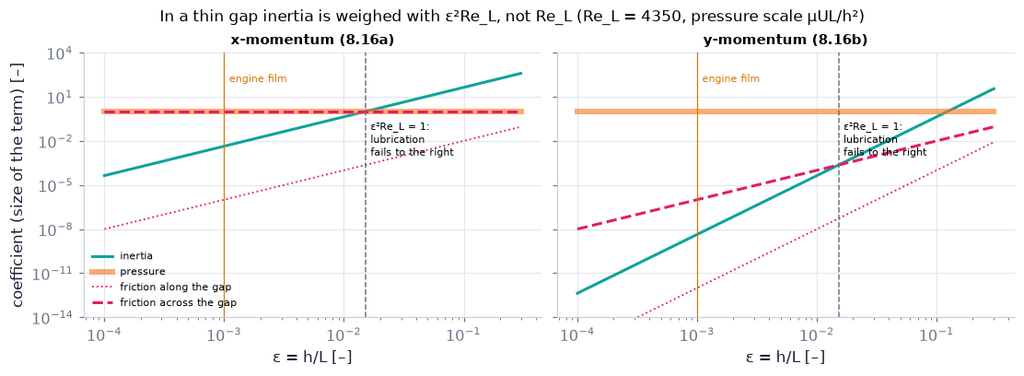

```python
L, U, rho, mu = 0.05, 5.0, 870.0, 0.05                    # fixed: Re_L = ρUL/μ = 4350
epss = np.geomspace(1e-4, 0.3, 60)                        # fineness ratios ε = h/L
T = [ch08.lubrication_term_magnitudes(L, e*L, U, rho, mu, p_scale="viscous") for e in epss]   # coefficients at each ε
fig, (a1, a2) = plt.subplots(1, 2, figsize=(10, 3.6), sharey=True)   # the figure and its panels
for ax, pre, title in ((a1, "x", "x-momentum (8.16a)"), (a2, "y", "y-momentum (8.16b)")):   # x-equation left, y-equation right
    ax.loglog(epss, [t_[pre + "_inertia"] for t_ in T], color=COLORS["teal"], lw=2, label="inertia")   # a curve (its label says which)
    ax.loglog(epss, [t_[pre + "_pressure"] for t_ in T], color=COLORS["orange"], lw=4, alpha=0.6, label="pressure")   # thick, under the rose dashes   # a curve (its label says which)
    ax.loglog(epss, [t_[pre + "_diff_along"] for t_ in T], color=COLORS["rose"], lw=1.2, ls=":", label="friction along the gap")   # a curve (its label says which)
    ax.loglog(epss, [t_[pre + "_diff_across"] for t_ in T], color=COLORS["rose"], lw=2, ls="--", label="friction across the gap")   # dashed: where it equals the pressure, both show   # a curve (its label says which)
    e_fail = 1/np.sqrt(4350.0)                            # where ε²Re_L = 1
    ax.axvline(e_fail, color=COLORS["muted"], ls="--", lw=1)   # reference line
    ax.text(e_fail*1.1, 1e-3, "ε²Re_L = 1:\nlubrication\nfails to the right", fontsize=7)   # a label on the plot
    ax.axvline(1e-3, color=COLORS["amber"], lw=0.8); ax.text(1.1e-3, 1e2, "engine film", fontsize=7, color=COLORS["amber"])   # reference line
    ax.set_xlabel("ε = h/L [–]"); ax.set_title(title, fontsize=10); ax.set_ylim(1e-14, 1e4)   # labels with units
a1.set_ylabel("coefficient (size of the term) [–]"); a1.legend(fontsize=7, loc="lower left")   # labels with units
fig.suptitle("In a thin gap inertia is weighed with ε²Re_L, not Re_L (Re_L = 4350, pressure scale μUL/h²)", fontsize=11)   # the figure's message
savefig(fig, "ch08", "c05_term_magnitudes"); plt.show()  # save the PNG to outputs/ch08, then draw
```

**What you see.** Two flat lines on the left (pressure and cross-gap friction) and falling lines for everything else; on the right only the pressure stays at 1 — every other y-term falls like ε² or faster.

**How to read it.** Read each term's size at your ε: at ε = 10⁻³ (amber line) inertia is 4.35 × 10⁻³ of the kept terms; only near ε ≈ 0.015 (dashed line) does it catch up.

**What would change if…** …Re_L were 100 times larger: the teal line moves up two decades and lubrication fails already at ε ≈ 0.0015.

📝 **Note.** **N31 [B] · How small is small?** For our engine film $\varepsilon^2\mathrm{Re}_L=4.35\times10^{-3}$, so the lubrication balance is excellent. (The book's own example uses a different oil film; its number lives in our private test file.) ⚠️ With $p^*=p/P_a$ the bearing number $\Lambda=\mu UL/(P_ah^2)$ is 49 here and ≈ 10³ for thinner, longer films — not "near unity" as the text assumes. Nothing in the ordering changes (Λ only rescales p*), but the physical pressure scale is μUL/h², tens to hundreds of atmospheres.

#### 🎮 Interactive: Why can a thin film ignore inertia?

**Why interactive rather than a static figure:** Drag the gap, the length and the speed and watch every term of the scaled momentum equations (8.16a), $\varepsilon^2\mathrm{Re}_L\Big(\frac{\partial u^*}{\partial t^*}+u^*\frac{\partial u^*}{\partial x^*}+v^*\frac{\partial u^*}{\partial y^*}\Big)=-\frac1\Lambda\frac{\partial p^*}{\partial x^*}+\varepsilon^2\frac{\partial^2u^*}{\partial x^{*2}}+\frac{\partial^2u^*}{\partial y^{*2}}$ and (8.16b), $\varepsilon^4\mathrm{Re}_L\Big(\frac{\partial v^*}{\partial t^*}+u^*\frac{\partial v^*}{\partial x^*}+v^*\frac{\partial v^*}{\partial y^*}\Big)=-\frac1\Lambda\frac{\partial p^*}{\partial y^*}+\varepsilon^4\frac{\partial^2v^*}{\partial x^{*2}}+\varepsilon^2\frac{\partial^2v^*}{\partial y^{*2}}$ as a bar on a log scale: inertia falls like ε²Re_L, the pressure and the cross-gap friction stay, and the y-equation leaves only the pressure — an ordering argument you can see move.

**What to try:**

- Start from the engine-film preset and double U three times — the teal inertia bar climbs but stays far below the pressure bar.
- Press 'thick gap': ε = 0.2 and Re_L = 10⁴ put inertia on top and the status turns amber.
- Switch the pressure scale to P_a (the book's) and read Λ — then back to μUL/h².
- Open the Derivation tab and step through D10: each substitution lights the bar it creates.

```python
show_viz("ch08", "lubrication_scaling")   # full-width explainer; ⤢ Full screen for more room
```

🎮 Interactive 2/9 Why can a thin film ignore inertia? Open alone ↗

[interactive chart not shown]

**What would change if…** …we now use (8.17a), $0\cong-\frac1\rho\frac{\partial p}{\partial x}+\nu\frac{\partial^2u}{\partial y^2}$ to find the velocity everywhere in a gap of any slowly varying shape? Integrating twice across the gap gives a local Couette-plus-Poiseuille profile (C06).

### 🧩 The lubrication profile, the gap flux and the Reynolds equation `C06`

*The question:* Given the shape of the gap, what is the velocity at every point — and what single equation decides the pressure?

*In one line:* $u\cong-\frac{h^2}{2\mu}\frac{\partial p}{\partial x}\frac yh\Big(1-\frac yh\Big)+U_h\frac yh+U_0\Big(1-\frac yh\Big)$ *(8.19)*

#### The problem in plain words

Under a tilted pad, in a knee joint, in the gap of an injection mould, the gap height changes slowly along the flow. At each station the flow "thinks" it is between parallel plates — so its profile is the Couette–Poiseuille profile of C02 with the local gap h(x) and the local pressure gradient. But the pressure gradient is unknown; mass conservation across the whole gap has to decide it.

#### The idea

```
station 1 (wide)       station 2            station 3 (narrow)
══════════ U_h         ══════════ U_h       ══════════ U_h
 ─►                     ──►                   ───►
 ►  + Poiseuille        ─► + smaller          ──►      same flux q must pass every station
═══════════ U₀        ═══════════ U₀         ═══════════ U₀
```

The channel formula, applied station by station.

📝 **Note.** **N25 [B] · Gap boundary conditions.** $u=U_0(t)$ on the lower wall y = 0 and $u=U_h(t)$ on the upper wall y = h(x, t); the pressure may depend on t. Time only enters as a parameter: the lubrication balance (8.17), $0\cong-\frac1\rho\frac{\partial p}{\partial x}+\nu\frac{\partial^2u}{\partial y^2},\ 0\cong-\frac1\rho\frac{\partial p}{\partial y}$ has no ∂/∂t term, yet h, U₀, U_h and p may all change slowly.

#### 🧮 Derivation — The lubrication profile: $u\cong\frac1\mu\frac{\partial p}{\partial x}\frac{y^2}{2}+Ay+B$ → the consistent lubrication profile `D12` (Eq. 8.19: $u\cong-\frac{h^2}{2\mu}\frac{\partial p}{\partial x}\frac yh\Big(1-\frac yh\Big)+U_h\frac yh+U_0\Big(1-\frac yh\Big)$)

**What we want to show.** Find the velocity at every point of a slowly varying gap with moving walls.

**Assumptions.** Lubrication balance (D11); walls at y = 0 and y = h(x, t).

**The plan.**

1. Use (8.17b), $0\cong-\frac1\rho\frac{\partial p}{\partial y}$ to treat ∂p/∂x as a constant across the gap.
2. Integrate twice.
3. Fix the "constants" with the two walls and regroup.

**Tools we use** (each explained before this point): integrating twice (gloss in C02) · 2 × 2 system (P57).

**We start from**

$$ 0\cong-\frac1\rho\frac{\partial p}{\partial x}+\nu\frac{\partial^2u}{\partial y^2}\ \text{(8.17a)},\qquad 0\cong-\frac1\rho\frac{\partial p}{\partial y}\ \text{(8.17b)},\qquad u(x,0,t)=U_0(t),\ \ u(x,h,t)=U_h(t) $$

*In words:* the lubrication balance, with the lower wall y = 0 moving at U₀ and the upper wall y = h(x, t) at U_h

**Step 1 of 8 — Use (8.17b).**

$$ p=p(x,t)\ \Rightarrow\ \frac{\partial p}{\partial x}\ \text{is independent of }y $$

- *Why we can do this:* Pressure does not change across the gap, so at fixed x and t its x-slope is one number.
- *In words:* each station has one pressure gradient.

**Step 2 of 8 — Rewrite (8.17a).**

$$ \frac{\partial^2u}{\partial y^2}=\frac1\mu\frac{\partial p}{\partial x} $$

- *Why we can do this:* Multiply (8.17a), $0\cong-\frac1\rho\frac{\partial p}{\partial x}+\nu\frac{\partial^2u}{\partial y^2}$ by 1/ν and use ρν = μ.
- *In words:* constant curvature across the gap.

**Step 3 of 8 — Integrate twice in y.**

$$ u(x,y,t)\cong\frac1\mu\frac{\partial p(x,t)}{\partial x}\frac{y^2}{2}+Ay+B\ \text{(8.18)} $$

- *Why we can do this:* The integration is at fixed x and t, so the "constants" A and B may depend on x and t.
- *In words:* (8.18), $u(x,y,t)\cong\frac1\mu\frac{\partial p(x,t)}{\partial x}\frac{y^2}{2}+Ay+B$.

**Step 4 of 8 — Apply the lower wall.**

$$ u(x,0,t)=U_0\ \Rightarrow\ B=U_0 $$

- *Why we can do this:* No slip at y = 0.
- *In words:* the floor's speed.

**Step 5 of 8 — Apply the upper wall.**

$$ A=\frac{U_h-U_0}{h}-\frac{h}{2\mu}\frac{\partial p}{\partial x} $$

- *Why we can do this:* No slip at y = h: U_h = (1/μ)p_x h²/2 + Ah + U₀, solved for A.
- *In words:* the slope mixes the wall-speed difference and pressure.

**Step 6 of 8 — Substitute A and B.**

$$ u=\frac{1}{2\mu}\frac{\partial p}{\partial x}(y^2-hy)+(U_h-U_0)\frac yh+U_0 $$

- *Why we can do this:* Insert into (8.18), $u(x,y,t)\cong\frac1\mu\frac{\partial p(x,t)}{\partial x}\frac{y^2}{2}+Ay+B$ and collect the p_x terms.
- *In words:* parabola plus a line.

**Step 7 of 8 — Regroup into gap fractions.**

$$ u\cong-\frac{h^2}{2\mu}\frac{\partial p}{\partial x}\frac yh\Big(1-\frac yh\Big)+U_h\frac yh+ U_0\Big(1-\frac yh\Big) $$

- *Why we can do this:* y² − hy = −h²(y/h)(1 − y/h) and (U_h − U₀)y/h + U₀ = U_h y/h + U₀(1 − y/h).
- *In words:* local Poiseuille + local Couette.

**Step 8 of 8 — Compare with the printed (8.19).**

$$ U_0=0:\ \ u\cong-\frac{h^2}{2\mu}\frac{\partial p}{\partial x}\frac yh\Big(1-\frac yh\Big)+ U_h\frac yh $$

- *Why we can do this:* The printed (8.19), $u\cong-\frac{h^2}{2\mu}\frac{\partial p}{\partial x}\frac yh(1-\frac yh)+U_h\frac yh+U_0$, adds U₀ instead of U₀(1 − y/h), which gives u(h) = U_h + U₀; with U₀ = 0 (every example) the two agree.
- *In words:* the book's form is right whenever the floor is still.

**Result**

$$ u\cong-\frac{h^2}{2\mu}\frac{\partial p}{\partial x}\frac yh\Big(1-\frac yh\Big)+U_h\frac yh+U_0\Big(1-\frac yh\Big)\ \text{(the consistent (8.19))} $$

*In words:* at every station, the channel profile of (8.5), $u(y)=\frac Uh\,y-\frac1{2\mu}\frac{dp}{dx}\,y(h-y)$ with the local gap.

**What it means.** The velocity field is known once p(x, t) is; D13 finds the equation for p.

**Check it.** u(0) = U₀ ✓, u(h) = U_h ✓ (the printed form gives U_h + U₀ ✗ when U₀ ≠ 0); U₀ = 0, h constant reproduces (8.5), $u(y)=\frac Uh\,y-\frac1{2\mu}\frac{dp}{dx}\,y(h-y)$.

> ⚠️ **Common confusion (traps in `D12`):** ∂p/∂x is constant only in the y-integration; A and B depend on x and t.

📝 **Note.** **N33 [B] · The intermediate form (8.18)** has "constants" A, B that may depend on x and t (step 3). ⚠️ The text says (8.16a) "can be integrated twice" — it is the simplified (8.17a), $0\cong-\frac1\rho\frac{\partial p}{\partial x}+\nu\frac{\partial^2u}{\partial y^2}$ that is integrated.

$$ u(x,y,t)\cong\frac1\mu\frac{\partial p(x,t)}{\partial x}\frac{y^2}{2}+Ay+B \qquad \text{(8.18)} $$

📝 **Note.** **N34 [B] · The U₀ term.** The printed (8.19) reads $u\cong-\frac{h^2}{2\mu}\frac{\partial p}{\partial x}\frac yh\big(1-\frac yh\big)+U_h\frac yh+U_0$: it adds $U_0$ to the Couette part, so at the upper wall it gives $u(h)=U_h+U_0$ instead of $U_h$. The consistent profile is $U_h\frac yh+U_0\big(1-\frac yh\big)$ (D12 step 7). Every example of the chapter has U₀ = 0, so no result changes; our code uses the consistent form and keeps the printed one as `form='book'` for a test that must fail.

```python
h = 50e-6                                                # a 50 µm gap [m]
print(ch08.lubrication_velocity(h, h, 0.0, U_h=2.0, U_0=1.0))               # consistent (8.19) at the top wall: U_h = 2 m/s ✓
print(ch08.lubrication_velocity(h, h, 0.0, U_h=2.0, U_0=1.0, form="book"))  # as printed: U_h + U₀ = 3 m/s ✗
```

```
2.0
3.0
```

> 📎 **Primer — Leibniz rule with a moving upper limit.** `P189` · Differentiating an integral whose upper limit moves adds a boundary term: $\frac{\partial}{\partial x}\int_0^{h(x)}u\,dy=\int_0^{h}\frac{\partial u}{\partial x}dy+u(x,h)\frac{\partial h}{\partial x}$. The second term counts what enters or leaves because the limit itself moved (Ch. 3 met the fixed-limit version).

```python
import sympy as sp                                       # symbolic maths
x, y = sp.symbols('x y')
h = 1 + x**2                                             # a moving upper limit
u = x*y                                                  # a test integrand
lhs = sp.diff(sp.integrate(u, (y, 0, h)), x)             # d/dx of the integral
rhs = sp.integrate(sp.diff(u, x), (y, 0, h)) + u.subs(y, h)*sp.diff(h, x)   # Leibniz: inside + boundary term
print(sp.simplify(lhs - rhs))                            # 0
```

```
0
```

> 🔁 **Tools from earlier chapters used here** (see `knowledge/primers.md`)
- **differentiation under the integral sign** — with fixed limits, $\frac{d}{dx}\int_a^bf\,dy=\int_a^b\frac{\partial f}{\partial x}dy$ (Ch. 3 P109) — the primer above adds the moving-limit term.
- **kinematic condition at a moving wall** — a particle on the surface y = h(x, t) stays on it, so D(y − h)/Dt = 0 there: $v=\partial h/\partial t+u\,\partial h/\partial x$ at y = h (Ch. 4 P132).

#### 🧮 Derivation — The gap flux and the 1-D Reynolds equation $\frac{\partial h}{\partial t}+\frac{\partial q}{\partial x}=0$ `D13`

**What we want to show.** Turn mass conservation into one equation for the pressure in a gap of any slowly varying shape (the book leaves it to Exercises 8.19–8.20).

**Assumptions.** Flat, impermeable, lower wall (step 4); the upper wall is a material surface y = h(x, t) (step 5); the lubrication profile (step 8).

**The plan.**

1. Integrate continuity across the gap.
2. Move ∂/∂x outside with the Leibniz rule.
3. Use the kinematic conditions at the walls.
4. Compute the flux from the profile.

**Tools we use** (each explained before this point): Leibniz rule with a moving upper limit (primer P189) · kinematic condition at a moving wall (gloss) · polynomial integrals.

**We start from**

$$ \begin{array}{l}\frac{\partial u}{\partial x}+\frac{\partial v}{\partial y}=0\ \text{(6.2) in 0 < y < h(x, t), and the consistent profile of} \\ \text{D12.}\end{array} $$

**Step 1 of 12 — Integrate continuity from 0 to h.**

$$ \int_0^h\frac{\partial u}{\partial x}dy+v(x,h,t)-v(x,0,t)=0 $$

- *Why we can do this:* Integrate (6.2), $\frac{\partial u}{\partial x}+\frac{\partial v}{\partial y}=0$ over the gap; the v-term integrates exactly by the fundamental theorem of calculus.
- *In words:* the net outflow of a thin slice is zero.

**Step 2 of 12 — Apply the Leibniz rule.**

$$ \int_0^h\frac{\partial u}{\partial x}dy=\frac{\partial}{\partial x}\int_0^hu\,dy-u(x,h,t) \frac{\partial h}{\partial x} $$

- *Why we can do this:* The upper limit h depends on x, so differentiating the integral adds a boundary term (P189); we want the flux itself inside the derivative.
- *In words:* the x-change of the flux, corrected for the moving limit.

**Step 3 of 12 — Name the flux.**

$$ \frac{\partial q}{\partial x}-u(h)\frac{\partial h}{\partial x}+v(h)-v(0)=0,\ \ q\equiv\int_0^hu\,dy $$

- *Why we can do this:* Insert step 2 into step 1.
- *In words:* flux divergence plus wall terms.

**Step 4 of 12 — Use the flat, impermeable floor.**

$$ v(x,0,t)=0 $$

- *Why we can do this:* No flow through the lower wall (8.2), $\mathbf n\cdot\mathbf U_s=(\mathbf n\cdot\mathbf u)_{\text{on the surface}}$, which does not move vertically.
- *In words:* nothing enters through the floor.

**Step 5 of 12 — Use the kinematic upper wall.**

$$ v(x,h,t)=\frac{\partial h}{\partial t}+u(x,h,t)\frac{\partial h}{\partial x} $$

- *Why we can do this:* A particle on y = h(x, t) stays on it: D(y − h)/Dt = 0 there (P132).
- *In words:* the fluid at the top moves with the wall.

**Step 6 of 12 — Substitute both wall conditions.**

$$ \frac{\partial q}{\partial x}-u(h)\frac{\partial h}{\partial x}+\frac{\partial h} {\partial t}+u(h)\frac{\partial h}{\partial x}=0 $$

- *Why we can do this:* Steps 4 and 5 into step 3.
- *In words:* the boundary terms appear twice with opposite signs.

**Step 7 of 12 — Cancel the boundary terms.**

$$ \frac{\partial h}{\partial t}+\frac{\partial q}{\partial x}=0 $$

- *Why we can do this:* The Leibniz term and the kinematic term are equal and opposite — whatever u(h) is.
- *In words:* the gap fills where more flux enters than leaves.

**Step 8 of 12 — Insert the profile in the flux.**

$$ q=\int_0^h\Big[-\frac{h^2}{2\mu}\frac{\partial p}{\partial x}\frac yh\Big(1-\frac yh \Big)+U_h\frac yh+U_0\Big(1-\frac yh\Big)\Big]dy $$

- *Why we can do this:* Insert the consistent profile (8.19), $u\cong-\frac{h^2}{2\mu}\frac{\partial p}{\partial x}\frac yh\Big(1-\frac yh\Big)+U_h\frac yh+U_0\Big(1-\frac yh\Big)$ of D12, the only place where the momentum balance enters.
- *In words:* three pieces to integrate.

**Step 9 of 12 — Integrate the Poiseuille piece.**

$$ \int_0^h\frac yh\Big(1-\frac yh\Big)dy=\frac h6\ \Rightarrow\ -\frac{h^3}{12\mu} \frac{\partial p}{\partial x} $$

- *Why we can do this:* ∫₀^h (y/h − y²/h²)dy = h/2 − h/3 = h/6, times −h²p_x/(2μ).
- *In words:* pressure- driven flux ∝ h³.

**Step 10 of 12 — Integrate the Couette pieces.**

$$ \int_0^h\frac yh\,dy=\int_0^h\Big(1-\frac yh\Big)dy=\frac h2\ \Rightarrow\ \frac{(U_0+U_h)h}{2} $$

- *Why we can do this:* Each linear profile has the mean of its end values.
- *In words:* drag flux = mean wall speed × gap.

**Step 11 of 12 — Add the pieces.**

$$ q=-\frac{h^3}{12\mu}\frac{\partial p}{\partial x}+\frac{(U_0+U_h)h}{2} $$

- *Why we can do this:* Sum of steps 9 and 10.
- *In words:* the gap flux.

**Step 12 of 12 — Combine into one pressure equation.**

$$ \frac{\partial h}{\partial t}+\frac{\partial}{\partial x}\Big[-\frac{h^3}{12\mu} \frac{\partial p}{\partial x}+\frac{(U_0+U_h)h}{2}\Big]=0 $$

- *Why we can do this:* Put step 11 into step 7; for a steady gap ∂h/∂t = 0, so q is the same at every station.
- *In words:* the 1-D Reynolds equation.

**Result**

$$ \frac{\partial h}{\partial t}+\frac{\partial q}{\partial x}=0\ \text{,}\ q=-\frac{h^3}{12\mu}\frac{\partial p}{\partial x}+ \frac{(U_0+U_h)h}{2} $$

*In words:* mass conservation of the gap; steady ⇒ constant flux.

**What it means.** One ODE for p(x) in a steady gap: given the flux and two end pressures, the pressure is fixed — the lubrication method in one line (C07 applies it).

**Check it.** Units of q: m³/(Pa s) × Pa/m = m²/s ✓ and (m/s)m ✓. h constant and ∂p/∂x = 0 → q = (U₀ + U_h)h/2 (Couette). Example 8.1's C₁ is this flux measured in the pad frame. sympy (the check cell below): Leibniz identity, cancellation and final residual all 0.

```python
r = ch08.reynolds_equation_sympy()                       # D13 built symbolically: profile → flux → integrated continuity
print("q =", r["q"])                                     # −h³p_x/(12μ) + (U₀ + U_h)h/2, over a common denominator
assert sp.simplify(r["leibniz_residual"]) == 0           # step 2: the Leibniz rule holds for the lubrication profile
assert sp.simplify(r["kinematic_cancellation"]) == 0     # steps 5–7: the u(h)·h_x terms cancel
assert sp.simplify(r["reynolds_residual"]) == 0          # step 12: h_t + q_x = 0 is the gap integral of u_x + v_y = 0
print("Reynolds equation:", r["reynolds_equation"])      # the 1-D Reynolds equation, expanded
# rebuild steps 8–11 here: integrate the consistent profile (8.19) across the gap
y_, hh_, px, U0_, Uh_, mu_ = sp.symbols("y h p_x U_0 U_h mu", positive=True)   # height, gap, ∂p/∂x, wall speeds, μ
u_prof = -hh_**2/(2*mu_)*px*(y_/hh_)*(1 - y_/hh_) + Uh_*y_/hh_ + U0_*(1 - y_/hh_)   # D12's consistent profile
q_hand = sp.integrate(u_prof, (y_, 0, hh_))              # step 8: q = ∫₀ʰ u dy
print("q by hand:", sp.factor(q_hand))
assert sp.simplify(q_hand - (-hh_**3*px/(12*mu_) + (U0_ + Uh_)*hh_/2)) == 0   # steps 9–11: −h³p_x/(12μ) + (U₀ + U_h)h/2
```

```
q = (6*U_0*mu + 6*U_h*mu - h(x, t)**2*Derivative(p(x, t), x))*h(x, t)/(12*mu)
Reynolds equation: Eq(h(x, t)**3*Derivative(p(x, t), (x, 2))/(12*mu) + h(x, t)**2*Derivative(h(x, t), x)*Derivative(p(x, t), x)/(4*mu), (U_0/2 + U_h/2)*Derivative(h(x, t), x) + Derivative(h(x, t), t))
q by hand: -h*(-6*U_0*mu - 6*U_h*mu + h**2*p_x)/(12*mu)
```

> ⚠️ **Common confusion (traps in `D13`):** The Leibniz boundary term −u(h)h_x cancels against the kinematic v(h) — do not drop only one of them; v(0) = 0 only for a flat impermeable lower wall.

📝 **Note.** **N32 [B] · Completing a lubrication problem.** The profile alone is not a solution: we still need p(x). Integrating continuity across the gap gives $\frac{\partial h}{\partial t}+\frac{\partial q}{\partial x}=0$ with the gap flux below — the 1-D **Reynolds equation** (the book leaves it to Exercises 8.19–8.20). For a steady gap q is the same at every station, which is one ODE for p(x); two end pressures close it (C07).

$$ q=\int_0^hu\,dy=-\frac{h^3}{12\mu}\frac{\partial p}{\partial x}+\frac{(U_0+U_h)h}{2} $$

> 📎 **Primer — scipy.integrate.cumulative_trapezoid.** `P190` · `cumulative_trapezoid(f, x, initial=0)` returns the running integral $\int_{x_0}^{x_i}f\,dx$ at every sample — the numerical antiderivative. We use it to turn a pressure gradient into a pressure profile.

```python
from scipy.integrate import cumulative_trapezoid         # the running-integral function
import numpy as np                                       # numbers
x = np.linspace(0, 1, 5)                                 # five samples on [0, 1]
print(cumulative_trapezoid(2*x, x, initial=0))           # ≈ x²: [0, 0.0625, 0.25, 0.5625, 1.0]
```

```
[0.     0.0625 0.25   0.5625 1.    ]
```

#### ✏️ Tiny example: the flux through a 50 µm gap

h = 50 µm, upper wall $U_h$ = 5 m/s, lower wall fixed, μ = 0.05 Pa s.

1. With no pressure gradient: $q=U_hh/2=5\times5\times10^{-5}/2=1.25\times10^{-4}$ m²/s.
2. The gradient that halves it: $\frac{h^3}{12\mu}\frac{dp}{dx}=\frac{U_hh}{4}$ ⇒ $\frac{dp}{dx}=\frac{3\mu U_h}{h^2}=\frac{3\times0.05\times5} {2.5\times10^{-9}}=3\times10^8$ Pa/m — 3 bar per millimetre.
3. At $dp/dx=6\mu U_h/h^2=6\times10^8$ Pa/m the flux is zero: the pressure-driven backflow exactly cancels the drag.

```python
h, Uh, mu = 50e-6, 5.0, 0.05                             # gap [m], upper-wall speed [m/s], oil viscosity [Pa s]
G_half = 3*mu*Uh/h**2                                    # the gradient that halves the flux [Pa/m]
print(ch08.lubrication_flux(h, 0.0, U_h=Uh, mu=mu), ch08.lubrication_flux(h, G_half, U_h=Uh, mu=mu))   # q [m²/s]
yy = np.linspace(0, h, 5)                                # five heights across the gap [m]
print(ch08.lubrication_velocity(yy, h, G_half, U_h=Uh, mu=mu))   # (8.19) at the halving gradient [m/s]
x = np.linspace(0, 0.05, 401); hx = h*(1 + 0.5*x/0.05)   # a slider gap h₀(1 + αx/L) with α = 0.5, L = 5 cm
p, q = ch08.reynolds_pressure_1d(x, hx, U_0=-Uh, mu=mu)  # pad frame: floor slides at −U under the resting pad; p = 0 at both ends
print(f"p_max = {p.max()/1e6:.3f} MPa at x/L = {x[np.argmax(p)]/0.05:.3f}; flux q = {q:.4g} m²/s")
```

```
0.000125 6.249999999999999e-05
[ 0.     -0.1563  0.625   2.3438  5.    ]
p_max = 1.000 MPa at x/L = 0.400; flux q = -0.00015 m²/s
```

**What does the code above do?**

1. `lubrication_flux` is N32's q: 1.25 × 10⁻⁴ m²/s with no pressure gradient, half of it at the "halving" gradient.
2. The profile at that gradient is [0, −0.156, 0.625, 2.344, 5.0] m/s: a thin reversed layer at the fixed wall, because $3\mu U/h^2$ exceeds the backflow threshold $2\mu U/h^2$ of C02.
3. `reynolds_pressure_1d` solves the steady Reynolds equation for a gap given as samples: it finds the constant flux that makes the two end pressures equal and integrates $dp/dx=12\mu(\bar q-q)/h^3$ (with $\bar q=(U_0+U_h)h/2$) using `cumulative_trapezoid`. For the α = 0.5 pad of C07 in the pad frame it gives a 1.00 MPa hump at x/L = 0.40 and the pad-frame flux q = −1.5 × 10⁻⁴ m²/s — the $C_1=-\frac{1+\alpha}{2+\alpha}Uh_o$ of D14 (cross-checked there).

```python
q_num = integrate.quad(lambda y_: ch08.lubrication_velocity(y_, h, 1e8, U_h=Uh, mu=mu), 0, h)[0]   # ∫₀ʰ u dy numerically
print(f"quad: {q_num:.6g} m²/s, formula: {ch08.lubrication_flux(h, 1e8, U_h=Uh, mu=mu):.6g} m²/s")
assert np.allclose(q_num, ch08.lubrication_flux(h, 1e8, U_h=Uh, mu=mu), rtol=1e-10)   # N32's flux is the integral of (8.19)
```

```
quad: 0.000104167 m²/s, formula: 0.000104167 m²/s
```

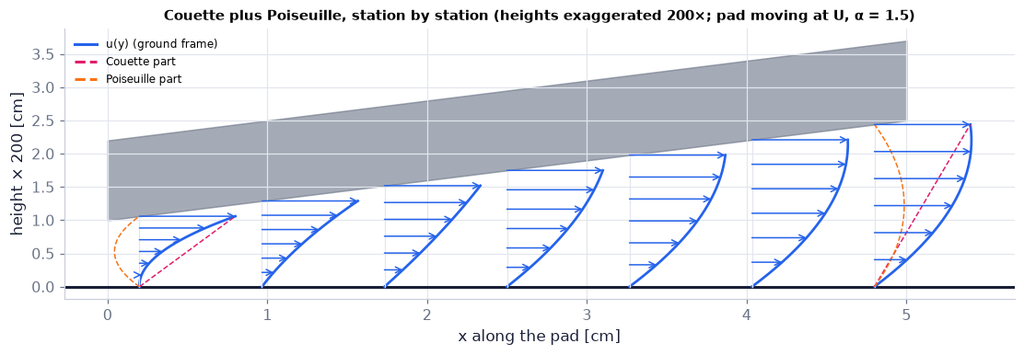

```python
h0, al, L, U, mu = 50e-6, 1.5, 0.05, 5.0, 0.05            # the slider gap of C07 with a steep taper α = 1.5
k = 200.0                                                 # vertical exaggeration of the drawing
fig, ax = plt.subplots(figsize=(10, 3.4))
xs = np.linspace(0, L, 200)                               # along the pad [m]
ax.fill_between(1e2*xs, k*h0*(1 + al*xs/L)*1e2, k*h0*(1 + al*xs/L)*1e2 + 1.2, color=COLORS["muted"], alpha=0.6)   # the pad
ax.axhline(0, color=COLORS["ink"], lw=2)                  # the floor
for x0 in np.linspace(0.04*L, 0.96*L, 7):                 # seven stations
    hx = h0*(1 + al*x0/L)                                 # local gap [m]
    yy = np.linspace(0, hx, 25)                           # heights across the gap [m]
    u = ch08.slider_gap_velocity(x0, yy, h0, al, L, U, mu=mu, frame="ground")   # (8.19) with the exact slider dp/dx [m/s]
    profile_arrows(ax, 1e2*k*yy, 1e2*0.12*u/U*L, x0=1e2*x0, every=4, color=COLORS["blue"])   # arrows ∝ u
for x0 in (0.04*L, 0.96*L):                               # the two parts at the narrowest and widest stations
    hx = h0*(1 + al*x0/L); yy = np.linspace(0, hx, 25)
    uc = U*yy/hx                                          # Couette part (the pad drags at U) [m/s]
    up = ch08.slider_gap_velocity(x0, yy, h0, al, L, U, mu=mu, frame="ground") - uc   # Poiseuille part [m/s]
    ax.plot(1e2*(x0 + 0.12*uc/U*L), 1e2*k*yy, color=COLORS["rose"], ls="--", lw=1)
    ax.plot(1e2*(x0 + 0.12*up/U*L), 1e2*k*yy, color=COLORS["orange"], ls="--", lw=1)
ax.set_xlabel("x along the pad [cm]"); ax.set_ylabel(f"height × {k:.0f} [cm]")
ax.set_title("Couette plus Poiseuille, station by station (heights exaggerated 200×; pad moving at U, α = 1.5)", fontsize=10)
ax.plot([], [], color=COLORS["blue"], label="u(y) (ground frame)"); ax.plot([], [], color=COLORS["rose"], ls="--", label="Couette part")
ax.plot([], [], color=COLORS["orange"], ls="--", label="Poiseuille part"); ax.legend(fontsize=8, loc="upper left")
savefig(fig, "ch08", "c06_gap_profiles"); plt.show()
```

**What you see.** Profiles in a gap that widens from h₀ at the left (the pad's trailing edge) to 2.5h₀ at the right (its leading edge), the pad moving right at U over a fixed floor: near the narrow end the profiles sag below the straight Couette line (the orange Poiseuille part points backward), near the wide end they bulge forward. The dashed rose and orange curves are the two parts at the end stations — our remake of Fig. 8.8.

**How to read it.** The pressure hump pushes fluid backward where it rises (from the narrow end up to the peak at x = L/(2 + α) ≈ 1.4 cm) and forward where it falls. In the ground frame the flux grows with the gap, $q=C_1+Uh$, because the pad-frame flux $C_1$ is the same at every station (D14).

**What would change if…** …the pad slid the other way (U < 0): every profile flips, and the pressure hump becomes a suction dip (C07).

> 🔁 **Tools from earlier chapters used here** (see `knowledge/primers.md`)
- **meshgrid, contour and streamplot** — `X, Y = np.meshgrid(x, y)` gives every point of a grid; `ax.contour(X, Y, psi, levels)` draws streamlines as lines of constant ψ (Ch. 2 P76, P78) — used in the Hele-Shaw figure below and again in §8.6.
- **observed order of convergence** — if an error behaves like C·Δᵖ, the slope of log(error) against log(Δ) is p; `observed_order` fits it (Ch. 1 P13, log–log slopes) — used in the grid check below and in C09, C15.

📝 **Note.** **N36 [B] · Hele-Shaw flow (Example 8.2): viscous flow that draws ideal streamlines.** Between two plates z = 0 and z = h the lubrication balances $0\cong-\frac1\rho\frac{\partial p}{\partial x}+\nu\frac{\partial^2u} {\partial z^2}$, $0\cong-\frac1\rho\frac{\partial p}{\partial y}+\nu\frac{\partial^2v}{\partial z^2}$, $0\cong-\frac1\rho\frac{\partial p}{\partial z}$ give the velocity below, with the potential $\phi=-\frac{z(h-z)}{2\mu}p$. Integrating continuity over the gap (the 2-D Reynolds equation with constant h, depth-averaged velocity $\bar{\mathbf u}=-\frac{h^2}{12\mu}\nabla p$) leaves $\frac{\partial^2p}{\partial x^2}+\frac{\partial^2p}{\partial y^2}=0$ — so φ obeys $u\equiv\partial\phi/\partial x,\ v\equiv\partial\phi/\partial y$ *(6.10)* and $\nabla^2\phi=0$ *(6.12)*, the equations of 2-D ideal flow (Ch. 6). Dye injected between glass plates therefore traces ideal-flow streamlines, except in layers of thickness ~h at obstacles, where no slip holds (Exercise 8.34). ⚠️ The book prints these lubrication equations without the ν, and writes the wall conditions at "y = 0, h" — the gap coordinate here is z.

$$ u\cong-\frac{1}{2\mu}\frac{\partial p}{\partial x}z(h-z)=\frac{\partial\phi}{\partial x},\qquad \phi=-\frac{z(h-z)}{2\mu}p $$

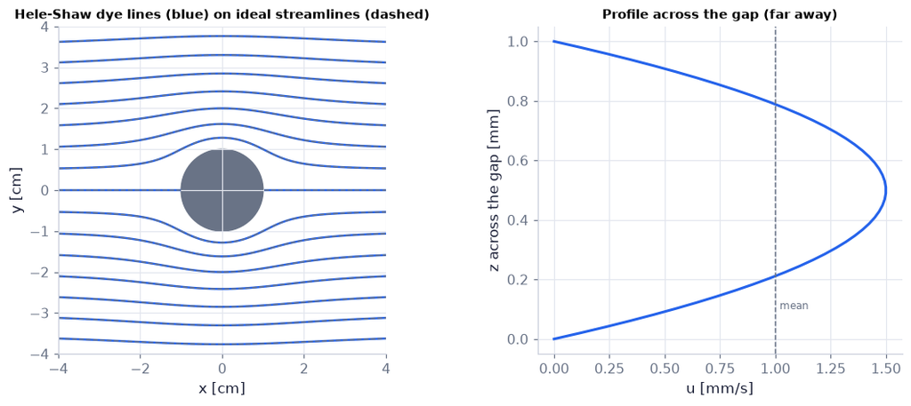

```python
a, gap, Um = 0.01, 1e-3, 1e-3                             # disc radius [m], plate gap [m], mean speed [m/s]
xg = np.linspace(-0.04, 0.04, 241 if not FAST else 121)   # a 8 cm × 8 cm window [m]
X, Y = np.meshgrid(xg, xg)                               # every point of the window
hs = ch08.hele_shaw_cylinder(X, Y, None, Um, a, gap)      # depth-averaged Hele-Shaw flow (z = None → gap average)
psi_ideal = PF.stream_function(PF.cylinder(Um, a), X, Y)  # Ch. 6: ideal flow past a circular cylinder
inside = X**2 + Y**2 < a**2                               # the disc
lev = np.linspace(-3.5e-5, 3.5e-5, 15)                    # streamline levels [m²/s]
fig, (a1, a2) = plt.subplots(1, 2, figsize=(10, 4.2), gridspec_kw=dict(width_ratios=[1.4, 1]))   # the figure and its panels
a1.contour(X*1e2, Y*1e2, np.where(inside, np.nan, hs["psi_mean"]), lev, colors=COLORS["blue"], linewidths=1.6)   # streamlines = lines of constant ψ
a1.contour(X*1e2, Y*1e2, np.where(inside, np.nan, psi_ideal), lev, colors=COLORS["muted"], linewidths=1, linestyles="--")   # streamlines = lines of constant ψ
a1.add_patch(plt.Circle((0, 0), a*1e2, color=COLORS["muted"]))   # the disc between the plates
a1.set_aspect("equal"); a1.set_xlabel("x [cm]"); a1.set_ylabel("y [cm]")   # labels with units
a1.set_title("Hele-Shaw dye lines (blue) on ideal streamlines (dashed)", fontsize=10)   # each panel says its message
z = np.linspace(0, gap, 50)                               # across the gap [m]
dpdx = -12*MU_W*Um/gap**2                                 # the far-field gradient that drives the mean speed Um [Pa/m]
u_z, _ = ch08.hele_shaw_velocity(z, gap, (dpdx, 0.0))     # the parabola across the gap [m/s]
a2.plot(1e3*u_z, 1e3*z, color=COLORS["blue"], lw=2); a2.axvline(1e3*Um, color=COLORS["muted"], ls="--", lw=1)   # reference line
a2.text(1e3*Um*1.02, 0.1, "mean", fontsize=8, color=COLORS["muted"])   # a label on the plot
a2.set_xlabel("u [mm/s]"); a2.set_ylabel("z across the gap [mm]"); a2.set_title("Profile across the gap (far away)", fontsize=10)   # labels with units
savefig(fig, "ch08", "c06_hele_shaw"); plt.show()        # save the PNG to outputs/ch08, then draw
```

**What you see.** The blue gap-averaged dye lines of Hele-Shaw flow lie exactly on the dashed ideal-flow streamlines round a cylinder, while across the 1 mm gap the flow is a viscous parabola — our remake of Fig. 8.10.

**How to read it.** The pressure is harmonic, so the depth-averaged velocity is a potential flow; only a thin layer at the disc (too thin to see here) differs, where no slip holds.

**What would change if…** …the gap were as wide as the disc: the ε ≪ 1 assumption fails, inertia and the no-slip layer spread, and the pattern loses its fore–aft symmetry.

**A numerical check (our route, not the book's).** `hele_shaw_streamfunction_grid` solves Laplace's equation for the gap-averaged stream function on a square grid with the disc cut out (Ch. 6's masked five-point solver) and compares it with the ideal-flow value away from the disc. The disc boundary is a staircase of grid cells, so the scheme is only **first order**: doubling the grid roughly halves the error.

```python
ns = (33, 65, 129) if not FAST else (33, 65)             # nodes per side of the square grid
errs, hs_ = [], []                                        # far-field error and grid step for each grid
for n_ in ns:                                            # each grid
    g_ = ch08.hele_shaw_streamfunction_grid(n=n_, a=1.0, U_mean=1.0, box=4.0)   # disc radius 1, box ±4 (non-dimensional)
    errs.append(g_["err_far"]); hs_.append(g_["h"])        # max |ψ − ψ_ideal| where r ≥ 2a, and the step
    print(f"n = {n_}: step {g_['h']:.3f}, max error {g_['err_far']:.2e}")   # show the numbers
print(f"observed order ≈ {observed_order(hs_, errs):.2f}  (first order: the staircase disc)")   # show the numbers
```

```
n = 33: step 0.250, max error 1.21e-01
n = 65: step 0.125, max error 5.86e-02
n = 129: step 0.062, max error 2.70e-02
observed order ≈ 1.08  (first order: the staircase disc)
```

**What would change if…** …the gap were the space under a real, tilted pad with the same pressure $p_e$ at both ends? The flux must be constant along the pad, which forces a pressure hump inside — and the hump carries a load (C07).

### 🧩 The slider bearing (Example 8.1) `C07`

*The question:* How does a thin viscous film carry a load — and why only in one direction?

*In one line:* $p-p_e=\frac{6\mu LU}{h_o^2}\frac{\alpha(x/L)(1-x/L)}{(2+\alpha)(1+\alpha x/L)^2}$ and, for a small taper, $W=\frac{\alpha\mu L^2U}{2h_o^2}$ (Example 8.1, denominator corrected to the square).

#### The problem in plain words

A tilted pad skates on a film of oil over a flat surface, as in the thrust bearing of a ship's propeller shaft or a hydroelectric turbine carrying hundreds of tonnes. The pad never touches the surface. Where does the upward force come from, and why does the bearing fail — the pad is sucked down — if it slides the wrong way?

#### The idea

```
            W ↓            pad moves → at U, wide end leading   (pad frame: floor moves ← at U)
p_e  ┌────────────────────────┐  p_e
     │ h₀ (x = 0)  →  h₀(1+α) (x = L) │
═════════════════════════════════   the floor drags oil in at the wide end, the narrow end lets less out
p(x):  ____/‾‾‾\____                ⇒ p rises until Poiseuille backflow evens the flux; ∫(p − p_e)dx = W
```

Same flux through a narrowing gap ⇒ the pressure must rise inside.

> 🔁 **Tools from earlier chapters used here** (see `knowledge/primers.md`)
- **antiderivatives of (1 + αx/L)⁻ⁿ** — substitute s = 1 + αx/L, ds = (α/L)dx: $\int(1+\alpha x/L)^{-n}dx=\frac L\alpha\frac{(1+\alpha x/L)^{1-n}}{1-n}$ for n ≠ 1 (Ch. 3 P106, substitution in an integral).
- **Taylor expansion in a small parameter α** — for small α, $(1+\alpha x/L)^{-2}\approx1-2\alpha x/L$ and $2+\alpha\approx2$: keep the first power of α (Ch. 1 P26, first-order Taylor).

#### 🧮 Derivation — The slider bearing: $p-p_e=\frac{6\mu LU}{h_o^2}\frac{\alpha(x/L)(1-x/L)}{(2+\alpha)(1+\alpha x/L)^2}$ and $W=\frac{\alpha\mu L^2U}{2h_o^2}$ `D14`

**What we want to show.** Find the pressure under a sloped pad sliding at U over a flat surface, and the load it carries.

**Assumptions.** Steady in the pad frame (step 1); lubrication profile (step 3); α ≪ 1 used only at step 15.

**The plan.**

1. Conserve mass in a CV riding with the pad.
2. Turn it into an ODE for p.
3. Integrate with the two end pressures.
4. Simplify, then expand for small α and integrate for W.

**Tools we use** (each explained before this point): moving control volume (Ch. 4 §4.2) · gap flux (D13 steps 9–10) · antiderivatives of (1 + αx/L)⁻ⁿ (gloss) · 2 × 2 system · Taylor in α (P26).

**We start from**

$$ h(x)=h_o\Big(1+\frac{\alpha x}{L}\Big),\ \ u(x,0)=0,\ \ u(x,h)=U,\ \ p(0)=p(L)=p_e,\qquad \frac{d}{dt}\int_{V^*(t)}\rho\,dV+\int_{A^*(t)}\rho\,(\mathbf u-\mathbf b)\cdot\mathbf n\,dA=0\ \text{(4.5)} $$

*In words:* a sloped pad sliding at U over a floor at rest, the same pressure at both ends, and the control-volume mass balance

**Step 1 of 16 — Balance mass in a pad-fixed CV.**

$$ \rho B\Big[-\int_0^{h(x_1)}(u-U)dy+\int_0^{h(x_2)}(u-U)dy\Big]=0 $$

- *Why we can do this:* (4.5), $\frac{d}{dt}\int_{V^*(t)}\rho\,dV+\int_{A^*(t)}\rho\,(\mathbf u-\mathbf b)\cdot\mathbf n\,dA=0$ for a CV of fixed shape moving at b = U e_x: its mass is constant, and the flux through a face uses the relative speed u − U.
- *In words:* what enters the slice leaves it.

**Step 2 of 16 — Shrink the slice.**

$$ \frac{d}{dx}\int_0^{h}(u-U)dy=0\ \Rightarrow\ \int_0^h(u-U)dy=C_1 $$

- *Why we can do this:* Divide by ρB(x₂ − x₁) and let x₂ → x₁: a derivative of zero means a constant.
- *In words:* the pad-frame flux C₁ is the same everywhere.

**Step 3 of 16 — Insert the profile's flux.**

$$ \int_0^hu\,dy=-\frac{h^3}{12\mu}\frac{dp}{dx}+\frac{Uh}{2} $$

- *Why we can do this:* D13 steps 9–11 with U₀ = 0, U_h = U.
- *In words:* ground-frame flux.

**Step 4 of 16 — Subtract Uh.**

$$ C_1=-\frac{h^3}{12\mu}\frac{dp}{dx}-\frac{Uh}{2} $$

- *Why we can do this:* The pad speed U is the same at every height, so ∫₀^h U dy = Uh; subtracting it gives the pad-frame flux.
- *In words:* the book's C₁ equation.

**Step 5 of 16 — Solve for the pressure gradient.**

$$ \frac{dp}{dx}=-\frac{12\mu C_1}{h^3}-\frac{6\mu U}{h^2} $$

- *Why we can do this:* Rearrange step 4; this is a first-order ODE for p once h(x) is known.
- *In words:* the pressure slope depends on the local gap.

**Step 6 of 16 — Insert the gap shape.**

$$ \frac{dp}{dx}=-\frac{12\mu C_1}{h_o^3}\Big(1+\frac{\alpha x}{L}\Big)^{-3}-\frac{6\mu U}{h_o^2} \Big(1+\frac{\alpha x}{L}\Big)^{-2} $$

- *Why we can do this:* h = h₀(1 + αx/L). The book's intermediate line prints (1 − αx/L); the gap of the problem needs 1 + αx/L.
- *In words:* two powers of the gap.

**Step 7 of 16 — Integrate in x.**

$$ p=\frac{6\mu LC_1}{\alpha h_o^3}\Big(1+\frac{\alpha x}L\Big)^{-2}+\frac{6\mu UL}{\alpha h_o^2}\Big(1+ \frac{\alpha x}L\Big)^{-1}+C_2 $$

- *Why we can do this:* ∫(1 + αx/L)⁻ⁿdx = (L/α)(1 + αx/L)^(1−n)/(1 − n) for n = 3, 2 (substitute s = 1 + αx/L).
- *In words:* pressure with two unknown constants.

**Step 8 of 16 — Apply p(0) = p_e.**

$$ p_e=\frac{6\mu L}{\alpha h_o^2}\Big[\frac{C_1}{h_o}+U\Big]+C_2 $$

- *Why we can do this:* At x = 0 both powers equal 1.
- *In words:* first end condition.

**Step 9 of 16 — Apply p(L) = p_e.**

$$ p_e=\frac{6\mu L}{\alpha h_o^2}\Big[\frac{C_1}{h_o(1+\alpha)^2}+\frac{U}{1+\alpha}\Big]+C_2 $$

- *Why we can do this:* At x = L the gap is h₀(1 + α).
- *In words:* second end condition.

**Step 10 of 16 — Subtract to find C₁.**

$$ C_1=-\frac{1+\alpha}{2+\alpha}Uh_o $$

- *Why we can do this:* C₂ cancels: (C₁/h₀)[1 − (1+α)⁻²] + U[1 − (1+α)⁻¹] = 0, i.e. (C₁/h₀)α(2+α)/(1+α)² = −Uα/(1+α).
- *In words:* the pad-frame flux (negative: toward the narrow end).

**Step 11 of 16 — Back-substitute for C₂.**

$$ C_2=p_e-\frac{6\mu LU}{\alpha h_o^2}\cdot\frac{1}{2+\alpha} $$

- *Why we can do this:* Step 8 with C₁: U − (1 + α)U/(2 + α) = U/(2 + α).
- *In words:* the book's C₂.

**Step 12 of 16 — Substitute C₁ and C₂ into step 7.**

$$ p-p_e=\frac{6\mu LU}{\alpha h_o^2}\Big[-\frac{1+\alpha}{(2+\alpha)(1+s)^2}+\frac{1}{1+s}-\frac{1}{2+\alpha}\Big],\ \ s=\frac{\alpha x}{L} $$

- *Why we can do this:* Insert C₁ = −(1 + α)Uh₀/(2 + α) and C₂ from step 11 into step 7 and subtract p_e; the factor 6μLU/(αh₀²) comes out of all three terms. (Part F went straight to the common denominator; this step is added so that each line follows from the one above.)
- *In words:* three simple fractions in s = αx/L.

**Step 13 of 16 — Put p − p_e over one denominator.**

$$ p-p_e=\frac{6\mu LU}{\alpha h_o^2}\cdot\frac{s(\alpha-s)}{(2+\alpha)(1+s)^2},\ \ s=\frac{\alpha x}{L} $$

- *Why we can do this:* Multiply each fraction up to the common denominator (2 + α)(1 + s)²; the numerator −(1 + α) + (2 + α)(1 + s) − (1 + s)² expands to −1 − α + 2 + 2s + α + αs − 1 − 2s − s² = αs − s² = s(α − s).
- *In words:* the "some algebra" of the book, done.

**Step 14 of 16 — Write s back in terms of x.**

$$ p-p_e=\frac{6\mu LU}{h_o^2}\frac{\alpha(x/L)(1-x/L)}{(2+\alpha)(1+\alpha x/L)^2} $$

- *Why we can do this:* s(α − s) = α²(x/L)(1 − x/L); one α cancels. The printed result has the denominator to the first power; only the square satisfies step 5.
- *In words:* the exact pressure hump.

**Step 15 of 16 — Keep the linear term in α.**

$$ p-p_e\cong\frac{3\alpha\mu LU}{h_o^2}\frac xL\Big(1-\frac xL\Big) $$

- *Why we can do this:* An extra approximation, not required by lubrication (the wall slope αh₀/L is tiny for any α of order one): for α ≪ 1, (2 + α)(1 + αx/L)² ≈ 2. It costs accuracy — the linear load is 15.6 % high at α = 0.1 (N35, printed in C07).
- *In words:* a symmetric parabola.

**Step 16 of 16 — Integrate for the load.**

$$ W=\int_0^L(p-p_e)dx=\frac{3\alpha\mu LU}{h_o^2}\cdot\frac L6=\frac{\alpha\mu L^2U}{2h_o^2} $$

- *Why we can do this:* ∫₀^L (x/L)(1 − x/L)dx = L/2 − L/3 = L/6.
- *In words:* the load per unit width.

**Result**

$$ \begin{array}{l}p-p_e=\frac{6\mu LU}{h_o^2}\frac{\alpha(x/L)(1-x/L)}{(2+\alpha)(1+\alpha x/L)^2}\ \ \text{(exact)} \\ p-p_e\cong\frac{3\alpha\mu LU}{h_o^2}\frac xL\Big(1-\frac xL\Big),\qquad W=\frac{\alpha\mu L^2U}{2h_o^2}\ \ (\alpha\ll1)\end{array} $$

*In words:* a constant flux through a narrowing gap needs a pressure hump, and the hump carries the pad.

**Check it.** p(0) = p(L) = p_e ✓ (the printed first-power form also meets them, but it fails step 5's ODE); units μLU/h₀²: (Pa s)(m)(m/s)/m² = Pa ✓; W in Pa·m = N/m ✓; αU < 0 ⇒ W < 0. Numbers (the code cell after the tiny example of C07 prints them): L = 5 cm, h₀ = 50 µm, U = 5 m/s, μ = 0.05 Pa s, α = 0.1 → W = 12.5 kN/m (linear), 10.8 kN/m (exact, N35).

```python
sb = ch08.slider_bearing_sympy()                         # D14 steps 5–15 rebuilt symbolically (cached)
x_, L_, h0_, mu_, U_, al_, pe_ = sb["symbols"]           # x, L, h₀, μ, U, α, p_e
print("C1 =", sp.simplify(sb["C1"]))                     # step 10: −(1 + α)U h₀/(2 + α)
print("C2 =", sp.simplify(sb["C2"]))                     # step 11
assert sp.simplify(sb["ode_residual_exact"]) == 0        # the squared denominator satisfies dp/dx = −12μC₁/h³ − 6μU/h² (step 5)
assert sp.simplify(sb["ode_residual_book"]) != 0         # the printed first-power form does not
assert all(sp.simplify(r_) == 0 for r_ in sb["bc_residuals"])   # p(0) = p(L) = p_e
print("W_linear =", sb["W_linear"])                      # step 15: αμL²U/(2h₀²)
print("W_exact  =", sb["W_exact_series"])                # N35's exact load expanded in α: starts with W_linear
# rebuild steps 5–10 here: integrate step 5's ODE and let the two end pressures choose C₁
C1_, xx_ = sp.symbols("C_1 x_")                          # the unknown pad-frame flux and a dummy integration variable
h_x = h0_*(1 + al_*xx_/L_)                               # step 6: the gap h₀(1 + αx/L)
dpdx_ = -12*mu_*C1_/h_x**3 - 6*mu_*U_/h_x**2             # step 5: dp/dx = −12μC₁/h³ − 6μU/h²
rise = sp.integrate(dpdx_, (xx_, 0, L_))                 # steps 7–9: p(L) − p(0) for any C₁
C1_hand = sp.solve(sp.Eq(rise, 0), C1_)[0]               # step 10: equal end pressures fix C₁
print("C1 by hand:", sp.simplify(C1_hand))
assert sp.simplify(C1_hand + (1 + al_)*U_*h0_/(2 + al_)) == 0   # = −(1 + α)U h₀/(2 + α)
```

```
C1 = U*h_0*(-alpha - 1)/(alpha + 2)
C2 = (-6*L*U*mu + alpha**2*h_0**2*p_e + 2*alpha*h_0**2*p_e)/(alpha*h_0**2*(alpha + 2))
W_linear = L**2*U*alpha*mu/(2*h_0**2)
W_exact  = L**2*U*alpha*mu/(2*h_0**2) - 3*L**2*U*alpha**2*mu/(4*h_0**2) + 33*L**2*U*alpha**3*mu/(40*h_0**2) - 13*L**2*U*alpha**4*mu/(16*h_0**2) + O(alpha**5)
```

```
C1 by hand: -U*h_0*(alpha + 1)/(alpha + 2)
```

> ⚠️ **Common confusion (traps in `D14`):** The pad frame makes the flow steady; the integrands carry (1 + αx/L), not the printed (1 − αx/L); the final denominator is squared; α ≪ 1 enters only at step 15.

> ⚠️ **Common confusion:** **two printing slips in Example 8.1.** The intermediate integrals are printed with $(1-\alpha x/L)$, although the gap is $h_o(1+\alpha x/L)$; and the final exact pressure is printed with $(1+\alpha x/L)$ to the first power in the denominator. Substituting back into $dp/dx=-12\mu C_1/h^3-6\mu U/h^2$ shows the denominator must be **squared** (D14 step 14, checked above). The printed C₁, C₂, the linear-α pressure and the load W are right.

#### ✏️ Tiny example: a 5 cm pad on a 50 µm film

L = 0.05 m, h₀ = 50 µm, U = 5 m/s, μ = 0.05 Pa s, α = 0.1.

1. Scale: $6\mu LU/h_o^2=6\times0.05\times0.05\times5/(2.5\times10^{-9})=3\times10^7$ Pa.
2. At the middle x = L/2: $\frac{\alpha(x/L)(1-x/L)}{(2+\alpha)(1+\alpha/2)^2}=\frac{0.1\times0.25}{2.1\times1.1025}=0.0108$ ⇒ p − p_e = 3.24 × 10⁵ Pa ≈ 3.2 atm.
3. Linear formula: $\frac{3\alpha\mu LU}{h_o^2}\times0.25=3.75\times10^5$ Pa.
4. Load $W=\alpha\mu L^2U/(2h_o^2)=0.1\times0.05\times0.0025\times5/(5\times10^{-9})=1.25\times10^4$ N/m — 12.5 kN per metre of pad width, about 1.3 tonnes.
5. Reverse the motion (U = −5 m/s): W = −12.5 kN/m, the pad is pulled down.

> 🔁 **Tools from earlier chapters used here** (see `knowledge/primers.md`)
- **scipy.optimize.minimize_scalar** — `optimize.minimize_scalar(f, bounds=(a, b), method="bounded")` finds the minimum of a one-variable function; to maximise W we minimise −W (Ch. 7 P170).
- **np.log1p and cancellation for small α** — `np.log1p(a)` computes ln(1 + a) accurately for tiny a, where 1 + a loses digits — the same cancellation problem as `np.expm1` (Ch. 3 P107); the exact load uses a series for |α| < 10⁻³.

```python
L, h0, U, mu = 0.05, 50e-6, 5.0, 0.05                    # the pad of the tiny example
for model in ("exact", "linear", "book"):                # corrected exact, O(α), and the printed slip (a ghost)
    print(f"{model:6s} p(L/2) − p_e = {ch08.slider_bearing(0.025, h0, 0.1, L, U, mu=mu, model=model):.4g} Pa")
st = ch08.slider_bearing_state(h0, 0.1, L, U, mu=mu)     # everything the explainer shows
print({k: (round(st[k], 7) if not isinstance(st[k], bool) else st[k]) for k in
       ("C1", "p_max", "x_pmax", "W_exact", "W_linear", "err_linear", "p_max_atm", "backflow_any", "backflow_x")})
print(ch08.slider_optimum_taper())                       # the taper that maximises the exact load
print("reversed U:", ch08.slider_bearing_load(h0, 0.1, L, -U, mu=mu, model="linear"), "N/m")   # suction
```

```
exact  p(L/2) − p_e = 3.239e+05 Pa
linear p(L/2) − p_e = 3.75e+05 Pa
book   p(L/2) − p_e = 3.401e+05 Pa
{'C1': -0.000131, 'p_max': 324675.3246753, 'x_pmax': 0.0238095, 'W_exact': 10812.6849344, 'W_linear': 12500.0, 'err_linear': 15.6049591, 'p_max_atm': 3.2042963, 'backflow_any': False, 'backflow_x': nan}
{'alpha_opt': 1.188704808725747, 'K_opt': 2.1887048087257472, 'W_star': 0.026707190223070765, 'W_coefficient': 0.1602431413384246}
reversed U: -12500.000000000002 N/m
```

**What does the code above do?**

1. The three models at mid-pad: exact 3.239 × 10⁵ Pa, linear 3.75 × 10⁵ Pa, and the printed first-power form 3.401 × 10⁵ Pa — 5 % off, and (D14 check) it does not satisfy the pressure equation.
2. The state: the pad-frame flux C₁ = −1.310 × 10⁻⁴ m²/s, the peak 3.247 × 10⁵ Pa at x = 2.38 cm (x/L = 0.476, just before mid-pad), the exact load 10.8 kN/m against the linear 12.5 kN/m — the linear one 15.6 % high — the peak in atmospheres, and no recirculation at the wide end (`backflow_any = False`: the gap ratio 1 + α = 1.1 is below 2, see the note after N35).
3. `slider_optimum_taper` maximises the exact load: α = 1.189, inlet/outlet gap ratio 1 + α = 2.189, dimensionless load W h₀²/(6μUL²) = 0.02671 (the San Andrés benchmark).
4. Reversing U turns the load negative: the pad is sucked down.

```python
h_ = lambda x_: h0*(1 + 0.1*x_/L)                        # the gap h₀(1 + αx/L), α = 0.1 [m]
dpdx = lambda x_, C1: -12*mu*C1/h_(x_)**3 - 6*mu*U/h_(x_)**2   # D14 step 5 (ground frame) [Pa/m]
C1 = optimize.brentq(lambda C: integrate.quad(lambda x_: dpdx(x_, C), 0, L)[0], -U*h0, 0.0)   # choose C₁ so p(L) = p(0)
x = np.linspace(0, L, 401)                               # stations [m]
p_mine = integrate.cumulative_trapezoid(dpdx(x, C1), x, initial=0)   # p − p_e by integrating the ODE
print(f"C1 by root finding = {C1:.6g} m²/s (library {st['C1']:.6g}); max |Δp| = {np.max(np.abs(p_mine - ch08.slider_bearing(x, h0, 0.1, L, U, mu=mu))):.2f} Pa")
assert np.allclose(C1, st["C1"], rtol=1e-8)              # same flux constant
assert np.allclose(p_mine, ch08.slider_bearing(x, h0, 0.1, L, U, mu=mu), rtol=1e-6, atol=1.0)   # same pressure hump
```

```
C1 by root finding = -0.000130952 m²/s (library -0.000130952); max |Δp| = 0.78 Pa
```

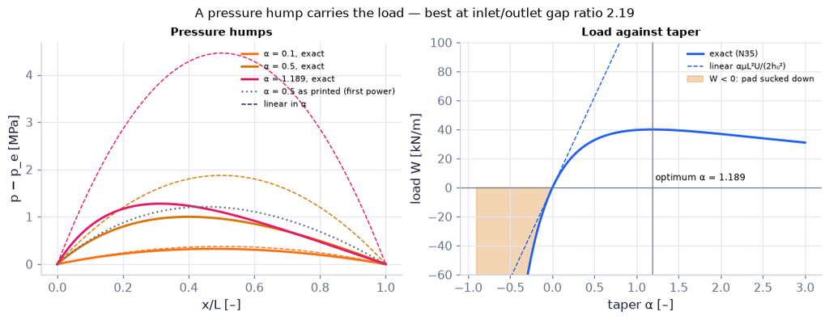

```python
L, h0, U, mu = 0.05, 50e-6, 5.0, 0.05                    # the pad: length [m], film [m], speed [m/s], oil viscosity [Pa s]
x = np.linspace(0, L, 400)                                # along the pad [m]
fig, (a1, a2) = plt.subplots(1, 2, figsize=(10, 3.8))    # the figure and its panels
for al, c in ((0.1, COLORS["orange"]), (0.5, COLORS["amber"]), (1.189, COLORS["rose"])):   # three tapers
    a1.plot(x/L, ch08.slider_bearing(x, h0, al, L, U, mu=mu)/1e6, color=c, lw=2, label=f"α = {al:g}, exact")   # a curve (its label says which)
    a1.plot(x/L, ch08.slider_bearing(x, h0, al, L, U, mu=mu, model="linear")/1e6, color=c, lw=1, ls="--")   # a curve (its label says which)
a1.plot(x/L, ch08.slider_bearing(x, h0, 0.5, L, U, mu=mu, model="book")/1e6, color=COLORS["muted"], lw=1.5, ls=":",   # a curve (its label says which)
        label="α = 0.5 as printed (first power)")        # (continued)
a1.plot([], [], color=COLORS["ink"], ls="--", lw=1, label="linear in α")   # a curve (its label says which)
a1.set_xlabel("x/L [–]"); a1.set_ylabel("p − p_e [MPa]"); a1.legend(fontsize=7); a1.set_title("Pressure humps", fontsize=10)   # labels with units
als = np.linspace(-0.9, 3.0, 200)                         # tapers, including negative (pad sliding the wrong way)
W_ex = np.array([ch08.slider_bearing_load(h0, a_, L, U, mu=mu) for a_ in als])       # N35 exact load [N/m]
W_li = np.array([ch08.slider_bearing_load(h0, a_, L, U, mu=mu, model="linear") for a_ in als])   # the linear-α load [N/m]
opt = ch08.slider_optimum_taper()                        # the taper with the largest exact load
a2.plot(als, W_ex/1e3, color=COLORS["blue"], lw=2, label="exact (N35)")   # a curve (its label says which)
a2.plot(als, W_li/1e3, color=COLORS["blue"], lw=1, ls="--", label="linear αμL²U/(2h₀²)")   # a curve (its label says which)
a2.axvline(opt["alpha_opt"], color=COLORS["muted"], lw=0.8)   # reference line
a2.text(opt["alpha_opt"]*1.03, 5, f"optimum α = {opt['alpha_opt']:.3f}", fontsize=8)   # a label on the plot
a2.fill_between(als, W_ex/1e3, 0, where=als < 0, color=COLORS["amber"], alpha=0.3, label="W < 0: pad sucked down")   # a filled shape
a2.axhline(0, color=COLORS["muted"], lw=0.8); a2.set_ylim(-60, 100)   # reference line
a2.set_xlabel("taper α [–]"); a2.set_ylabel("load W [kN/m]"); a2.legend(fontsize=7); a2.set_title("Load against taper", fontsize=10)   # labels with units
fig.suptitle("A pressure hump carries the load — best at inlet/outlet gap ratio 2.19", fontsize=11)   # the figure's message
savefig(fig, "ch08", "c07_slider_pressure"); plt.show()  # save the PNG to outputs/ch08, then draw
```

**What you see.** (a) pressure humps peaking before mid-pad (at x = L/(2 + α)) and growing with α, their linear-α parabolas (dashed) and the printed first-power form for α = 0.5 (dotted grey) missing the exact hump; (b) the exact load curve bending over and peaking near α = 1.19, while the linear formula keeps rising — our remake of Fig. 8.9 `N105`.

**How to read it.** The load is the area under a hump; the linear formula is fine only for α ≲ 0.1 — 15.6 % high at 0.1, about 90 % high at 0.5; negative α (shaded) means the pad slides with its narrow end leading and is pulled down.

**What would change if…** …the film were halved to 25 µm: every pressure and the load grow 4× (∝ 1/h₀²) — the bearing is "stiff": extra load squeezes the film and raises the capacity.

📝 **Note.** **N35 [B] · The exact load for any taper (ours; the book stops at linear α).** Integrating the exact pressure gives W below, which tends to $\alpha\mu L^2U/(2h_o^2)$ as α → 0 (the series of ln(1 + α)). It peaks at an inlet/outlet gap ratio 1 + α = 2.189 — the classic optimum of lubrication texts (San Andrés, benchmark V5). With our numbers: α = 0.1 → 12.5 kN/m (linear) vs 10.8 kN/m (exact); α = 0.5 → 62.5 vs 32.8 kN/m.

$$ W=\frac{6\mu UL^2}{h_o^2\alpha^2}\Big[\ln(1+\alpha)-\frac{2\alpha}{2+\alpha}\Big] $$

```python
W_formula = ch08.slider_bearing_load(h0, 0.5, L, U, mu=mu)     # N35 for α = 0.5 [N/m]
W_quad = integrate.quad(lambda xx: ch08.slider_bearing(xx, h0, 0.5, L, U, mu=mu), 0, L)[0]   # ∫(p − p_e)dx numerically
print(f"W (formula) = {W_formula:.5g} N/m, W (quad) = {W_quad:.5g} N/m")   # both 3.279e4
```

```
W (formula) = 32791 N/m, W (quad) = 32791 N/m
```

**When does the oil recirculate under the pad?** (ours; the book does not ask). In the pad frame the floor moves at −U and the pad is still. With η = y/h and $h_m=\frac{2(1+\alpha)}{2+\alpha}h_o$ the gap at the pressure peak (where dp/dx = 0, i.e. $C_1=-Uh_m/2$), the lubrication profile with the slider's pressure gradient becomes $$\frac{u-U}{U}=-(1-\eta)+3\Big(1-\frac{h_m}{h}\Big)\eta(1-\eta)=(1-\eta)\Big[-1+3\Big(1-\frac{h_m}{h}\Big)\eta\Big].$$ Next to the pad (η → 1) the bracket is $-1+3(1-h_m/h)$, so the fluid there moves *against* the floor — a recirculation — exactly when $h>\tfrac32h_m$. The largest gap is the worst place: the **wide end**. For α > 0 it is x = L with $h=h_o(1+\alpha)$, and $h/h_m=(2+\alpha)/2>3/2\iff\alpha>1$; for α < 0 it is x = 0 with $h=h_o$, and $h/h_m=\frac{2+\alpha}{2(1+\alpha)}>\frac32\iff\alpha<-\tfrac12$. Both say the same thing: **recirculation at the wide end iff the wide/narrow gap ratio exceeds 2**.

```python
for al in (0.1, 0.99, 1.01, 1.5, -0.45, -0.55, -0.7):    # tapers either side of the two thresholds α = 1 and α = −½
    st_ = ch08.slider_bearing_state(h0, al, L, U, mu=mu)  # the library's verdict (checked against the profile's sign in the tests)
    ratio = max(1 + al, 1/(1 + al))                       # wide/narrow gap ratio
    print(f"α = {al:+.2f}: gap ratio {ratio:.2f}, recirculation {st_['backflow_any']}"
          + (f" at x = {100*st_['backflow_x']:.0f} cm" if st_["backflow_any"] else ""))   # where: the wide end
```

```
α = +0.10: gap ratio 1.10, recirculation False
α = +0.99: gap ratio 1.99, recirculation False
α = +1.01: gap ratio 2.01, recirculation True at x = 5 cm
α = +1.50: gap ratio 2.50, recirculation True at x = 5 cm
α = -0.45: gap ratio 1.82, recirculation False
α = -0.55: gap ratio 2.22, recirculation True at x = 0 cm
α = -0.70: gap ratio 3.33, recirculation True at x = 0 cm
```

```python
L, h0, U, mu = 0.05, 50e-6, 5.0, 0.05                    # the pad: length [m], film [m], speed [m/s], oil viscosity [Pa s]
xs = np.linspace(0, L, 150)                              # stations [m]


def frame(al):                                            # curves for one taper α
    return {"exact": (xs/L, ch08.slider_bearing(xs, h0, al, L, U, mu=mu)/1e6),   # the curves of this position
            "linear in α": (xs/L, ch08.slider_bearing(xs, h0, al, L, U, mu=mu, model="linear")/1e6),   # (continued)
            "as printed (first power)": (xs/L, ch08.slider_bearing(xs, h0, al, L, U, mu=mu, model="book")/1e6)}   # (continued)


als = np.linspace(-0.8, 3.0, 20 if not FAST else 10)      # slider values α [–]
fig = slider_figure(frame, "α", als, unit="", xlabel="x/L [–]", ylabel="p − p_e [MPa]", title="", yrange=[-2.0, 2.5])   # precompute every slider/time position
titles = []                                               # the two loads in each title
for al in als:                                           # every slider value
    s_ = ch08.slider_bearing_state(h0, al, L, U, mu=mu)   # loads for this taper
    titles.append(f"α = {al:.2f}: W exact = {s_['W_exact']/1e3:.1f} kN/m, W linear = {s_['W_linear']/1e3:.1f} kN/m")   # the title for this step
step_titles(fig, titles)                                 # numbers that follow the slider
recolor(fig, {"exact": COLORS["orange"], "linear in α": COLORS["orange"], "as printed (first power)": COLORS["muted"]},   # colours by meaning (as in the static figures)
        {"linear in α": "dash", "as printed (first power)": "dot"})   # (continued)
fig.show()                                               # draw the interactive figure
```

[interactive chart not shown]

**What does the code above do?**

Each slider step is one taper α from −0.8 to 3; the title prints the exact and linear loads. For α < 0 the hump becomes a suction dip (and below α = −½ the oil also recirculates at the wide end, now x = 0); for large α the linear formula wildly overestimates the load; the grey dotted "as printed" curve meets both end pressures but is the wrong shape.

> 🔁 **Tools from earlier chapters used here** (see `knowledge/primers.md`)
- **live widgets** — `live(fn, name=(min, max, step), …)` makes sliders that call fn when released — only with a running kernel; the plotly figure above carries the same idea on the web page (Ch. 1 P47).

> ▶️ **Live cell.** The widget below needs a running Python kernel. On the web page it is frozen — open this notebook in Colab (button at the top) or run it locally to drag the sliders.

```python
def bearing(h0_um=50.0, alpha=0.5, U=5.0, mu=0.05):      # film thickness [µm], taper, sliding speed [m/s], oil viscosity [Pa s]
    s_ = ch08.slider_bearing_state(h0_um*1e-6, alpha, 0.05, U, mu=mu)   # a 5 cm pad
    print(f"p_max = {s_['p_max']/1e5:.3g} bar at x/L = {s_['x_pmax']/0.05:.3f}; W exact = {s_['W_exact']/1e3:.3g} kN/m, "   # show the numbers
          f"W linear = {s_['W_linear']/1e3:.3g} kN/m ({s_['err_linear']:.1f} % off); recirculation at the wide end: {s_['backflow_any']}")   # (continued)


live(bearing, h0_um=(10, 200, 5), alpha=(-0.8, 3.0, 0.05), U=(-10, 10, 0.5), mu=(0.005, 0.5, 0.005))   # sliders for the four inputs (kernel only)
```

▶️ **Live cell.** These sliders need a running Python kernel, so they are frozen on this page. Press **Open in Colab** at the top (or run the notebook locally) to use them.

#### 🎮 Interactive: How does a film thinner than a hair carry a load?

**Why interactive rather than a static figure:** Drag the taper and flip the sliding direction: the pressure hump, the station-by-station Couette-plus-Poiseuille profiles and the load change together, the printed-slip ghost visibly departs from the exact hump, and once the wide end is more than twice the narrow gap (α > 1, or α < −½) a small recirculation appears at the wide end — the whole of Example 8.1 in one picture.

**What to try:**

- Set α = 0.1 and compare the exact and linear humps; then α = 1.19 (the optimum) and read the load.
- Flip U to negative: the hump turns into suction and the status says the pad is sucked down.
- Choose 'compare': the printed curve meets both end pressures but sits above the exact one — it fails the pressure equation.
- Push α past 1 and look at the profiles at the wide end in the pad frame: a backward-moving layer appears under the pad.
- Set α = −0.7: the wide end is now at x = 0, and the recirculation appears there (gap ratio 1/0.3 > 2).

```python
show_viz("ch08", "slider_bearing")   # full-width explainer; ⤢ Full screen for more room
```

🎮 Interactive 3/9 How does a film thinner than a hair carry a load? Open alone ↗

[interactive chart not shown]

**What would change if…** …there were no upper wall at all — a free surface — and gravity, not a pressure applied at the ends, pushed the fluid? The thin-layer balance still holds, with the hydrostatic pressure of the layer itself (C08).

### 🧩 The thin-film equation (Example 8.3) `C08`

*The question:* What equation governs a thin viscous layer spreading under its own weight?

*In one line:* $\frac{\partial h}{\partial t}=\frac{\rho g}{3\mu}\frac{\partial}{\partial x}\Big(h^3\frac{\partial h}{\partial x}\Big)$ (Example 8.3) — a diffusion equation whose diffusivity $\rho gh^3/3\mu$ depends on the thickness itself.

#### The problem in plain words

Honey poured on a plate, paint on a wall, a lava lobe, a mud flow, and — with a stiffer, nonlinear rheology — an ice sheet: a thin layer of very viscous fluid spreads because its own weight presses harder where it is thicker. We want one equation for the thickness h(x, t) that predicts the spreading.

#### The idea

```
     h ↑   ____
          /    \      p = ρg(h − y): higher under the crest
         /      \     flux q = −(ρg/3μ) h³ ∂h/∂x   ← h³: a thin film barely moves
════════╱════════╲════════
```

Thick places have higher hydrostatic pressure, so fluid is pushed from thick to thin; the flux is choked as the layer thins.

> 🔁 **Tools from earlier chapters used here** (see `knowledge/primers.md`)
- **hydrostatic pressure in a thin layer, stress-free surface** — at a free surface with negligible air drag the shear stress vanishes, μ∂u/∂y = 0; in a thin, slowly varying layer the vertical balance is hydrostatic, p = p_a + ρg(h − y) — valid because the slope is small (the lubrication ordering of C05), not merely because accelerations are ignored (Ch. 1 P20, boundary conditions).

#### 🧮 Derivation — The thin-film equation $\frac{\partial h}{\partial t}=\frac{\rho g}{3\mu}\frac{\partial}{\partial x}\big(h^3\frac{\partial h}{\partial x}\big)$ (Example 8.3) `D15`

**What we want to show.** Find one equation for the thickness of a thin viscous layer spreading under its own weight.

**Assumptions.** Small slope and no inertia (lubrication, steps 3, 5); no surface tension; 2-D; air drag negligible (step 7).

**The plan.**

1. Conserve mass in a slice.
2. Get the pressure gradient from hydrostatics.
3. Fix A and B with no slip below and no stress on top.
4. Integrate the profile and insert.

**Tools we use** (each explained before this point): CV mass (Ch. 4 §4.2) · hydrostatic thin layer and stress-free surface (gloss in C08) · polynomial integral.

**We start from**

$$ \frac{d}{dt}\int_{V^*(t)}\rho\,dV+\int_{A^*(t)}\rho\,(\mathbf u-\mathbf b)\cdot\mathbf n\,dA=0\ \text{(4.5)},\qquad u(x,y,t)\cong\frac1\mu\frac{\partial p(x,t)}{\partial x}\frac{y^2}{2}+Ay+B\ \text{(8.18)} $$

*In words:* the control-volume mass balance on a slice of width dx, and the generic lubrication profile

**Step 1 of 10 — Balance mass in a slice.**

$$ \rho\frac{\partial h}{\partial t}dx-\int_0^{h(x)}\rho u\,dy+\int_0^{h(x+dx)}\rho u\,dy=0 $$

- *Why we can do this:* (4.5), $\frac{d}{dt}\int_{V^*(t)}\rho\,dV+\int_{A^*(t)}\rho\,(\mathbf u-\mathbf b)\cdot\mathbf n\,dA=0$ for a fixed slice of width dx and unit depth: storage change plus net outflow is zero.
- *In words:* the layer thickens where more enters than leaves.

**Step 2 of 10 — Divide by ρ dx and shrink.**

$$ \frac{\partial h}{\partial t}+\frac{\partial}{\partial x}\int_0^hu\,dy=0 $$

- *Why we can do this:* The difference of the two integrals over dx becomes an x-derivative as dx → 0.
- *In words:* thickness changes by flux divergence.

**Step 3 of 10 — Write the hydrostatic pressure.**

$$ p=p_a+\rho g(h-y) $$

- *Why we can do this:* In a thin layer with small slope the vertical balance is hydrostatic (the lubrication ordering of C05), with the air pressure p_a on top.
- *In words:* pressure grows with depth below the surface.

**Step 4 of 10 — Take its x-derivative.**

$$ \frac{\partial p}{\partial x}=\rho g\frac{\partial h}{\partial x} $$

- *Why we can do this:* p_a is uniform and y does not depend on x.
- *In words:* the surface slope drives the flow — same at every height.

**Step 5 of 10 — Put it into (8.18).**

$$ u\cong\frac{\rho g}{2\mu}\frac{\partial h}{\partial x}y^2+Ay+B $$

- *Why we can do this:* (8.18), $u(x,y,t)\cong\frac1\mu\frac{\partial p(x,t)}{\partial x}\frac{y^2}{2}+Ay+B$ with the pressure gradient of step 4.
- *In words:* a parabola in y.

**Step 6 of 10 — Apply no slip on the plate.**

$$ u(0)=0\ \Rightarrow\ B=0 $$

- *Why we can do this:* No slip (8.3), $\mathbf t\cdot\mathbf U_s=(\mathbf t\cdot\mathbf u)_{\text{on the surface}}$ on the stationary surface makes the velocity vanish at y = 0.
- *In words:* the bottom layer sticks.

**Step 7 of 10 — Apply no stress on the surface.**

$$ \mu\frac{\partial u}{\partial y}\Big\rvert_h=\rho g\frac{\partial h}{\partial x}h+\mu A=0\ \Rightarrow\ A=-\frac{\rho g}{\mu}h\frac{\partial h}{\partial x} $$

- *Why we can do this:* The air exerts no shear on the free surface.
- *In words:* the profile is flat at the top.

**Step 8 of 10 — Assemble the profile.**

$$ u\cong-\frac{\rho g}{2\mu}\frac{\partial h}{\partial x}y(2h-y) $$

- *Why we can do this:* Insert A, B: (ρg/2μ)h_x(y² − 2hy).
- *In words:* a half-parabola, fastest at the surface, down the slope.

**Step 9 of 10 — Integrate across the layer.**

$$ \int_0^hu\,dy=-\frac{\rho g}{2\mu}\frac{\partial h}{\partial x}\cdot\frac{2h^3}{3}=-\frac {\rho g}{3\mu}h^3\frac{\partial h}{\partial x} $$

- *Why we can do this:* ∫₀^h y(2h − y)dy = h³ − h³/3 = 2h³/3.
- *In words:* flux ∝ h³ × slope.

**Step 10 of 10 — Insert into the mass balance.**

$$ \frac{\partial h}{\partial t}=\frac{\rho g}{3\mu}\frac{\partial}{\partial x}\Big(h^3 \frac{\partial h}{\partial x}\Big) $$

- *Why we can do this:* Step 9 into step 2; the two minus signs cancel.
- *In words:* a nonlinear diffusion equation for h.

**Result**

$$ \frac{\partial h}{\partial t}=\frac{\rho g}{3\mu}\frac{\partial}{\partial x}(h^3\frac{\partial h}{\partial x}) $$

*In words:* a diffusion whose diffusivity ρgh³/3μ collapses as the layer thins.

**What it means.** The layer spreads ever more slowly; the exponent (t^(1/5)) comes in C10. Lava, mud flows and, with a nonlinear rheology, ice sheets obey the same structure.

**Check it.** Units: ρg/3μ is (kg/m³)(m/s²)/(Pa s) = 1/(m s); ∂(h³∂h/∂x)/∂x is m³/m = m²; product m/s = ∂h/∂t ✓. Volume ∫h dx is conserved (flux form). Glycerol: ρg/3μ = 4.12 × 10³ m⁻¹s⁻¹.

> ⚠️ **Common confusion (traps in `D15`):** The hydrostatic pressure needs a small slope, not only "no acceleration"; the top condition is ∂u/∂y = 0, not u = 0; ∫₀^h y(2h − y)dy = 2h³/3; the flux points down the slope.

> 📎 **Primer — nonlinear diffusion in flux form.** `P191` · $\partial h/\partial t=\partial/\partial x\,(D(h)\,\partial h/\partial x)$ is a diffusion equation whose diffusivity depends on the unknown — here $D=\rho gh^3/(3\mu)$, large where the layer is thick, tiny where it is thin. Written as $\partial h/\partial t+\partial q/\partial x=0$ with the flux $q=-D\,\partial h/\partial x$, integrating over x shows the total volume ∫h dx never changes when no fluid leaves the ends.

```python
import numpy as np                                       # numbers
rho, g, mu = 1260.0, 9.81, 1.0                           # glycerol
for h in (0.01, 0.005, 0.001):                           # layer thickness [m]
    print(h, rho*g*h**3/(3*mu))                          # effective diffusivity [m²/s] falls as h³
```

```
0.01 0.004120200000000001
0.005 0.0005150250000000001
0.001 4.120200000000001e-06
```

> 🔁 **Tools from earlier chapters used here** (see `knowledge/primers.md`)
- **explicit stepping and its stability limit** — an explicit (forward-Euler) step of a diffusion equation is stable only for Δt ≤ Δx²/(2D) (Ch. 1 P30) — with D ∝ h³ that limit changes as the layer thins.

> 📎 **Primer — implicit time stepping with Picard iteration.** `P192` · Explicit steps of a stiff diffusion equation need a tiny time step. Backward Euler evaluates the right-hand side at the *new* time, which is stable for any step; when the diffusivity depends on the unknown we guess it from the last iterate, solve the linear system, update the guess and repeat until it stops changing (Picard iteration; our solver uses the faster Newton version of the same fixed point). A thin "precursor film" $h_{min}$ keeps the diffusivity positive ahead of the front.

```python
import numpy as np                                       # numbers
D, dt, dx = 1.0, 0.1, 0.1                                # an explicit step would need dt ≤ dx²/(2D) = 0.005
lam = D*dt/dx**2                                         # = 10: explicit would blow up
print(1/(1 + 4*lam))                                     # backward-Euler damping of the shortest mode: 0.024 < 1, stable
```

```
0.02439024390243903
```